# Pandas-Bootcamp-Part5

#### Headings :

```
- Advanced Indexing with Binary Ops
- Sorting , Lookups and Re-ordering
- Pruning Duplicates , NAs, Columns , Rows + Reindexing
- Custom Transformations : same-shape and agg
- Advanced Points on Views , Copies and Memory
```

https://www.udemy.com/course/the-ultimate-pandas-bootcamp-advanced-python-data-analysis/learn/lecture/18742690#overview

```python
pd.__version__
```

```
'1.0.5'
```

```python
#NEW DATA!
#- English Premier League Soccer Players
#- 400+ Players X 17 attributes
```

```python
import pandas as pd
import numpy as np
```

data_url = 'https://andybek.com/pandas-soccer'

```python
players = pd.read_csv('soccer.csv')
```

```python
players.head(2)
```

|  | name | club | age | position | position_cat | market_value | page_views | fpl_value | fpl_sel | fpl_points | region | nationality | new_foreign | age_cat | club_id | big_club | new_signing |
| --- | --- | --- | --- | --- | --- | --- | --- | --- | --- | --- | --- | --- | --- | --- | --- | --- | --- |
| 0 | Alexis Sanchez | Arsenal | 28 | LW | 1 | 65.0 | 4329 | 12.0 | 17.10% | 264 | 3 | Chile | 0 | 4 | 1 | 1 | 0 |
| 1 | Mesut Ozil | Arsenal | 28 | AM | 1 | 50.0 | 4395 | 9.5 | 5.60% | 167 | 2 | Germany | 0 | 4 | 1 | 1 | 0 |

- Each row represents a Player
- There are 17 Columns , each column represents an attribute of that player

```python
players.shape
```

```
(465, 17)
```

```python
players.info()
```

```
<class 'pandas.core.frame.DataFrame'>
RangeIndex: 465 entries, 0 to 464
Data columns (total 17 columns):
 #   Column        Non-Null Count  Dtype
---  ------        --------------  -----
 0   name          465 non-null    object
 1   club          465 non-null    object
 2   age           465 non-null    int64
 3   position      464 non-null    object
 4   position_cat  465 non-null    int64
 5   market_value  462 non-null    float64
 6   page_views    465 non-null    int64
 7   fpl_value     465 non-null    float64
 8   fpl_sel       465 non-null    object
 9   fpl_points    465 non-null    int64
 10  region        465 non-null    int64
 11  nationality   465 non-null    object
 12  new_foreign   465 non-null    int64
 13  age_cat       465 non-null    int64
 14  club_id       465 non-null    int64
 15  big_club      465 non-null    int64
 16  new_signing   465 non-null    int64
dtypes: float64(2), int64(10), object(5)
memory usage: 61.9+ KB
```

```python
#frequency of data types
players.dtypes.value_counts()
```

```
int64      10
object      5
float64     2
dtype: int64
```

- We see there are 5 String columns

```python
players.info(verbose = False)
```

```
<class 'pandas.core.frame.DataFrame'>
RangeIndex: 465 entries, 0 to 464
Columns: 17 entries, name to new_signing
dtypes: float64(2), int64(10), object(5)
memory usage: 61.9+ KB
```

```python
#look at the memory usage using "deep" inspection
players.info(verbose = False , memory_usage = 'deep')
```

```
<class 'pandas.core.frame.DataFrame'>
RangeIndex: 465 entries, 0 to 464
Columns: 17 entries, name to new_signing
dtypes: float64(2), int64(10), object(5)
memory usage: 190.7 KB
```

### Indexing with Boolean Masks

```python
#boolean Indexing
# - Step 1 : generate sequence of Booleans
# - Step 2 : Use boolean sequence in [] or .loc[]
```

### What players have a Market value exceeding 40M ?

```python
players.columns
```

```
Index(['name', 'club', 'age', 'position', 'position_cat', 'market_value',
       'page_views', 'fpl_value', 'fpl_sel', 'fpl_points', 'region',
       'nationality', 'new_foreign', 'age_cat', 'club_id', 'big_club',
       'new_signing'],
      dtype='object')
```

```python
players[players.market_value > 40]
```

|  | name | club | age | position | position_cat | market_value | page_views | fpl_value | fpl_sel | fpl_points | region | nationality | new_foreign | age_cat | club_id | big_club | new_signing |
| --- | --- | --- | --- | --- | --- | --- | --- | --- | --- | --- | --- | --- | --- | --- | --- | --- | --- |
| 0 | Alexis Sanchez | Arsenal | 28 | LW | 1 | 65.0 | 4329 | 12.0 | 17.10% | 264 | 3 | Chile | 0 | 4 | 1 | 1 | 0 |
| 1 | Mesut Ozil | Arsenal | 28 | AM | 1 | 50.0 | 4395 | 9.5 | 5.60% | 167 | 2 | Germany | 0 | 4 | 1 | 1 | 0 |
| 96 | Eden Hazard | Chelsea | 26 | LW | 1 | 75.0 | 4220 | 10.5 | 2.30% | 224 | 2 | Belgium | 0 | 3 | 5 | 1 | 0 |
| 97 | Diego Costa | Chelsea | 28 | CF | 1 | 50.0 | 4454 | 10.0 | 3.00% | 196 | 2 | Spain | 0 | 4 | 5 | 1 | 0 |
| 108 | N%27Golo Kante | Chelsea | 26 | DM | 2 | 50.0 | 4042 | 5.0 | 13.80% | 83 | 2 | France | 0 | 3 | 5 | 1 | 1 |
| 218 | Philippe Coutinho | Liverpool | 25 | AM | 1 | 45.0 | 2958 | 9.0 | 30.80% | 171 | 3 | Brazil | 0 | 3 | 10 | 1 | 0 |
| 244 | Kevin De Bruyne | Manchester+City | 26 | AM | 1 | 65.0 | 2252 | 10.0 | 17.50% | 199 | 2 | Belgium | 0 | 3 | 11 | 1 | 0 |
| 245 | Sergio Aguero | Manchester+City | 29 | CF | 1 | 65.0 | 4046 | 11.5 | 9.70% | 175 | 3 | Argentina | 0 | 4 | 11 | 1 | 0 |
| 246 | Raheem Sterling | Manchester+City | 22 | LW | 1 | 45.0 | 2074 | 8.0 | 3.80% | 149 | 1 | England | 0 | 2 | 11 | 1 | 0 |
| 264 | Romelu Lukaku | Manchester+United | 24 | CF | 1 | 50.0 | 3727 | 11.5 | 45.00% | 221 | 2 | Belgium | 0 | 2 | 12 | 1 | 0 |
| 267 | Paul Pogba | Manchester+United | 24 | CM | 2 | 75.0 | 7435 | 8.0 | 19.50% | 115 | 2 | France | 0 | 2 | 12 | 1 | 1 |
| 380 | Dele Alli | Tottenham | 21 | CM | 2 | 45.0 | 4626 | 9.5 | 38.60% | 225 | 1 | England | 0 | 1 | 17 | 1 | 0 |
| 381 | Harry Kane | Tottenham | 23 | CF | 1 | 60.0 | 4161 | 12.5 | 35.10% | 224 | 1 | England | 0 | 2 | 17 | 1 | 0 |

```python
players[players.market_value > 40].shape
```

```
(13, 17)
```

- There are 13 such players in the EPL whose Market Value exceeds 40M

### More approaches to Boolean Masking

- Lets say we are interested in looking at all the Defenders in our df

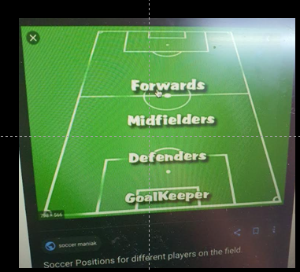

```python
#Lets first see, how many different positions we have
players.position.unique()
```

```
array(['LW', 'AM', 'GK', 'RW', 'CB', 'RB', 'CF', 'LB', 'DM', 'RM', 'CM',
       nan, 'SS', 'LM'], dtype=object)
```

```python
players.position.unique().size
```

```
14
```

```python
#We are interested in defenders
#Defender Codes are : LB , CB , RB
```

```python
players.position.isin(['LB' , 'CB' , 'RB'])
```

```
0      False
1      False
2      False
3      False
4       True
       ...
460    False
461     True
462     True
463    False
464    False
Name: position, Length: 465, dtype: bool
```

```python
players.loc[players.position.isin(['LB' , 'CB' , 'RB'])]
```

|  | name | club | age | position | position_cat | market_value | page_views | fpl_value | fpl_sel | fpl_points | region | nationality | new_foreign | age_cat | club_id | big_club | new_signing |
| --- | --- | --- | --- | --- | --- | --- | --- | --- | --- | --- | --- | --- | --- | --- | --- | --- | --- |
| 4 | Laurent Koscielny | Arsenal | 31 | CB | 3 | 22.0 | 912 | 6.0 | 0.70% | 121 | 2 | France | 0 | 4 | 1 | 1 | 0 |
| 5 | Hector Bellerin | Arsenal | 22 | RB | 3 | 30.0 | 1675 | 6.0 | 13.70% | 119 | 2 | Spain | 0 | 2 | 1 | 1 | 0 |
| 7 | Nacho Monreal | Arsenal | 31 | LB | 3 | 13.0 | 555 | 5.5 | 4.70% | 115 | 2 | Spain | 0 | 4 | 1 | 1 | 0 |
| 8 | Shkodran Mustafi | Arsenal | 25 | CB | 3 | 30.0 | 1877 | 5.5 | 4.00% | 90 | 2 | Germany | 0 | 3 | 1 | 1 | 1 |
| 17 | Gabriel Paulista | Arsenal | 26 | CB | 3 | 13.0 | 552 | 5.0 | 0.10% | 45 | 3 | Brazil | 0 | 3 | 1 | 1 | 0 |
| ... | ... | ... | ... | ... | ... | ... | ... | ... | ... | ... | ... | ... | ... | ... | ... | ... | ... |
| 455 | Aaron Cresswell | West+Ham | 27 | LB | 3 | 12.0 | 380 | 5.0 | 1.30% | 60 | 1 | England | 0 | 3 | 20 | 0 | 0 |
| 458 | Angelo Ogbonna | West+Ham | 29 | CB | 3 | 9.0 | 247 | 4.5 | 1.10% | 45 | 2 | Italy | 0 | 4 | 20 | 0 | 0 |
| 459 | Pablo Zabaleta | West+Ham | 32 | RB | 3 | 7.0 | 698 | 5.0 | 2.70% | 45 | 3 | Argentina | 0 | 5 | 20 | 0 | 0 |
| 461 | Arthur Masuaku | West+Ham | 23 | LB | 3 | 7.0 | 199 | 4.5 | 0.20% | 34 | 4 | Congo DR | 0 | 2 | 20 | 0 | 1 |
| 462 | Sam Byram | West+Ham | 23 | RB | 3 | 4.5 | 198 | 4.5 | 0.30% | 29 | 1 | England | 0 | 2 | 20 | 0 | 0 |

154 rows × 17 columns

```python
players.loc[players.position.isin(['LB' , 'CB' , 'RB'])].shape
```

```
(154, 17)
```

So, above we were looking to express a membership condition, like as we checked above , a player's position is contained in a "Collection" of values.

### RANGE

- what if we are interested in a range of values

```python
#inclusive = False : Meaning : All Market values between 40 and 50  but not including 40 and 50
players.market_value.between(40 , 50 , inclusive = False)
```

```
0      False
1      False
2      False
3      False
4      False
       ...
460    False
461    False
462    False
463    False
464    False
Name: market_value, Length: 465, dtype: bool
```

```python
players[players.market_value.between(40 , 50 , inclusive = False)]
```

|  | name | club | age | position | position_cat | market_value | page_views | fpl_value | fpl_sel | fpl_points | region | nationality | new_foreign | age_cat | club_id | big_club | new_signing |
| --- | --- | --- | --- | --- | --- | --- | --- | --- | --- | --- | --- | --- | --- | --- | --- | --- | --- |
| 218 | Philippe Coutinho | Liverpool | 25 | AM | 1 | 45.0 | 2958 | 9.0 | 30.80% | 171 | 3 | Brazil | 0 | 3 | 10 | 1 | 0 |
| 246 | Raheem Sterling | Manchester+City | 22 | LW | 1 | 45.0 | 2074 | 8.0 | 3.80% | 149 | 1 | England | 0 | 2 | 11 | 1 | 0 |
| 380 | Dele Alli | Tottenham | 21 | CM | 2 | 45.0 | 4626 | 9.5 | 38.60% | 225 | 1 | England | 0 | 1 | 17 | 1 | 0 |

- There are only 3 players

```python
players[players.market_value.between(40 , 50 , inclusive = True)]
```

|  | name | club | age | position | position_cat | market_value | page_views | fpl_value | fpl_sel | fpl_points | region | nationality | new_foreign | age_cat | club_id | big_club | new_signing |
| --- | --- | --- | --- | --- | --- | --- | --- | --- | --- | --- | --- | --- | --- | --- | --- | --- | --- |
| 1 | Mesut Ozil | Arsenal | 28 | AM | 1 | 50.0 | 4395 | 9.5 | 5.60% | 167 | 2 | Germany | 0 | 4 | 1 | 1 | 0 |
| 31 | Alexandre Lacazette | Arsenal | 26 | CF | 1 | 40.0 | 1183 | 10.5 | 26.50% | 0 | 2 | France | 1 | 3 | 1 | 1 | 0 |
| 97 | Diego Costa | Chelsea | 28 | CF | 1 | 50.0 | 4454 | 10.0 | 3.00% | 196 | 2 | Spain | 0 | 4 | 5 | 1 | 0 |
| 102 | Thibaut Courtois | Chelsea | 25 | GK | 4 | 40.0 | 1260 | 5.5 | 18.50% | 141 | 2 | Belgium | 0 | 3 | 5 | 1 | 0 |
| 108 | N%27Golo Kante | Chelsea | 26 | DM | 2 | 50.0 | 4042 | 5.0 | 13.80% | 83 | 2 | France | 0 | 3 | 5 | 1 | 1 |
| 218 | Philippe Coutinho | Liverpool | 25 | AM | 1 | 45.0 | 2958 | 9.0 | 30.80% | 171 | 3 | Brazil | 0 | 3 | 10 | 1 | 0 |
| 219 | Sadio Mane | Liverpool | 25 | LW | 1 | 40.0 | 3219 | 9.5 | 5.30% | 156 | 4 | Senegal | 0 | 3 | 10 | 1 | 1 |
| 246 | Raheem Sterling | Manchester+City | 22 | LW | 1 | 45.0 | 2074 | 8.0 | 3.80% | 149 | 1 | England | 0 | 2 | 11 | 1 | 0 |
| 263 | Bernardo Silva | Manchester+City | 22 | RW | 1 | 40.0 | 1098 | 8.0 | 4.60% | 0 | 2 | Portugal | 1 | 2 | 11 | 1 | 0 |
| 264 | Romelu Lukaku | Manchester+United | 24 | CF | 1 | 50.0 | 3727 | 11.5 | 45.00% | 221 | 2 | Belgium | 0 | 2 | 12 | 1 | 0 |
| 265 | David de Gea | Manchester+United | 26 | GK | 4 | 40.0 | 2126 | 5.5 | 26.10% | 136 | 2 | Spain | 0 | 3 | 12 | 1 | 0 |
| 380 | Dele Alli | Tottenham | 21 | CM | 2 | 45.0 | 4626 | 9.5 | 38.60% | 225 | 1 | England | 0 | 1 | 17 | 1 | 0 |
| 382 | Christian Eriksen | Tottenham | 25 | AM | 1 | 40.0 | 1130 | 9.5 | 12.00% | 218 | 2 | Denmark | 0 | 3 | 17 | 1 | 0 |

### Comparison Operators

```python
players.age <= 25
```

```
0      False
1      False
2      False
3      False
4      False
       ...
460     True
461     True
462     True
463     True
464    False
Name: age, Length: 465, dtype: bool
```

```python
players[players.age <= 25]
```

|  | name | club | age | position | position_cat | market_value | page_views | fpl_value | fpl_sel | fpl_points | region | nationality | new_foreign | age_cat | club_id | big_club | new_signing |
| --- | --- | --- | --- | --- | --- | --- | --- | --- | --- | --- | --- | --- | --- | --- | --- | --- | --- |
| 5 | Hector Bellerin | Arsenal | 22 | RB | 3 | 30.0 | 1675 | 6.0 | 13.70% | 119 | 2 | Spain | 0 | 2 | 1 | 1 | 0 |
| 8 | Shkodran Mustafi | Arsenal | 25 | CB | 3 | 30.0 | 1877 | 5.5 | 4.00% | 90 | 2 | Germany | 0 | 3 | 1 | 1 | 1 |
| 9 | Alex Iwobi | Arsenal | 21 | LW | 1 | 10.0 | 1812 | 5.5 | 1.00% | 89 | 4 | Nigeria | 0 | 1 | 1 | 1 | 0 |
| 10 | Granit Xhaka | Arsenal | 24 | DM | 2 | 35.0 | 1815 | 5.5 | 2.00% | 85 | 2 | Switzerland | 0 | 2 | 1 | 1 | 0 |
| 11 | Granit Xhaka | Arsenal | 24 | DM | 2 | 35.0 | 1815 | 5.5 | 2.00% | 85 | 2 | Switzerland | 0 | 2 | 1 | 1 | 0 |
| ... | ... | ... | ... | ... | ... | ... | ... | ... | ... | ... | ... | ... | ... | ... | ... | ... | ... |
| 456 | Pedro Obiang | West+Ham | 25 | CM | 2 | 9.0 | 286 | 4.5 | 0.30% | 55 | 2 | Spain | 0 | 3 | 20 | 0 | 0 |
| 460 | Edimilson Fernandes | West+Ham | 21 | CM | 2 | 5.0 | 288 | 4.5 | 0.40% | 38 | 2 | Switzerland | 0 | 1 | 20 | 0 | 1 |
| 461 | Arthur Masuaku | West+Ham | 23 | LB | 3 | 7.0 | 199 | 4.5 | 0.20% | 34 | 4 | Congo DR | 0 | 2 | 20 | 0 | 1 |
| 462 | Sam Byram | West+Ham | 23 | RB | 3 | 4.5 | 198 | 4.5 | 0.30% | 29 | 1 | England | 0 | 2 | 20 | 0 | 0 |
| 463 | Ashley Fletcher | West+Ham | 21 | CF | 1 | 1.0 | 412 | 4.5 | 5.90% | 16 | 1 | England | 0 | 1 | 20 | 0 | 1 |

172 rows × 17 columns

```python
#less than 25
players[players.age.le(25)]
```

|  | name | club | age | position | position_cat | market_value | page_views | fpl_value | fpl_sel | fpl_points | region | nationality | new_foreign | age_cat | club_id | big_club | new_signing |
| --- | --- | --- | --- | --- | --- | --- | --- | --- | --- | --- | --- | --- | --- | --- | --- | --- | --- |
| 5 | Hector Bellerin | Arsenal | 22 | RB | 3 | 30.0 | 1675 | 6.0 | 13.70% | 119 | 2 | Spain | 0 | 2 | 1 | 1 | 0 |
| 8 | Shkodran Mustafi | Arsenal | 25 | CB | 3 | 30.0 | 1877 | 5.5 | 4.00% | 90 | 2 | Germany | 0 | 3 | 1 | 1 | 1 |
| 9 | Alex Iwobi | Arsenal | 21 | LW | 1 | 10.0 | 1812 | 5.5 | 1.00% | 89 | 4 | Nigeria | 0 | 1 | 1 | 1 | 0 |
| 10 | Granit Xhaka | Arsenal | 24 | DM | 2 | 35.0 | 1815 | 5.5 | 2.00% | 85 | 2 | Switzerland | 0 | 2 | 1 | 1 | 0 |
| 11 | Granit Xhaka | Arsenal | 24 | DM | 2 | 35.0 | 1815 | 5.5 | 2.00% | 85 | 2 | Switzerland | 0 | 2 | 1 | 1 | 0 |
| ... | ... | ... | ... | ... | ... | ... | ... | ... | ... | ... | ... | ... | ... | ... | ... | ... | ... |
| 456 | Pedro Obiang | West+Ham | 25 | CM | 2 | 9.0 | 286 | 4.5 | 0.30% | 55 | 2 | Spain | 0 | 3 | 20 | 0 | 0 |
| 460 | Edimilson Fernandes | West+Ham | 21 | CM | 2 | 5.0 | 288 | 4.5 | 0.40% | 38 | 2 | Switzerland | 0 | 1 | 20 | 0 | 1 |
| 461 | Arthur Masuaku | West+Ham | 23 | LB | 3 | 7.0 | 199 | 4.5 | 0.20% | 34 | 4 | Congo DR | 0 | 2 | 20 | 0 | 1 |
| 462 | Sam Byram | West+Ham | 23 | RB | 3 | 4.5 | 198 | 4.5 | 0.30% | 29 | 1 | England | 0 | 2 | 20 | 0 | 0 |
| 463 | Ashley Fletcher | West+Ham | 21 | CF | 1 | 1.0 | 412 | 4.5 | 5.90% | 16 | 1 | England | 0 | 1 | 20 | 0 | 1 |

172 rows × 17 columns

```python
#Lets compare booth the boolean masks
(players.age <= 25).equals (players.age.le(25))
```

```
True
```

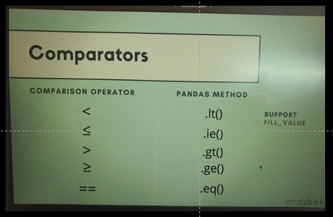

- The only difference is , "Pandas Method" supports "fill_value" , meaning , if any NA is found we can replace it with a number.

### Binary Operators with Booleans

https://www.udemy.com/course/the-ultimate-pandas-bootcamp-advanced-python-data-analysis/learn/lecture/18839288#overview

Binary : OR operator " | "

```python
True | False   #True OR False
```

```
True
```

```python
False | False
```

```
False
```

```python
False | True
```

```
True
```

```python
True | True
```

```
True
```

- think of the "OR" operator as searching for True

### Binary : AND operator " & "

```python
True & False
```

```
False
```

```python
False & True
```

```
False
```

```python
False & False
```

```
False
```

```python
True & True
```

```
True
```

The way to think about the "AND" operator is - Always True unless there is a FALSE

- A single False is enough to trigger a False

```python
True & True &  True &  False &  True
```

```
False
```

```python
#creating a single element series with a Single False value
f = pd.Series(False)
```

```python
f
```

```
0    False
dtype: bool
```

```python
t = pd.Series(True)
```

```python
t
```

```
0    True
dtype: bool
```

```python
#Lets combine them using a Binary operator
t & f
```

```
0    False
dtype: bool
```

```python
t | f
```

```
0    True
dtype: bool
```

```python
#Lets convert these Series to longer ranges of Booleans
#For every even position item , it should be True otherwise False
t = pd.Series([True if i%2 == 0 else False for i in range(10)])
```

```python
t
```

```
0     True
1    False
2     True
3    False
4     True
5    False
6     True
7    False
8     True
9    False
dtype: bool
```

```python
f = pd.Series([False for i in range(10)])
```

```python
f
```

```
0    False
1    False
2    False
3    False
4    False
5    False
6    False
7    False
8    False
9    False
dtype: bool
```

```python
#Lets see what happens when we combine t and f series
t & f
```

```
0    False
1    False
2    False
3    False
4    False
5    False
6    False
7    False
8    False
9    False
dtype: bool
```

Important thing to note here is : when we combine two Pandas Series the comparison is done Label to Label not based on the order

```python
#Lets create a Series with Index Labels
f = pd.Series(data= [ False , True , True] , index = ['c' , 'b' , 'a'])
```

```python
f
```

```
c    False
b     True
a     True
dtype: object
```

```python
t = pd.Series(data = [True , False , False] , index = ['a' , 'b' , 'c'])
```

```python
t
```

```
a     True
b    False
c    False
dtype: object
```

So, when we say "f & t" we are technically expecting three False:

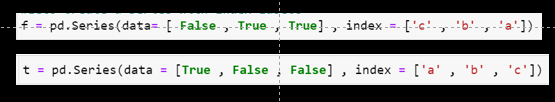

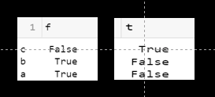

```python
#But we end up getting two False
f & t
```

```
a     True
b    False
c    False
dtype: bool
```

```python
t & f
```

```
a     True
b    False
c    False
dtype: bool
```

- The order of the elements is not important here , what is important is the LABEL that these boolean values are associated with.
- (t) Label a : (f) Label a
- (t) Label b : (f) Label b
- (t) Label c : (f) Label c

So, remember , whenever combining Series the comparison happens by Label , not based on the order

### XOR and Complement Binary Ops

Binary XOR stands for Exclusive OR : How is it different from the regular OR ?

- Its True only when the inputs are different and False when they are alike or similar
- The XOR Binary operator is represented using the ^ (Carat) symbol

```python
#This is True because inputs are different
True ^ False
```

```
True
```

```python
True ^ True
```

```
False
```

```python
False ^ True
```

```
True
```

```python
False ^ False
```

```
False
```

### Binary Two's Operator , represented using "~" Tilde

In pandas and Numpy , you will find it extremely useful when negating the Boolean Mask.

- In other words finding the Opposite of Boolean Series

```python
~True
```

```
-2
```

```python
~False
```

```
-1
```

This has to do with how computers represent integers

### Indexing using Multiple Conditions

#### Combining Conditions

```python
players.position.head()
```

```
0    LW
1    AM
2    GK
3    RW
4    CB
Name: position, dtype: object
```

#### We want to look at all Left Back Players - LB

```python
#To select all such players we will create a series of Booleans
players.position == 'LB'
```

```
0      False
1      False
2      False
3      False
4      False
       ...
460    False
461     True
462    False
463    False
464    False
Name: position, Length: 465, dtype: bool
```

```python
players[players.position == 'LB'].head(2)
```

|  | name | club | age | position | position_cat | market_value | page_views | fpl_value | fpl_sel | fpl_points | region | nationality | new_foreign | age_cat | club_id | big_club | new_signing |
| --- | --- | --- | --- | --- | --- | --- | --- | --- | --- | --- | --- | --- | --- | --- | --- | --- | --- |
| 7 | Nacho Monreal | Arsenal | 31 | LB | 3 | 13.0 | 555 | 5.5 | 4.70% | 115 | 2 | Spain | 0 | 4 | 1 | 1 | 0 |
| 18 | Kieran Gibbs | Arsenal | 27 | LB | 3 | 10.0 | 489 | 5.0 | 0.50% | 45 | 1 | England | 0 | 3 | 1 | 1 | 0 |

### Select all Left Backs who are 25 or Younger

```python
#Passing multiple conditions
players[(players.position == 'LB') & (players.age <= 25)] .head(3)
```

|  | name | club | age | position | position_cat | market_value | page_views | fpl_value | fpl_sel | fpl_points | region | nationality | new_foreign | age_cat | club_id | big_club | new_signing |
| --- | --- | --- | --- | --- | --- | --- | --- | --- | --- | --- | --- | --- | --- | --- | --- | --- | --- |
| 29 | Sead Kolasinac | Arsenal | 24 | LB | 3 | 15.0 | 618 | 6.0 | 6.90% | 0 | 2 | Bosnia | 1 | 2 | 1 | 1 | 0 |
| 54 | Brad Smith | Bournemouth | 23 | LB | 3 | 2.0 | 297 | 4.0 | 3.30% | 4 | 4 | Australia | 0 | 2 | 2 | 0 | 0 |
| 112 | Kenedy | Chelsea | 21 | LB | 3 | 7.0 | 566 | 5.0 | 0.10% | 3 | 3 | Brazil | 0 | 1 | 5 | 1 | 0 |

```python
#3 conditions : Left backs , 25 or younger , Market Value 10+
```

```python
players[(players.position == 'LB') & (players.age <= 25) & (players.market_value >= 10)]
```

|  | name | club | age | position | position_cat | market_value | page_views | fpl_value | fpl_sel | fpl_points | region | nationality | new_foreign | age_cat | club_id | big_club | new_signing |
| --- | --- | --- | --- | --- | --- | --- | --- | --- | --- | --- | --- | --- | --- | --- | --- | --- | --- |
| 29 | Sead Kolasinac | Arsenal | 24 | LB | 3 | 15.0 | 618 | 6.0 | 6.90% | 0 | 2 | Bosnia | 1 | 2 | 1 | 1 | 0 |
| 236 | Alberto Moreno | Liverpool | 25 | LB | 3 | 10.0 | 397 | 4.5 | 0.30% | 8 | 2 | Spain | 0 | 3 | 10 | 1 | 0 |
| 281 | Luke Shaw | Manchester+United | 22 | LB | 3 | 20.0 | 947 | 5.0 | 0.40% | 45 | 1 | England | 0 | 2 | 12 | 1 | 0 |
| 389 | Ben Davies | Tottenham | 24 | LB | 3 | 12.0 | 396 | 5.5 | 1.80% | 90 | 2 | Wales | 0 | 2 | 17 | 1 | 0 |

```python
#4 conditions : Left backs , 25 or younger , Market Value 10+ and not from Arsenal or Tottenham clubs
```

```python
players[(players.position == 'LB') &
        (players.age <= 25) &
        (players.market_value >= 10) &
        ~(players.club.isin(['Tottenham' , 'Arsenal']))
       ]
```

|  | name | club | age | position | position_cat | market_value | page_views | fpl_value | fpl_sel | fpl_points | region | nationality | new_foreign | age_cat | club_id | big_club | new_signing |
| --- | --- | --- | --- | --- | --- | --- | --- | --- | --- | --- | --- | --- | --- | --- | --- | --- | --- |
| 236 | Alberto Moreno | Liverpool | 25 | LB | 3 | 10.0 | 397 | 4.5 | 0.30% | 8 | 2 | Spain | 0 | 3 | 10 | 1 | 0 |
| 281 | Luke Shaw | Manchester+United | 22 | LB | 3 | 20.0 | 947 | 5.0 | 0.40% | 45 | 1 | England | 0 | 2 | 12 | 1 | 0 |

### Conditions as Variables

```python
#new target : Arsenal right backs and Chelsea Goalkeepers
aresenal_player = players.club == 'Arsenal'
```

```python
right_back = players.position == 'RB'
```

```python
chelsea_and_GK = (players.club == 'Chelsea') & (players.position == 'GK')
```

```python
#aresenal_player : CLUB : Arsenal & right_back : POSITION : RB | chelsea_and_GK CLUB : Chelsea  & POSITION GK
```

OR Operator = If any of the two conditions match give the output

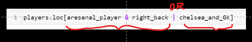

```python
players.loc[aresenal_player & right_back | chelsea_and_GK]
```

|  | name | club | age | position | position_cat | market_value | page_views | fpl_value | fpl_sel | fpl_points | region | nationality | new_foreign | age_cat | club_id | big_club | new_signing |
| --- | --- | --- | --- | --- | --- | --- | --- | --- | --- | --- | --- | --- | --- | --- | --- | --- | --- |
| 5 | Hector Bellerin | Arsenal | 22 | RB | 3 | 30.0 | 1675 | 6.0 | 13.70% | 119 | 2 | Spain | 0 | 2 | 1 | 1 | 0 |
| 27 | Carl Jenkinson | Arsenal | 25 | RB | 3 | 5.0 | 561 | 4.5 | 0.40% | 2 | 1 | England | 0 | 3 | 1 | 1 | 0 |
| 102 | Thibaut Courtois | Chelsea | 25 | GK | 4 | 40.0 | 1260 | 5.5 | 18.50% | 141 | 2 | Belgium | 0 | 3 | 5 | 1 | 0 |
| 109 | Willy Caballero | Chelsea | 35 | GK | 4 | 1.5 | 542 | 5.0 | 0.20% | 64 | 3 | Argentina | 0 | 6 | 5 | 1 | 0 |

AND = If all the conditions match then give the Output

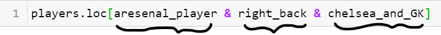

```python
players.loc[aresenal_player & right_back & chelsea_and_GK]
```

|  | name | club | age | position | position_cat | market_value | page_views | fpl_value | fpl_sel | fpl_points | region | nationality | new_foreign | age_cat | club_id | big_club | new_signing |
| --- | --- | --- | --- | --- | --- | --- | --- | --- | --- | --- | --- | --- | --- | --- | --- | --- | --- |

### Skill Challenge

#### Find the players in the Dataset that meet this Criteria

1. They are English nationality (nationality) and
2. Their Market value is more than twice the Average Market value in the League (market_value) and
3. They either have more than 4000 views (page_views) or are a new signing (new_signing) but not both

```python
players.head(2)
```

|  | name | club | age | position | position_cat | market_value | page_views | fpl_value | fpl_sel | fpl_points | region | nationality | new_foreign | age_cat | club_id | big_club | new_signing |
| --- | --- | --- | --- | --- | --- | --- | --- | --- | --- | --- | --- | --- | --- | --- | --- | --- | --- |
| 0 | Alexis Sanchez | Arsenal | 28 | LW | 1 | 65.0 | 4329 | 12.0 | 17.10% | 264 | 3 | Chile | 0 | 4 | 1 | 1 | 0 |
| 1 | Mesut Ozil | Arsenal | 28 | AM | 1 | 50.0 | 4395 | 9.5 | 5.60% | 167 | 2 | Germany | 0 | 4 | 1 | 1 | 0 |

```python
Eng_nationality = players.nationality == 'England'
```

```python
MV_twice = players.market_value > players.market_value.mean() * 2
```

```python
players.market_value.mean() * 2
```

```
22.251298701298698
```

```python
old_new = (players.page_views > 4000) | (players.new_signing == 1)
```

```python
players[old_new].head(5)
```

|  | name | club | age | position | position_cat | market_value | page_views | fpl_value | fpl_sel | fpl_points | region | nationality | new_foreign | age_cat | club_id | big_club | new_signing |
| --- | --- | --- | --- | --- | --- | --- | --- | --- | --- | --- | --- | --- | --- | --- | --- | --- | --- |
| 0 | Alexis Sanchez | Arsenal | 28 | LW | 1 | 65.0 | 4329 | 12.0 | 17.10% | 264 | 3 | Chile | 0 | 4 | 1 | 1 | 0 |
| 1 | Mesut Ozil | Arsenal | 28 | AM | 1 | 50.0 | 4395 | 9.5 | 5.60% | 167 | 2 | Germany | 0 | 4 | 1 | 1 | 0 |
| 8 | Shkodran Mustafi | Arsenal | 25 | CB | 3 | 30.0 | 1877 | 5.5 | 4.00% | 90 | 2 | Germany | 0 | 3 | 1 | 1 | 1 |
| 21 | Rob Holding | Arsenal | 21 | CB | 3 | 7.0 | 666 | 5.0 | 1.70% | 32 | 1 | England | 0 | 1 | 1 | 1 | 1 |
| 24 | Lucas Perez | Arsenal | 28 | CF | 1 | 15.0 | 2055 | 7.5 | 0.10% | 20 | 2 | Spain | 0 | 4 | 1 | 1 | 1 |

```python
players[Eng_nationality & MV_twice &  old_new]
```

|  | name | club | age | position | position_cat | market_value | page_views | fpl_value | fpl_sel | fpl_points | region | nationality | new_foreign | age_cat | club_id | big_club | new_signing |
| --- | --- | --- | --- | --- | --- | --- | --- | --- | --- | --- | --- | --- | --- | --- | --- | --- | --- |
| 256 | John Stones | Manchester+City | 23 | CB | 3 | 35.0 | 1078 | 5.5 | 2.30% | 59 | 1 | England | 0 | 2 | 11 | 1 | 1 |
| 380 | Dele Alli | Tottenham | 21 | CM | 2 | 45.0 | 4626 | 9.5 | 38.60% | 225 | 1 | England | 0 | 1 | 17 | 1 | 0 |
| 381 | Harry Kane | Tottenham | 23 | CF | 1 | 60.0 | 4161 | 12.5 | 35.10% | 224 | 1 | England | 0 | 2 | 17 | 1 | 0 |

### Indexing

```python
#Chelsea players and 23 years old or younger
```

```python
chelsea_23under = (players.club == 'Chelsea') & (players.age <= 23)
```

```python
chelsea_23under
```

```
0      False
1      False
2      False
3      False
4      False
       ...
460    False
461    False
462    False
463    False
464    False
Length: 465, dtype: bool
```

```python
players.loc[chelsea_23under]
```

|  | name | club | age | position | position_cat | market_value | page_views | fpl_value | fpl_sel | fpl_points | region | nationality | new_foreign | age_cat | club_id | big_club | new_signing |
| --- | --- | --- | --- | --- | --- | --- | --- | --- | --- | --- | --- | --- | --- | --- | --- | --- | --- |
| 110 | Michy Batshuayi | Chelsea | 23 | CF | 1 | 25.0 | 1162 | 8.5 | 1.60% | 48 | 2 | Belgium | 0 | 2 | 5 | 1 | 1 |
| 111 | Kurt Zouma | Chelsea | 22 | CB | 3 | 15.0 | 723 | 5.5 | 0.80% | 15 | 2 | France | 0 | 2 | 5 | 1 | 0 |
| 112 | Kenedy | Chelsea | 21 | LB | 3 | 7.0 | 566 | 5.0 | 0.10% | 3 | 3 | Brazil | 0 | 1 | 5 | 1 | 0 |
| 115 | Tiemoue Bakayoko | Chelsea | 22 | DM | 2 | 16.0 | 1011 | 5.0 | 1.60% | 0 | 2 | France | 1 | 2 | 5 | 1 | 0 |

```python
#We only want to see these two columns
players.loc[chelsea_23under , ['position' , 'market_value']]
```

|  | position | market_value |
| --- | --- | --- |
| 110 | CF | 25.0 |
| 111 | CB | 15.0 |
| 112 | LB | 7.0 |
| 115 | DM | 16.0 |

- But this is not really a convenient way of doing this

```python
#Select all columns that begin with small "p"
```

```python
#We use startswith()
```

```python
players.columns
```

```
Index(['name', 'club', 'age', 'position', 'position_cat', 'market_value',
       'page_views', 'fpl_value', 'fpl_sel', 'fpl_points', 'region',
       'nationality', 'new_foreign', 'age_cat', 'club_id', 'big_club',
       'new_signing'],
      dtype='object')
```

```python
#We got a list of Booleans
players.columns.str.startswith('p')
```

```
array([False, False, False,  True,  True, False,  True, False, False,
       False, False, False, False, False, False, False, False])
```

```python
pcols = players.columns.str.startswith('p')
```

```python
#Now we can just pass "pcols" to the Boolean Indexer
#Club : chelsea , Age: under 23
players.loc[chelsea_23under , pcols]
```

|  | position | position_cat | page_views |
| --- | --- | --- | --- |
| 110 | CF | 1 | 1162 |
| 111 | CB | 3 | 723 |
| 112 | LB | 3 | 566 |
| 115 | DM | 2 | 1011 |

To do DataFrame Selection along the Index Axis , the length of our Boolean Series needs to be the same as the length of the Index iteself.

#### There is an alternative way of indexing along the columns , that is to, Chain two square brackets

### [ ] Chaining

```python
#Chelsea players and 23 years old or younger
chelsea_23under = (players.club == 'Chelsea') & (players.age <= 23)
```

```python
players[chelsea_23under]
```

|  | name | club | age | position | position_cat | market_value | page_views | fpl_value | fpl_sel | fpl_points | region | nationality | new_foreign | age_cat | club_id | big_club | new_signing |
| --- | --- | --- | --- | --- | --- | --- | --- | --- | --- | --- | --- | --- | --- | --- | --- | --- | --- |
| 110 | Michy Batshuayi | Chelsea | 23 | CF | 1 | 25.0 | 1162 | 8.5 | 1.60% | 48 | 2 | Belgium | 0 | 2 | 5 | 1 | 1 |
| 111 | Kurt Zouma | Chelsea | 22 | CB | 3 | 15.0 | 723 | 5.5 | 0.80% | 15 | 2 | France | 0 | 2 | 5 | 1 | 0 |
| 112 | Kenedy | Chelsea | 21 | LB | 3 | 7.0 | 566 | 5.0 | 0.10% | 3 | 3 | Brazil | 0 | 1 | 5 | 1 | 0 |
| 115 | Tiemoue Bakayoko | Chelsea | 22 | DM | 2 | 16.0 | 1011 | 5.0 | 1.60% | 0 | 2 | France | 1 | 2 | 5 | 1 | 0 |

- We got a Slice of the DataFrame
- Now we can extend the square brackets
- Right next to it we can chain on a second Square bracket and say , give me just 'position'

```python
#Looking at only one column
players[chelsea_23under]['position']
```

```
110    CF
111    CB
112    LB
115    DM
Name: position, dtype: object
```

- The same can be done using "players.loc[chelsea_23under , 'position']"
- The below method is faster than the above

```python
players.loc[chelsea_23under , 'position']
```

```
110    CF
111    CB
112    LB
115    DM
Name: position, dtype: object
```

### Fancy Indexing with Lookup

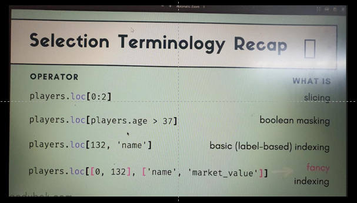

```python
#players.loc[0 : 2] => Slicing
#players.loc[players.age > 37] => boolean masking
#players.loc[132 , 'name']  => basic(label-based) Indexing
#players.loc[[0,132],['name' , 'market_value']] => Fancy Indexing
```

### Fancy Indexing Item Selection : lookup() is another way to fancy Indexing

The method is called "lookup()"

- It take a specific "Row label" and a specific "Column Label" , then it returns the value associated with each pair of labels

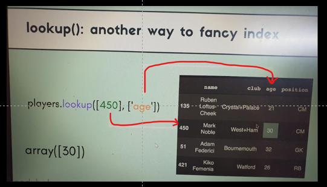

```python
#We have here traditional label based selection using the .loc indexer with some fancy indexing
#We are passing a list of index labels as well as a Tuple of column labels
players.loc[[0, 132] , ('name' , 'market_value')] #fancy
```

|  | name | market_value |
| --- | --- | --- |
| 0 | Alexis Sanchez | 65.0 |
| 132 | Connor Wickham | 6.0 |

```python
players.iloc[[0, 132] , [0 , 5]]
```

|  | name | market_value |
| --- | --- | --- |
| 0 | Alexis Sanchez | 65.0 |
| 132 | Connor Wickham | 6.0 |

```python
#Lets compare this with the Lookup method
```

```python
players.lookup([0 , 132] , ['name' , 'market_value'])
```

```
array(['Alexis Sanchez', 6.0], dtype=object)
```

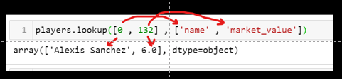

### Another Example :

The lookup() function returns label-based "fancy indexing" function for DataFrame. Given equal-length arrays of row and column labels, return an array of the values corresponding to each (row, col) pair.

```python
players.set_index('name').head(3)
```

| name | club | age | position | position_cat | market_value | page_views | fpl_value | fpl_sel | fpl_points | region | nationality | new_foreign | age_cat | club_id | big_club | new_signing |
| --- | --- | --- | --- | --- | --- | --- | --- | --- | --- | --- | --- | --- | --- | --- | --- | --- |
| Alexis Sanchez | Arsenal | 28 | LW | 1 | 65.0 | 4329 | 12.0 | 17.10% | 264 | 3 | Chile | 0 | 4 | 1 | 1 | 0 |
| Mesut Ozil | Arsenal | 28 | AM | 1 | 50.0 | 4395 | 9.5 | 5.60% | 167 | 2 | Germany | 0 | 4 | 1 | 1 | 0 |
| Petr Cech | Arsenal | 35 | GK | 4 | 7.0 | 1529 | 5.5 | 5.90% | 134 | 2 | Czech Republic | 0 | 6 | 1 | 1 | 0 |

```python
#List of Index Labels
names = ['Petr Cech' , 'Mesut Ozil' , 'Alexis Sanchez']
```

```python
#List of Column Labels
attributes = ['age' , 'market_value' , 'page_views']
```

```python
#Lets say we are interested in getting :
#'Petr Cech' ==> 'age'
#'Mesut Ozil' ==> 'market_value'
#'Alexis Sanchez' ==> 'page_views'
```

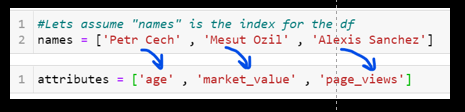

```python
#We can set the index on the fly instead of doing it in place
players.set_index('name').lookup(names , attributes)
```

```
array([  35.,   50., 4329.])
```

lookup() gives us the flexibility to select precise values in a DataFrame using a collection of Row and column labels.

- Kind of like hunting down values using their Label coordinates.

### Just for Info:

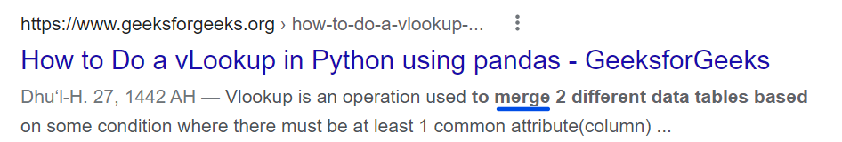

### Sorting by Index or Column

```python
players.head()
```

|  | name | club | age | position | position_cat | market_value | page_views | fpl_value | fpl_sel | fpl_points | region | nationality | new_foreign | age_cat | club_id | big_club | new_signing |
| --- | --- | --- | --- | --- | --- | --- | --- | --- | --- | --- | --- | --- | --- | --- | --- | --- | --- |
| 0 | Alexis Sanchez | Arsenal | 28 | LW | 1 | 65.0 | 4329 | 12.0 | 17.10% | 264 | 3 | Chile | 0 | 4 | 1 | 1 | 0 |
| 1 | Mesut Ozil | Arsenal | 28 | AM | 1 | 50.0 | 4395 | 9.5 | 5.60% | 167 | 2 | Germany | 0 | 4 | 1 | 1 | 0 |
| 2 | Petr Cech | Arsenal | 35 | GK | 4 | 7.0 | 1529 | 5.5 | 5.90% | 134 | 2 | Czech Republic | 0 | 6 | 1 | 1 | 0 |
| 3 | Theo Walcott | Arsenal | 28 | RW | 1 | 20.0 | 2393 | 7.5 | 1.50% | 122 | 1 | England | 0 | 4 | 1 | 1 | 0 |
| 4 | Laurent Koscielny | Arsenal | 31 | CB | 3 | 22.0 | 912 | 6.0 | 0.70% | 121 | 2 | France | 0 | 4 | 1 | 1 | 0 |

#### If we want to sort the Players by their Market value in Descending order:

```python
#for Series
players.market_value.sort_values(ascending = False)
```

```
96     75.00
267    75.00
0      65.00
245    65.00
244    65.00
       ...
287     0.10
113     0.05
30       NaN
192      NaN
195      NaN
Name: market_value, Length: 465, dtype: float64
```

```python
#For returning the whole df
players.sort_values(by = 'market_value', ascending = False )
```

|  | name | club | age | position | position_cat | market_value | page_views | fpl_value | fpl_sel | fpl_points | region | nationality | new_foreign | age_cat | club_id | big_club | new_signing |
| --- | --- | --- | --- | --- | --- | --- | --- | --- | --- | --- | --- | --- | --- | --- | --- | --- | --- |
| 96 | Eden Hazard | Chelsea | 26 | LW | 1 | 75.00 | 4220 | 10.5 | 2.30% | 224 | 2 | Belgium | 0 | 3 | 5 | 1 | 0 |
| 267 | Paul Pogba | Manchester+United | 24 | CM | 2 | 75.00 | 7435 | 8.0 | 19.50% | 115 | 2 | France | 0 | 2 | 12 | 1 | 1 |
| 0 | Alexis Sanchez | Arsenal | 28 | LW | 1 | 65.00 | 4329 | 12.0 | 17.10% | 264 | 3 | Chile | 0 | 4 | 1 | 1 | 0 |
| 244 | Kevin De Bruyne | Manchester+City | 26 | AM | 1 | 65.00 | 2252 | 10.0 | 17.50% | 199 | 2 | Belgium | 0 | 3 | 11 | 1 | 0 |
| 245 | Sergio Aguero | Manchester+City | 29 | CF | 1 | 65.00 | 4046 | 11.5 | 9.70% | 175 | 3 | Argentina | 0 | 4 | 11 | 1 | 0 |
| ... | ... | ... | ... | ... | ... | ... | ... | ... | ... | ... | ... | ... | ... | ... | ... | ... | ... |
| 287 | Joel Castro Pereira | Manchester+United | 21 | GK | 4 | 0.10 | 395 | 4.0 | 1.00% | 6 | 2 | Portugal | 0 | 1 | 12 | 1 | 0 |
| 113 | Eduardo Carvalho | Chelsea | 34 | LW | 1 | 0.05 | 467 | 5.0 | 0.10% | 0 | 2 | Portugal | 0 | 6 | 5 | 1 | 1 |
| 30 | Granit Xhaka | Arsenal | 24 | NaN | 2 | NaN | 1815 | 5.5 | 2.00% | 85 | 2 | Switzerland | 0 | 2 | 1 | 1 | 0 |
| 192 | Steve Mounie | Huddersfield | 22 | CF | 1 | NaN | 56 | 6.0 | 0.60% | 0 | 2 | Benin | 0 | 2 | 8 | 0 | 0 |
| 195 | Kasper Schmeichel | Leicester+City | 30 | GK | 4 | NaN | 1601 | 5.0 | 2.40% | 109 | 2 | Denmark | 0 | 4 | 9 | 0 | 0 |

465 rows × 17 columns

```python
#But this is not the only way to SORT
#Lets say we want to sort by DataFrame Index (that we create)
#This df currently has Integer based Index
```

```python
#This index is naturally sorted
players.index
```

```
RangeIndex(start=0, stop=465, step=1)
```

```python
#We want the Player names to be the index of this df
players.set_index('name' , inplace = True)
```

```python
players.index
```

```
Index(['Alexis Sanchez', 'Mesut Ozil', 'Petr Cech', 'Theo Walcott',
       'Laurent Koscielny', 'Hector Bellerin', 'Olivier Giroud',
       'Nacho Monreal', 'Shkodran Mustafi', 'Alex Iwobi',
       ...
       'Aaron Cresswell', 'Pedro Obiang', 'Sofiane Feghouli', 'Angelo Ogbonna',
       'Pablo Zabaleta', 'Edimilson Fernandes', 'Arthur Masuaku', 'Sam Byram',
       'Ashley Fletcher', 'Diafra Sakho'],
      dtype='object', name='name', length=465)
```

```python
#But notice that the index is not ordered anymore
#A good practice while working with tabular data , specially in context of DataFrames is to always maintain an
#ordered index
```

### sort_index()

```python
players.sort_index().head(10)
```

| name | club | age | position | position_cat | market_value | page_views | fpl_value | fpl_sel | fpl_points | region | nationality | new_foreign | age_cat | club_id | big_club | new_signing |
| --- | --- | --- | --- | --- | --- | --- | --- | --- | --- | --- | --- | --- | --- | --- | --- | --- |
| Aaron Cresswell | West+Ham | 27 | LB | 3 | 12.0 | 380 | 5.0 | 1.30% | 60 | 1 | England | 0 | 3 | 20 | 0 | 0 |
| Aaron Lennon | Everton | 30 | RW | 1 | 5.0 | 504 | 5.5 | 0.20% | 22 | 1 | England | 0 | 4 | 7 | 0 | 0 |
| Aaron Mooy | Huddersfield | 26 | CM | 2 | 5.0 | 588 | 5.5 | 2.50% | 0 | 4 | Australia | 0 | 3 | 8 | 0 | 0 |
| Aaron Ramsey | Arsenal | 26 | CM | 2 | 35.0 | 1040 | 7.0 | 5.10% | 56 | 1 | Wales | 0 | 3 | 1 | 1 | 0 |
| Abdoulaye Doucoure | Watford | 24 | CM | 2 | 6.0 | 124 | 5.0 | 0.00% | 38 | 2 | France | 0 | 2 | 18 | 0 | 0 |
| Adam Federici | Bournemouth | 32 | GK | 4 | 1.0 | 126 | 4.0 | 1.50% | 8 | 4 | Australia | 0 | 5 | 2 | 0 | 0 |
| Adam Lallana | Liverpool | 29 | AM | 1 | 25.0 | 1808 | 7.5 | 6.40% | 139 | 1 | England | 0 | 4 | 10 | 1 | 0 |
| Adam Smith | Bournemouth | 26 | RB | 3 | 5.0 | 200 | 5.0 | 0.90% | 104 | 1 | England | 0 | 3 | 2 | 0 | 0 |
| Ademola Lookman | Everton | 19 | LW | 1 | 5.0 | 1387 | 5.5 | 0.30% | 16 | 1 | England | 0 | 1 | 7 | 0 | 0 |
| Adrian | West+Ham | 30 | GK | 4 | 8.0 | 266 | 4.5 | 0.80% | 64 | 2 | Spain | 0 | 4 | 20 | 0 | 0 |

```python
#set the inplace = True
players.sort_index(inplace = True)
```

```python
players.head(3)
```

| name | club | age | position | position_cat | market_value | page_views | fpl_value | fpl_sel | fpl_points | region | nationality | new_foreign | age_cat | club_id | big_club | new_signing |
| --- | --- | --- | --- | --- | --- | --- | --- | --- | --- | --- | --- | --- | --- | --- | --- | --- |
| Aaron Cresswell | West+Ham | 27 | LB | 3 | 12.0 | 380 | 5.0 | 1.30% | 60 | 1 | England | 0 | 3 | 20 | 0 | 0 |
| Aaron Lennon | Everton | 30 | RW | 1 | 5.0 | 504 | 5.5 | 0.20% | 22 | 1 | England | 0 | 4 | 7 | 0 | 0 |
| Aaron Mooy | Huddersfield | 26 | CM | 2 | 5.0 | 588 | 5.5 | 2.50% | 0 | 4 | Australia | 0 | 3 | 8 | 0 | 0 |

#### We can also sort our columns.

- Lets say we are also interested in sorting our column axis
- The only thing we need to change is the axis parameter , from its default of 0 to 1
- remember axis = 0 => rows ; axis = 1 => columns

```python
players.sort_index(axis = 1)
```

| name | age | age_cat | big_club | club | club_id | fpl_points | fpl_sel | fpl_value | market_value | nationality | new_foreign | new_signing | page_views | position | position_cat | region |
| --- | --- | --- | --- | --- | --- | --- | --- | --- | --- | --- | --- | --- | --- | --- | --- | --- |
| Aaron Cresswell | 27 | 3 | 0 | West+Ham | 20 | 60 | 1.30% | 5.0 | 12.0 | England | 0 | 0 | 380 | LB | 3 | 1 |
| Aaron Lennon | 30 | 4 | 0 | Everton | 7 | 22 | 0.20% | 5.5 | 5.0 | England | 0 | 0 | 504 | RW | 1 | 1 |
| Aaron Mooy | 26 | 3 | 0 | Huddersfield | 8 | 0 | 2.50% | 5.5 | 5.0 | Australia | 0 | 0 | 588 | CM | 2 | 4 |
| Aaron Ramsey | 26 | 3 | 1 | Arsenal | 1 | 56 | 5.10% | 7.0 | 35.0 | Wales | 0 | 0 | 1040 | CM | 2 | 1 |
| Abdoulaye Doucoure | 24 | 2 | 0 | Watford | 18 | 38 | 0.00% | 5.0 | 6.0 | France | 0 | 0 | 124 | CM | 2 | 2 |
| ... | ... | ... | ... | ... | ... | ... | ... | ... | ... | ... | ... | ... | ... | ... | ... | ... |
| Yohan Cabaye | 31 | 4 | 0 | Crystal+Palace | 6 | 91 | 1.40% | 5.5 | 15.0 | France | 0 | 0 | 456 | CM | 2 | 2 |
| Younès Kaboul | 31 | 4 | 0 | Watford | 18 | 57 | 0.10% | 4.5 | 2.5 | France | 0 | 1 | 263 | CB | 3 | 2 |
| Étienne Capoue | 29 | 4 | 0 | Watford | 18 | 131 | 8.00% | 5.5 | 9.0 | France | 0 | 0 | 412 | DM | 2 | 2 |
| Àngel Rangel | 34 | 6 | 0 | Swansea | 16 | 26 | 18.80% | 4.0 | 1.0 | Spain | 0 | 0 | 137 | RB | 3 | 2 |
| Åukasz FabiaÅ„ski | 32 | 5 | 0 | Swansea | 16 | 116 | 6.20% | 4.5 | 9.0 | Poland | 0 | 0 | 285 | GK | 4 | 2 |

465 rows × 16 columns

```python
#Removing the 'name' column from index and reset to original
players.reset_index()
```

|  | name | club | age | position | position_cat | market_value | page_views | fpl_value | fpl_sel | fpl_points | region | nationality | new_foreign | age_cat | club_id | big_club | new_signing |
| --- | --- | --- | --- | --- | --- | --- | --- | --- | --- | --- | --- | --- | --- | --- | --- | --- | --- |
| 0 | Aaron Cresswell | West+Ham | 27 | LB | 3 | 12.0 | 380 | 5.0 | 1.30% | 60 | 1 | England | 0 | 3 | 20 | 0 | 0 |
| 1 | Aaron Lennon | Everton | 30 | RW | 1 | 5.0 | 504 | 5.5 | 0.20% | 22 | 1 | England | 0 | 4 | 7 | 0 | 0 |
| 2 | Aaron Mooy | Huddersfield | 26 | CM | 2 | 5.0 | 588 | 5.5 | 2.50% | 0 | 4 | Australia | 0 | 3 | 8 | 0 | 0 |
| 3 | Aaron Ramsey | Arsenal | 26 | CM | 2 | 35.0 | 1040 | 7.0 | 5.10% | 56 | 1 | Wales | 0 | 3 | 1 | 1 | 0 |
| 4 | Abdoulaye Doucoure | Watford | 24 | CM | 2 | 6.0 | 124 | 5.0 | 0.00% | 38 | 2 | France | 0 | 2 | 18 | 0 | 0 |
| ... | ... | ... | ... | ... | ... | ... | ... | ... | ... | ... | ... | ... | ... | ... | ... | ... | ... |
| 460 | Yohan Cabaye | Crystal+Palace | 31 | CM | 2 | 15.0 | 456 | 5.5 | 1.40% | 91 | 2 | France | 0 | 4 | 6 | 0 | 0 |
| 461 | Younès Kaboul | Watford | 31 | CB | 3 | 2.5 | 263 | 4.5 | 0.10% | 57 | 2 | France | 0 | 4 | 18 | 0 | 1 |
| 462 | Étienne Capoue | Watford | 29 | DM | 2 | 9.0 | 412 | 5.5 | 8.00% | 131 | 2 | France | 0 | 4 | 18 | 0 | 0 |
| 463 | Àngel Rangel | Swansea | 34 | RB | 3 | 1.0 | 137 | 4.0 | 18.80% | 26 | 2 | Spain | 0 | 6 | 16 | 0 | 0 |
| 464 | Åukasz FabiaÅ„ski | Swansea | 32 | GK | 4 | 9.0 | 285 | 4.5 | 6.20% | 116 | 2 | Poland | 0 | 5 | 16 | 0 | 0 |

465 rows × 17 columns

```python
#Lets say we want the Index as column in the Dataframe
players.reset_index().reset_index()
```

|  | index | name | club | age | position | position_cat | market_value | page_views | fpl_value | fpl_sel | fpl_points | region | nationality | new_foreign | age_cat | club_id | big_club | new_signing |
| --- | --- | --- | --- | --- | --- | --- | --- | --- | --- | --- | --- | --- | --- | --- | --- | --- | --- | --- |
| 0 | 0 | Aaron Cresswell | West+Ham | 27 | LB | 3 | 12.0 | 380 | 5.0 | 1.30% | 60 | 1 | England | 0 | 3 | 20 | 0 | 0 |
| 1 | 1 | Aaron Lennon | Everton | 30 | RW | 1 | 5.0 | 504 | 5.5 | 0.20% | 22 | 1 | England | 0 | 4 | 7 | 0 | 0 |
| 2 | 2 | Aaron Mooy | Huddersfield | 26 | CM | 2 | 5.0 | 588 | 5.5 | 2.50% | 0 | 4 | Australia | 0 | 3 | 8 | 0 | 0 |
| 3 | 3 | Aaron Ramsey | Arsenal | 26 | CM | 2 | 35.0 | 1040 | 7.0 | 5.10% | 56 | 1 | Wales | 0 | 3 | 1 | 1 | 0 |
| 4 | 4 | Abdoulaye Doucoure | Watford | 24 | CM | 2 | 6.0 | 124 | 5.0 | 0.00% | 38 | 2 | France | 0 | 2 | 18 | 0 | 0 |
| ... | ... | ... | ... | ... | ... | ... | ... | ... | ... | ... | ... | ... | ... | ... | ... | ... | ... | ... |
| 460 | 460 | Yohan Cabaye | Crystal+Palace | 31 | CM | 2 | 15.0 | 456 | 5.5 | 1.40% | 91 | 2 | France | 0 | 4 | 6 | 0 | 0 |
| 461 | 461 | Younès Kaboul | Watford | 31 | CB | 3 | 2.5 | 263 | 4.5 | 0.10% | 57 | 2 | France | 0 | 4 | 18 | 0 | 1 |
| 462 | 462 | Étienne Capoue | Watford | 29 | DM | 2 | 9.0 | 412 | 5.5 | 8.00% | 131 | 2 | France | 0 | 4 | 18 | 0 | 0 |
| 463 | 463 | Àngel Rangel | Swansea | 34 | RB | 3 | 1.0 | 137 | 4.0 | 18.80% | 26 | 2 | Spain | 0 | 6 | 16 | 0 | 0 |
| 464 | 464 | Åukasz FabiaÅ„ski | Swansea | 32 | GK | 4 | 9.0 | 285 | 4.5 | 6.20% | 116 | 2 | Poland | 0 | 5 | 16 | 0 | 0 |

465 rows × 18 columns

```python
players.head(2)
```

| name | club | age | position | position_cat | market_value | page_views | fpl_value | fpl_sel | fpl_points | region | nationality | new_foreign | age_cat | club_id | big_club | new_signing |
| --- | --- | --- | --- | --- | --- | --- | --- | --- | --- | --- | --- | --- | --- | --- | --- | --- |
| Aaron Cresswell | West+Ham | 27 | LB | 3 | 12.0 | 380 | 5.0 | 1.30% | 60 | 1 | England | 0 | 3 | 20 | 0 | 0 |
| Aaron Lennon | Everton | 30 | RW | 1 | 5.0 | 504 | 5.5 | 0.20% | 22 | 1 | England | 0 | 4 | 7 | 0 | 0 |

```python
#we will go ahead and reset_index in place
players.reset_index(inplace = True)
```

```python
players.head(2)
```

|  | name | club | age | position | position_cat | market_value | page_views | fpl_value | fpl_sel | fpl_points | region | nationality | new_foreign | age_cat | club_id | big_club | new_signing |
| --- | --- | --- | --- | --- | --- | --- | --- | --- | --- | --- | --- | --- | --- | --- | --- | --- | --- |
| 0 | Aaron Cresswell | West+Ham | 27 | LB | 3 | 12.0 | 380 | 5.0 | 1.30% | 60 | 1 | England | 0 | 3 | 20 | 0 | 0 |
| 1 | Aaron Lennon | Everton | 30 | RW | 1 | 5.0 | 504 | 5.5 | 0.20% | 22 | 1 | England | 0 | 4 | 7 | 0 | 0 |

### We saw two methods : sort_values() and sort_index()

```python
#players.sort_values(by = 'age')
```

```python
#players.sort_index(axis= 1)  #for columns
```

### Sorting VS Reordering

What if we want to Re-order our Dataframe according to a very specific order that our Boss specifies

- We could use the reindex() method

```python
#We begin by isolating a chunk of our DataFrame
#I will use the location based indexer
#I will select first four rows and columns
players.iloc[:4 , :4]
```

|  | name | club | age | position |
| --- | --- | --- | --- | --- |
| 0 | Aaron Cresswell | West+Ham | 27 | LB |
| 1 | Aaron Lennon | Everton | 30 | RW |
| 2 | Aaron Mooy | Huddersfield | 26 | CM |
| 3 | Aaron Ramsey | Arsenal | 26 | CM |

```python
#assign this to a new variable
players_lite = players.iloc[:4 , :4]
```

```python
players_lite
```

|  | name | club | age | position |
| --- | --- | --- | --- | --- |
| 0 | Aaron Cresswell | West+Ham | 27 | LB |
| 1 | Aaron Lennon | Everton | 30 | RW |
| 2 | Aaron Mooy | Huddersfield | 26 | CM |
| 3 | Aaron Ramsey | Arsenal | 26 | CM |

Lets say we want to specifically order the Rows here , acc to a highly specific requirement

```python
#lets say the row order needs to be 2 ,1 ,3 , 0
#column order  : 'age' , 'name' , 'position' , 'club'
```

There is actually no way to achieve this using sort_index or sort_values etc

- But its quite easy with reindex()

```python
players_lite.reindex(index=[2,1,3,0] , columns = ['age', 'name' , 'position' , 'club'])
```

|  | age | name | position | club |
| --- | --- | --- | --- | --- |
| 2 | 26 | Aaron Mooy | CM | Huddersfield |
| 1 | 30 | Aaron Lennon | RW | Everton |
| 3 | 26 | Aaron Ramsey | CM | Arsenal |
| 0 | 27 | Aaron Cresswell | LB | West+Ham |

```python
players_lite.reindex(columns = ['age', 'name' , 'position' , 'club'])
```

|  | age | name | position | club |
| --- | --- | --- | --- | --- |
| 0 | 27 | Aaron Cresswell | LB | West+Ham |
| 1 | 30 | Aaron Lennon | RW | Everton |
| 2 | 26 | Aaron Mooy | CM | Huddersfield |
| 3 | 26 | Aaron Ramsey | CM | Arsenal |

```python
players_lite.head(2)
```

|  | name | club | age | position |
| --- | --- | --- | --- | --- |
| 0 | Aaron Cresswell | West+Ham | 27 | LB |
| 1 | Aaron Lennon | Everton | 30 | RW |

```python
#Lets try with only two columns
players_lite.reindex(columns = ['age', 'name'])
```

|  | age | name |
| --- | --- | --- |
| 0 | 27 | Aaron Cresswell |
| 1 | 30 | Aaron Lennon |
| 2 | 26 | Aaron Mooy |
| 3 | 26 | Aaron Ramsey |

```python
#Lets try with only two rows and two columns
players_lite.reindex(index = [2,1] , columns = ['age', 'name'])
```

|  | age | name |
| --- | --- | --- |
| 2 | 26 | Aaron Mooy |
| 1 | 30 | Aaron Lennon |

```python
#Lets say we want to see all of the columns on these four players : [2,1,3,0] , organized in alphabetical order
#we make use of method chaining
```

```python
players.reindex(index = [2,1,3,0]).sort_index(axis=1)
```

|  | age | age_cat | big_club | club | club_id | fpl_points | fpl_sel | fpl_value | market_value | name | nationality | new_foreign | new_signing | page_views | position | position_cat | region |
| --- | --- | --- | --- | --- | --- | --- | --- | --- | --- | --- | --- | --- | --- | --- | --- | --- | --- |
| 2 | 26 | 3 | 0 | Huddersfield | 8 | 0 | 2.50% | 5.5 | 5.0 | Aaron Mooy | Australia | 0 | 0 | 588 | CM | 2 | 4 |
| 1 | 30 | 4 | 0 | Everton | 7 | 22 | 0.20% | 5.5 | 5.0 | Aaron Lennon | England | 0 | 0 | 504 | RW | 1 | 1 |
| 3 | 26 | 3 | 1 | Arsenal | 1 | 56 | 5.10% | 7.0 | 35.0 | Aaron Ramsey | Wales | 0 | 0 | 1040 | CM | 2 | 1 |
| 0 | 27 | 3 | 0 | West+Ham | 20 | 60 | 1.30% | 5.0 | 12.0 | Aaron Cresswell | England | 0 | 0 | 380 | LB | 3 | 1 |

```python
#We could avoid method chaining here and only rely on the reindex method
#For this we need to first get a sorted list of Column labels
```

```python
players.columns
```

```
Index(['name', 'club', 'age', 'position', 'position_cat', 'market_value',
       'page_views', 'fpl_value', 'fpl_sel', 'fpl_points', 'region',
       'nationality', 'new_foreign', 'age_cat', 'club_id', 'big_club',
       'new_signing'],
      dtype='object')
```

```python
list(players.columns)
```

```
['name',
 'club',
 'age',
 'position',
 'position_cat',
 'market_value',
 'page_views',
 'fpl_value',
 'fpl_sel',
 'fpl_points',
 'region',
 'nationality',
 'new_foreign',
 'age_cat',
 'club_id',
 'big_club',
 'new_signing']
```

```python
sorted(list(players.columns))
```

```
['age',
 'age_cat',
 'big_club',
 'club',
 'club_id',
 'fpl_points',
 'fpl_sel',
 'fpl_value',
 'market_value',
 'name',
 'nationality',
 'new_foreign',
 'new_signing',
 'page_views',
 'position',
 'position_cat',
 'region']
```

### OR

- Note , "players.columns" itself is an iterable so we can use it directly with sorted()

```python
#Checking if the object is an iterable
#We get a reference in the memory
#The fact that we get a reference indicates that its an iterable
iter(players.columns)
```

```
<map at 0x1497ebb1760>
```

```python
#Pandas index object is an iterable
```

```python
sorted(players.columns)
```

```
['age',
 'age_cat',
 'big_club',
 'club',
 'club_id',
 'fpl_points',
 'fpl_sel',
 'fpl_value',
 'market_value',
 'name',
 'nationality',
 'new_foreign',
 'new_signing',
 'page_views',
 'position',
 'position_cat',
 'region']
```

```python
#Now we can use this sorted column list in our reindex() method
players.reindex(index = [2,1,3,0] , columns = sorted(players.columns))
```

|  | age | age_cat | big_club | club | club_id | fpl_points | fpl_sel | fpl_value | market_value | name | nationality | new_foreign | new_signing | page_views | position | position_cat | region |
| --- | --- | --- | --- | --- | --- | --- | --- | --- | --- | --- | --- | --- | --- | --- | --- | --- | --- |
| 2 | 26 | 3 | 0 | Huddersfield | 8 | 0 | 2.50% | 5.5 | 5.0 | Aaron Mooy | Australia | 0 | 0 | 588 | CM | 2 | 4 |
| 1 | 30 | 4 | 0 | Everton | 7 | 22 | 0.20% | 5.5 | 5.0 | Aaron Lennon | England | 0 | 0 | 504 | RW | 1 | 1 |
| 3 | 26 | 3 | 1 | Arsenal | 1 | 56 | 5.10% | 7.0 | 35.0 | Aaron Ramsey | Wales | 0 | 0 | 1040 | CM | 2 | 1 |
| 0 | 27 | 3 | 0 | West+Ham | 20 | 60 | 1.30% | 5.0 | 12.0 | Aaron Cresswell | England | 0 | 0 | 380 | LB | 3 | 1 |

```python
#only 6 columns
players.reindex(index = [2,1,3,0] , columns = sorted(players.columns)[:6])
```

|  | age | age_cat | big_club | club | club_id | fpl_points |
| --- | --- | --- | --- | --- | --- | --- |
| 2 | 26 | 3 | 0 | Huddersfield | 8 | 0 |
| 1 | 30 | 4 | 0 | Everton | 7 | 22 |
| 3 | 26 | 3 | 1 | Arsenal | 1 | 56 |
| 0 | 27 | 3 | 0 | West+Ham | 20 | 60 |

### I mostly prefer using .loc and .iloc over reindex()

```python
#This will also return sorted list
players.columns.sort_values()
```

```
Index(['age', 'age_cat', 'big_club', 'club', 'club_id', 'fpl_points',
       'fpl_sel', 'fpl_value', 'market_value', 'name', 'nationality',
       'new_foreign', 'new_signing', 'page_views', 'position', 'position_cat',
       'region'],
      dtype='object')
```

```python
type(players.columns.sort_values())
```

```
pandas.core.indexes.base.Index
```

```python
#This is not a Python list but its Python's array like index object
```

### Please avoid sorting like this

```python
#lets get a slice of df
df = players.iloc[:6 , :6]
```

```python
df
```

|  | name | club | age | position | position_cat | market_value |
| --- | --- | --- | --- | --- | --- | --- |
| 0 | Aaron Cresswell | West+Ham | 27 | LB | 3 | 12.0 |
| 1 | Aaron Lennon | Everton | 30 | RW | 1 | 5.0 |
| 2 | Aaron Mooy | Huddersfield | 26 | CM | 2 | 5.0 |
| 3 | Aaron Ramsey | Arsenal | 26 | CM | 2 | 35.0 |
| 4 | Abdoulaye Doucoure | Watford | 24 | CM | 2 | 6.0 |
| 5 | Adam Federici | Bournemouth | 32 | GK | 4 | 1.0 |

I have seen some people change the shape of the df by specifically transposing it.

- In pandas this could be done using the swapaxes() or the transpose method

```python
df.swapaxes(1, 0)
```

|  | 0 | 1 | 2 | 3 | 4 | 5 |
| --- | --- | --- | --- | --- | --- | --- |
| name | Aaron Cresswell | Aaron Lennon | Aaron Mooy | Aaron Ramsey | Abdoulaye Doucoure | Adam Federici |
| club | West+Ham | Everton | Huddersfield | Arsenal | Watford | Bournemouth |
| age | 27 | 30 | 26 | 26 | 24 | 32 |
| position | LB | RW | CM | CM | CM | GK |
| position_cat | 3 | 1 | 2 | 2 | 2 | 4 |
| market_value | 12 | 5 | 5 | 35 | 6 | 1 |

### OR

```python
df.T
```

|  | 0 | 1 | 2 | 3 | 4 | 5 |
| --- | --- | --- | --- | --- | --- | --- |
| name | Aaron Cresswell | Aaron Lennon | Aaron Mooy | Aaron Ramsey | Abdoulaye Doucoure | Adam Federici |
| club | West+Ham | Everton | Huddersfield | Arsenal | Watford | Bournemouth |
| age | 27 | 30 | 26 | 26 | 24 | 32 |
| position | LB | RW | CM | CM | CM | GK |
| position_cat | 3 | 1 | 2 | 2 | 2 | 4 |
| market_value | 12 | 5 | 5 | 35 | 6 | 1 |

```python
#So, after transposing our columns become the rows
```

### Please do not use this kind of code

```python
df.T.sort_index().T
```

|  | age | club | market_value | name | position | position_cat |
| --- | --- | --- | --- | --- | --- | --- |
| 0 | 27 | West+Ham | 12 | Aaron Cresswell | LB | 3 |
| 1 | 30 | Everton | 5 | Aaron Lennon | RW | 1 |
| 2 | 26 | Huddersfield | 5 | Aaron Mooy | CM | 2 |
| 3 | 26 | Arsenal | 35 | Aaron Ramsey | CM | 2 |
| 4 | 24 | Watford | 6 | Abdoulaye Doucoure | CM | 2 |
| 5 | 32 | Bournemouth | 1 | Adam Federici | GK | 4 |

### Part of Data Analysis is also knowing what not to do

### SKILL CHALLENGE

#### Sort the players in the players DataFrame by 'age' in ascending order. Who is the youngest footballer in the EPL?

```python
players.sort_values(by = 'age' , ascending = True)
```

|  | name | club | age | position | position_cat | market_value | page_views | fpl_value | fpl_sel | fpl_points | region | nationality | new_foreign | age_cat | club_id | big_club | new_signing |
| --- | --- | --- | --- | --- | --- | --- | --- | --- | --- | --- | --- | --- | --- | --- | --- | --- | --- |
| 53 | Ben Woodburn | Liverpool | 17 | LW | 1 | 1.50 | 1241 | 4.5 | 0.10% | 5 | 1 | Wales | 0 | 1 | 10 | 1 | 0 |
| 217 | Jonathan Leko | West+Brom | 18 | RW | 1 | 1.50 | 169 | 4.5 | 0.20% | 12 | 1 | England | 0 | 1 | 19 | 0 | 0 |
| 434 | Trent Alexander-Arnold | Liverpool | 18 | RB | 3 | 1.50 | 327 | 4.5 | 0.30% | 15 | 2 | England | 0 | 1 | 10 | 1 | 0 |
| 229 | Josh Tymon | Stoke+City | 18 | LB | 3 | 1.00 | 120 | 4.5 | 0.10% | 9 | 1 | England | 0 | 1 | 15 | 0 | 0 |
| 45 | Axel Tuanzebe | Manchester+United | 19 | CB | 3 | 1.00 | 279 | 4.0 | 1.70% | 14 | 1 | England | 0 | 1 | 12 | 1 | 0 |
| ... | ... | ... | ... | ... | ... | ... | ... | ... | ... | ... | ... | ... | ... | ... | ... | ... | ... |
| 142 | Gareth Barry | Everton | 36 | DM | 2 | 1.50 | 1331 | 4.5 | 1.70% | 68 | 1 | England | 0 | 6 | 7 | 0 | 0 |
| 90 | Damien Delaney | Crystal+Palace | 36 | CB | 3 | 1.00 | 195 | 4.5 | 0.60% | 51 | 2 | Ireland | 0 | 6 | 6 | 0 | 0 |
| 38 | Artur Boruc | Bournemouth | 37 | GK | 4 | 1.00 | 436 | 4.5 | 6.90% | 120 | 2 | Poland | 0 | 6 | 2 | 0 | 0 |
| 143 | Gareth McAuley | West+Brom | 37 | CB | 3 | 1.00 | 458 | 5.0 | 11.80% | 131 | 2 | Northern Ireland | 0 | 6 | 19 | 0 | 0 |
| 232 | Julian Speroni | Crystal+Palace | 38 | GK | 4 | 0.25 | 188 | 4.0 | 2.00% | 0 | 3 | Argentina | 0 | 6 | 6 | 0 | 0 |

465 rows × 17 columns

```python
players.sort_values(by = 'age' , ascending = True).head(1)
```

|  | name | club | age | position | position_cat | market_value | page_views | fpl_value | fpl_sel | fpl_points | region | nationality | new_foreign | age_cat | club_id | big_club | new_signing |
| --- | --- | --- | --- | --- | --- | --- | --- | --- | --- | --- | --- | --- | --- | --- | --- | --- | --- |
| 53 | Ben Woodburn | Liverpool | 17 | LW | 1 | 1.5 | 1241 | 4.5 | 0.10% | 5 | 1 | Wales | 0 | 1 | 10 | 1 | 0 |

- The first player in this slice of df is the youngest player

```python
players.iloc[players.age.idxmin()]
```

```
name            Ben Woodburn
club               Liverpool
age                       17
position                  LW
position_cat               1
market_value             1.5
page_views              1241
fpl_value                4.5
fpl_sel                0.10%
fpl_points                 5
region                     1
nationality            Wales
new_foreign                0
age_cat                    1
club_id                   10
big_club                   1
new_signing                0
Name: 53, dtype: object
```

#### Set the club column as the index of the DataFrame . Then sort the DataFrame index in Alphabetical order. Make sure these changes are applied to the underlying DataFrame and carry over to the next question.

```python
players.set_index('club').sort_index(inplace = True)
```

```python
players
```

|  | name | club | age | position | position_cat | market_value | page_views | fpl_value | fpl_sel | fpl_points | region | nationality | new_foreign | age_cat | club_id | big_club | new_signing |
| --- | --- | --- | --- | --- | --- | --- | --- | --- | --- | --- | --- | --- | --- | --- | --- | --- | --- |
| 0 | Aaron Cresswell | West+Ham | 27 | LB | 3 | 12.0 | 380 | 5.0 | 1.30% | 60 | 1 | England | 0 | 3 | 20 | 0 | 0 |
| 1 | Aaron Lennon | Everton | 30 | RW | 1 | 5.0 | 504 | 5.5 | 0.20% | 22 | 1 | England | 0 | 4 | 7 | 0 | 0 |
| 2 | Aaron Mooy | Huddersfield | 26 | CM | 2 | 5.0 | 588 | 5.5 | 2.50% | 0 | 4 | Australia | 0 | 3 | 8 | 0 | 0 |
| 3 | Aaron Ramsey | Arsenal | 26 | CM | 2 | 35.0 | 1040 | 7.0 | 5.10% | 56 | 1 | Wales | 0 | 3 | 1 | 1 | 0 |
| 4 | Abdoulaye Doucoure | Watford | 24 | CM | 2 | 6.0 | 124 | 5.0 | 0.00% | 38 | 2 | France | 0 | 2 | 18 | 0 | 0 |
| ... | ... | ... | ... | ... | ... | ... | ... | ... | ... | ... | ... | ... | ... | ... | ... | ... | ... |
| 460 | Yohan Cabaye | Crystal+Palace | 31 | CM | 2 | 15.0 | 456 | 5.5 | 1.40% | 91 | 2 | France | 0 | 4 | 6 | 0 | 0 |
| 461 | Younès Kaboul | Watford | 31 | CB | 3 | 2.5 | 263 | 4.5 | 0.10% | 57 | 2 | France | 0 | 4 | 18 | 0 | 1 |
| 462 | Étienne Capoue | Watford | 29 | DM | 2 | 9.0 | 412 | 5.5 | 8.00% | 131 | 2 | France | 0 | 4 | 18 | 0 | 0 |
| 463 | Àngel Rangel | Swansea | 34 | RB | 3 | 1.0 | 137 | 4.0 | 18.80% | 26 | 2 | Spain | 0 | 6 | 16 | 0 | 0 |
| 464 | Åukasz FabiaÅ„ski | Swansea | 32 | GK | 4 | 9.0 | 285 | 4.5 | 6.20% | 116 | 2 | Poland | 0 | 5 | 16 | 0 | 0 |

465 rows × 17 columns

#### Sort the DataFrame values by club and market_value where the club is alphabetical (Arsenal first) and the market_value is in descending order (withon each team , the most valuable players first)

```python
players.head(2)
```

|  | name | club | age | position | position_cat | market_value | page_views | fpl_value | fpl_sel | fpl_points | region | nationality | new_foreign | age_cat | club_id | big_club | new_signing |
| --- | --- | --- | --- | --- | --- | --- | --- | --- | --- | --- | --- | --- | --- | --- | --- | --- | --- |
| 0 | Aaron Cresswell | West+Ham | 27 | LB | 3 | 12.0 | 380 | 5.0 | 1.30% | 60 | 1 | England | 0 | 3 | 20 | 0 | 0 |
| 1 | Aaron Lennon | Everton | 30 | RW | 1 | 5.0 | 504 | 5.5 | 0.20% | 22 | 1 | England | 0 | 4 | 7 | 0 | 0 |

```python
#The requirement is : "club" has to be in ascending order and 'market_value' has to be in descending order
#for this we pass a list of booleans , True for club and False for market_value
players.sort_values(by = ['club' , 'market_value'] , ascending = [True , False])
```

|  | name | club | age | position | position_cat | market_value | page_views | fpl_value | fpl_sel | fpl_points | region | nationality | new_foreign | age_cat | club_id | big_club | new_signing |
| --- | --- | --- | --- | --- | --- | --- | --- | --- | --- | --- | --- | --- | --- | --- | --- | --- | --- |
| 21 | Alexis Sanchez | Arsenal | 28 | LW | 1 | 65.0 | 4329 | 12.0 | 17.10% | 264 | 3 | Chile | 0 | 4 | 1 | 1 | 0 |
| 306 | Mesut Ozil | Arsenal | 28 | AM | 1 | 50.0 | 4395 | 9.5 | 5.60% | 167 | 2 | Germany | 0 | 4 | 1 | 1 | 0 |
| 20 | Alexandre Lacazette | Arsenal | 26 | CF | 1 | 40.0 | 1183 | 10.5 | 26.50% | 0 | 2 | France | 1 | 3 | 1 | 1 | 0 |
| 3 | Aaron Ramsey | Arsenal | 26 | CM | 2 | 35.0 | 1040 | 7.0 | 5.10% | 56 | 1 | Wales | 0 | 3 | 1 | 1 | 0 |
| 152 | Granit Xhaka | Arsenal | 24 | DM | 2 | 35.0 | 1815 | 5.5 | 2.00% | 85 | 2 | Switzerland | 0 | 2 | 1 | 1 | 0 |
| ... | ... | ... | ... | ... | ... | ... | ... | ... | ... | ... | ... | ... | ... | ... | ... | ... | ... |
| 122 | Edimilson Fernandes | West+Ham | 21 | CM | 2 | 5.0 | 288 | 4.5 | 0.40% | 38 | 2 | Switzerland | 0 | 1 | 20 | 0 | 1 |
| 384 | Sam Byram | West+Ham | 23 | RB | 3 | 4.5 | 198 | 4.5 | 0.30% | 29 | 1 | England | 0 | 2 | 20 | 0 | 0 |
| 99 | Darren Randolph | West+Ham | 30 | GK | 4 | 2.5 | 459 | 4.5 | 0.40% | 69 | 2 | Ireland | 0 | 4 | 20 | 0 | 0 |
| 179 | James Collins | West+Ham | 33 | CB | 3 | 2.0 | 187 | 4.5 | 0.90% | 69 | 2 | Wales | 0 | 5 | 20 | 0 | 0 |
| 40 | Ashley Fletcher | West+Ham | 21 | CF | 1 | 1.0 | 412 | 4.5 | 5.90% | 16 | 1 | England | 0 | 1 | 20 | 0 | 1 |

465 rows × 17 columns

### Identifying Dupes

Data needs a lot of handling , manipulation , organization and cleaning

Our players dataframe here contains some duplicate records.

- Duplicate records are the ones which have same values across all columns
- These records will cause a lot of problems , lets say we want to figure out the avg age of each player or the market_value etc. If you have the same player showing multiple times , that resulting calculation will be incorrect or biased because that player is overrepresented in the sample.

```python
players.duplicated()
```

```
0      False
1      False
2      False
3      False
4      False
       ...
460    False
461    False
462    False
463    False
464    False
Length: 465, dtype: bool
```

```python
players.duplicated().value_counts()
```

```
False    462
True       3
dtype: int64
```

```python
#Look at the duplicate records
players[players.duplicated()]
```

|  | name | club | age | position | position_cat | market_value | page_views | fpl_value | fpl_sel | fpl_points | region | nationality | new_foreign | age_cat | club_id | big_club | new_signing |
| --- | --- | --- | --- | --- | --- | --- | --- | --- | --- | --- | --- | --- | --- | --- | --- | --- | --- |
| 18 | Alex Oxlade-Chamberlain | Arsenal | 23 | RM | 2 | 22.0 | 1519 | 6.0 | 1.80% | 83 | 1 | England | 0 | 2 | 1 | 1 | 0 |
| 19 | Alex Oxlade-Chamberlain | Arsenal | 23 | RM | 2 | 22.0 | 1519 | 6.0 | 1.80% | 83 | 1 | England | 0 | 2 | 1 | 1 | 0 |
| 154 | Granit Xhaka | Arsenal | 24 | DM | 2 | 35.0 | 1815 | 5.5 | 2.00% | 85 | 2 | Switzerland | 0 | 2 | 1 | 1 | 0 |

- Looks like there are 3 duplicates

#### What really constitutes a Duplicated value?

The values across each column need to be the same for two records to be considered duplicate.

```python
players[players['name'].str.endswith('Oxlade-Chamberlain')]
```

|  | name | club | age | position | position_cat | market_value | page_views | fpl_value | fpl_sel | fpl_points | region | nationality | new_foreign | age_cat | club_id | big_club | new_signing |
| --- | --- | --- | --- | --- | --- | --- | --- | --- | --- | --- | --- | --- | --- | --- | --- | --- | --- |
| 17 | Alex Oxlade-Chamberlain | Arsenal | 23 | RM | 2 | 22.0 | 1519 | 6.0 | 1.80% | 83 | 1 | England | 0 | 2 | 1 | 1 | 0 |
| 18 | Alex Oxlade-Chamberlain | Arsenal | 23 | RM | 2 | 22.0 | 1519 | 6.0 | 1.80% | 83 | 1 | England | 0 | 2 | 1 | 1 | 0 |
| 19 | Alex Oxlade-Chamberlain | Arsenal | 23 | RM | 2 | 22.0 | 1519 | 6.0 | 1.80% | 83 | 1 | England | 0 | 2 | 1 | 1 | 0 |

What if "Arsenal" shows up 15 times with slightly different "page_views" . Those will be considered unique records.

- But for most use cases out there , we would not want to treat them as unique. Lets say we are calculating the total markey value of Arsenal players , we don't want Alex to show up 15 times.
- So we should somehow have a way to define precisely what constitutes a unique value.
- In Python we can define a subset of columns that should be considered

```python
#the subset parameter
```

- Lets say we want the Uniques to be characterised by 'club' , 'age' , 'position' , 'market_value'

All the records that repeat only these four fields should be considered Duplicates

```python
players.loc[players.duplicated(subset = ['club', 'age' ,'position' , 'market_value'])]
```

|  | name | club | age | position | position_cat | market_value | page_views | fpl_value | fpl_sel | fpl_points | region | nationality | new_foreign | age_cat | club_id | big_club | new_signing |
| --- | --- | --- | --- | --- | --- | --- | --- | --- | --- | --- | --- | --- | --- | --- | --- | --- | --- |
| 18 | Alex Oxlade-Chamberlain | Arsenal | 23 | RM | 2 | 22.0 | 1519 | 6.0 | 1.80% | 83 | 1 | England | 0 | 2 | 1 | 1 | 0 |
| 19 | Alex Oxlade-Chamberlain | Arsenal | 23 | RM | 2 | 22.0 | 1519 | 6.0 | 1.80% | 83 | 1 | England | 0 | 2 | 1 | 1 | 0 |
| 134 | Fernando | Manchester+City | 32 | DM | 2 | 18.0 | 338 | 4.5 | 0.40% | 18 | 3 | Brazil | 0 | 5 | 11 | 1 | 0 |
| 154 | Granit Xhaka | Arsenal | 24 | DM | 2 | 35.0 | 1815 | 5.5 | 2.00% | 85 | 2 | Switzerland | 0 | 2 | 1 | 1 | 0 |
| 252 | Lascelles | Newcastle+United | 27 | CB | 3 | 5.0 | 400 | 4.5 | 3.60% | 0 | 1 | England | 0 | 3 | 13 | 0 | 0 |
| 281 | Marcos Rojo | Manchester+United | 27 | CB | 3 | 18.0 | 1063 | 5.5 | 0.10% | 77 | 3 | Argentina | 0 | 3 | 12 | 1 | 0 |
| 399 | Shane Duffy | Brighton+and+Hove | 25 | CB | 3 | 5.0 | 243 | 4.5 | 0.60% | 0 | 2 | Ireland | 0 | 3 | 3 | 0 | 0 |

Now we got 7 rows

This is great but it brings up another question. Which one is the Duplicate?

By default - the first occurance of the record is the original

### keep = 'last'

In a set of Duplicate records , the 'last' occurance will be considered the original value and everything preceding it will be marked as a Duplicate. But at the end of the day , the number of Duplicates will remain the same.

```python
players.loc[players.duplicated(subset = ['club' , 'age', 'position' , 'market_value'] , keep = 'last')].shape
```

```
(7, 17)
```

### keep = 'first'

In a set of Duplicate records , the 'first' occurance will be considered the original value and everything following it will be marked as Duplicates .

```python
players.loc[players.duplicated(subset = ['club' , 'age', 'position' , 'market_value'] , keep = 'first')].shape
```

```
(7, 17)
```

### keep = False

We want all the repeating values to be treated as Duplicates (meaning dont keep any matching records)

```python
players.loc[players.duplicated(subset = ['club' , 'age', 'position' , 'market_value'] , keep = False)].shape
```

```
(13, 17)
```

### Removing Duplicates

```python
#Lets look at the duplicate records
players[players.duplicated()]
```

|  | name | club | age | position | position_cat | market_value | page_views | fpl_value | fpl_sel | fpl_points | region | nationality | new_foreign | age_cat | club_id | big_club | new_signing |
| --- | --- | --- | --- | --- | --- | --- | --- | --- | --- | --- | --- | --- | --- | --- | --- | --- | --- |
| 18 | Alex Oxlade-Chamberlain | Arsenal | 23 | RM | 2 | 22.0 | 1519 | 6.0 | 1.80% | 83 | 1 | England | 0 | 2 | 1 | 1 | 0 |
| 19 | Alex Oxlade-Chamberlain | Arsenal | 23 | RM | 2 | 22.0 | 1519 | 6.0 | 1.80% | 83 | 1 | England | 0 | 2 | 1 | 1 | 0 |
| 154 | Granit Xhaka | Arsenal | 24 | DM | 2 | 35.0 | 1815 | 5.5 | 2.00% | 85 | 2 | Switzerland | 0 | 2 | 1 | 1 | 0 |

- These records are identical across all columns
- There is no good reason to count the same player multiple times
- Lets say if we are calculating the mean() , we woould be miscalculating the mean() because we would be counting certain players more than once

```python
#Lets look at our overall players dataset market_value mean()
players.market_value.mean()
```

```
11.125649350649349
```

This above average counted Alex 3 times and Granit 2 times (considering duplicates)

- Both Alex and Granit have market values that are significantly above the mean.
- Which means that they are biasing the dataset Avg upwards.
- To get the proper value of mean, we somehow need to exclude the duplicates

```python
players.drop_duplicates(keep = 'first')
```

|  | name | club | age | position | position_cat | market_value | page_views | fpl_value | fpl_sel | fpl_points | region | nationality | new_foreign | age_cat | club_id | big_club | new_signing |
| --- | --- | --- | --- | --- | --- | --- | --- | --- | --- | --- | --- | --- | --- | --- | --- | --- | --- |
| 0 | Aaron Cresswell | West+Ham | 27 | LB | 3 | 12.0 | 380 | 5.0 | 1.30% | 60 | 1 | England | 0 | 3 | 20 | 0 | 0 |
| 1 | Aaron Lennon | Everton | 30 | RW | 1 | 5.0 | 504 | 5.5 | 0.20% | 22 | 1 | England | 0 | 4 | 7 | 0 | 0 |
| 2 | Aaron Mooy | Huddersfield | 26 | CM | 2 | 5.0 | 588 | 5.5 | 2.50% | 0 | 4 | Australia | 0 | 3 | 8 | 0 | 0 |
| 3 | Aaron Ramsey | Arsenal | 26 | CM | 2 | 35.0 | 1040 | 7.0 | 5.10% | 56 | 1 | Wales | 0 | 3 | 1 | 1 | 0 |
| 4 | Abdoulaye Doucoure | Watford | 24 | CM | 2 | 6.0 | 124 | 5.0 | 0.00% | 38 | 2 | France | 0 | 2 | 18 | 0 | 0 |
| ... | ... | ... | ... | ... | ... | ... | ... | ... | ... | ... | ... | ... | ... | ... | ... | ... | ... |
| 460 | Yohan Cabaye | Crystal+Palace | 31 | CM | 2 | 15.0 | 456 | 5.5 | 1.40% | 91 | 2 | France | 0 | 4 | 6 | 0 | 0 |
| 461 | Younès Kaboul | Watford | 31 | CB | 3 | 2.5 | 263 | 4.5 | 0.10% | 57 | 2 | France | 0 | 4 | 18 | 0 | 1 |
| 462 | Étienne Capoue | Watford | 29 | DM | 2 | 9.0 | 412 | 5.5 | 8.00% | 131 | 2 | France | 0 | 4 | 18 | 0 | 0 |
| 463 | Àngel Rangel | Swansea | 34 | RB | 3 | 1.0 | 137 | 4.0 | 18.80% | 26 | 2 | Spain | 0 | 6 | 16 | 0 | 0 |
| 464 | Åukasz FabiaÅ„ski | Swansea | 32 | GK | 4 | 9.0 | 285 | 4.5 | 6.20% | 116 | 2 | Poland | 0 | 5 | 16 | 0 | 0 |

462 rows × 17 columns

```python
#Lets look at the mean() after dropping the Duplicates
players.drop_duplicates(keep = 'first').market_value.mean()
```

```
11.026252723311545
```

There is a slight change. But, if the dataset contained lot more duplicates , then the change would be more significant.

Some datasets might not require dopping Duplicates. Duplicates are not necessarily bad.

### Removing DataFrame Rows

Another approach to dropping duplicates would be to first identify the records that we want to remove and then exclude all or some of them separately.

```python
#Here we see three repeating records and those are the ones associated with index labels 18 , 19 ,154

players[players.duplicated()]
```

|  | name | club | age | position | position_cat | market_value | page_views | fpl_value | fpl_sel | fpl_points | region | nationality | new_foreign | age_cat | club_id | big_club | new_signing |
| --- | --- | --- | --- | --- | --- | --- | --- | --- | --- | --- | --- | --- | --- | --- | --- | --- | --- |
| 18 | Alex Oxlade-Chamberlain | Arsenal | 23 | RM | 2 | 22.0 | 1519 | 6.0 | 1.80% | 83 | 1 | England | 0 | 2 | 1 | 1 | 0 |
| 19 | Alex Oxlade-Chamberlain | Arsenal | 23 | RM | 2 | 22.0 | 1519 | 6.0 | 1.80% | 83 | 1 | England | 0 | 2 | 1 | 1 | 0 |
| 154 | Granit Xhaka | Arsenal | 24 | DM | 2 | 35.0 | 1815 | 5.5 | 2.00% | 85 | 2 | Switzerland | 0 | 2 | 1 | 1 | 0 |

```python
#What if we want to remove 19 and keep the other two
players.drop(labels = 19, axis = 0)
```

|  | name | club | age | position | position_cat | market_value | page_views | fpl_value | fpl_sel | fpl_points | region | nationality | new_foreign | age_cat | club_id | big_club | new_signing |
| --- | --- | --- | --- | --- | --- | --- | --- | --- | --- | --- | --- | --- | --- | --- | --- | --- | --- |
| 0 | Aaron Cresswell | West+Ham | 27 | LB | 3 | 12.0 | 380 | 5.0 | 1.30% | 60 | 1 | England | 0 | 3 | 20 | 0 | 0 |
| 1 | Aaron Lennon | Everton | 30 | RW | 1 | 5.0 | 504 | 5.5 | 0.20% | 22 | 1 | England | 0 | 4 | 7 | 0 | 0 |
| 2 | Aaron Mooy | Huddersfield | 26 | CM | 2 | 5.0 | 588 | 5.5 | 2.50% | 0 | 4 | Australia | 0 | 3 | 8 | 0 | 0 |
| 3 | Aaron Ramsey | Arsenal | 26 | CM | 2 | 35.0 | 1040 | 7.0 | 5.10% | 56 | 1 | Wales | 0 | 3 | 1 | 1 | 0 |
| 4 | Abdoulaye Doucoure | Watford | 24 | CM | 2 | 6.0 | 124 | 5.0 | 0.00% | 38 | 2 | France | 0 | 2 | 18 | 0 | 0 |
| ... | ... | ... | ... | ... | ... | ... | ... | ... | ... | ... | ... | ... | ... | ... | ... | ... | ... |
| 460 | Yohan Cabaye | Crystal+Palace | 31 | CM | 2 | 15.0 | 456 | 5.5 | 1.40% | 91 | 2 | France | 0 | 4 | 6 | 0 | 0 |
| 461 | Younès Kaboul | Watford | 31 | CB | 3 | 2.5 | 263 | 4.5 | 0.10% | 57 | 2 | France | 0 | 4 | 18 | 0 | 1 |
| 462 | Étienne Capoue | Watford | 29 | DM | 2 | 9.0 | 412 | 5.5 | 8.00% | 131 | 2 | France | 0 | 4 | 18 | 0 | 0 |
| 463 | Àngel Rangel | Swansea | 34 | RB | 3 | 1.0 | 137 | 4.0 | 18.80% | 26 | 2 | Spain | 0 | 6 | 16 | 0 | 0 |
| 464 | Åukasz FabiaÅ„ski | Swansea | 32 | GK | 4 | 9.0 | 285 | 4.5 | 6.20% | 116 | 2 | Poland | 0 | 5 | 16 | 0 | 0 |

464 rows × 17 columns

```python
#use index as well , here we dont need to specify axis because we are targetting index and its understood
#drop row with index 19 or row label 19
#players.drop(labels = 19, axis = 0)
players.drop(index = 19)
```

|  | name | club | age | position | position_cat | market_value | page_views | fpl_value | fpl_sel | fpl_points | region | nationality | new_foreign | age_cat | club_id | big_club | new_signing |
| --- | --- | --- | --- | --- | --- | --- | --- | --- | --- | --- | --- | --- | --- | --- | --- | --- | --- |
| 0 | Aaron Cresswell | West+Ham | 27 | LB | 3 | 12.0 | 380 | 5.0 | 1.30% | 60 | 1 | England | 0 | 3 | 20 | 0 | 0 |
| 1 | Aaron Lennon | Everton | 30 | RW | 1 | 5.0 | 504 | 5.5 | 0.20% | 22 | 1 | England | 0 | 4 | 7 | 0 | 0 |
| 2 | Aaron Mooy | Huddersfield | 26 | CM | 2 | 5.0 | 588 | 5.5 | 2.50% | 0 | 4 | Australia | 0 | 3 | 8 | 0 | 0 |
| 3 | Aaron Ramsey | Arsenal | 26 | CM | 2 | 35.0 | 1040 | 7.0 | 5.10% | 56 | 1 | Wales | 0 | 3 | 1 | 1 | 0 |
| 4 | Abdoulaye Doucoure | Watford | 24 | CM | 2 | 6.0 | 124 | 5.0 | 0.00% | 38 | 2 | France | 0 | 2 | 18 | 0 | 0 |
| ... | ... | ... | ... | ... | ... | ... | ... | ... | ... | ... | ... | ... | ... | ... | ... | ... | ... |
| 460 | Yohan Cabaye | Crystal+Palace | 31 | CM | 2 | 15.0 | 456 | 5.5 | 1.40% | 91 | 2 | France | 0 | 4 | 6 | 0 | 0 |
| 461 | Younès Kaboul | Watford | 31 | CB | 3 | 2.5 | 263 | 4.5 | 0.10% | 57 | 2 | France | 0 | 4 | 18 | 0 | 1 |
| 462 | Étienne Capoue | Watford | 29 | DM | 2 | 9.0 | 412 | 5.5 | 8.00% | 131 | 2 | France | 0 | 4 | 18 | 0 | 0 |
| 463 | Àngel Rangel | Swansea | 34 | RB | 3 | 1.0 | 137 | 4.0 | 18.80% | 26 | 2 | Spain | 0 | 6 | 16 | 0 | 0 |
| 464 | Åukasz FabiaÅ„ski | Swansea | 32 | GK | 4 | 9.0 | 285 | 4.5 | 6.20% | 116 | 2 | Poland | 0 | 5 | 16 | 0 | 0 |

464 rows × 17 columns

```python
#Remove multiple rows
players.drop(index = [19 ,20 ,21 ,22])
```

|  | name | club | age | position | position_cat | market_value | page_views | fpl_value | fpl_sel | fpl_points | region | nationality | new_foreign | age_cat | club_id | big_club | new_signing |
| --- | --- | --- | --- | --- | --- | --- | --- | --- | --- | --- | --- | --- | --- | --- | --- | --- | --- |
| 0 | Aaron Cresswell | West+Ham | 27 | LB | 3 | 12.0 | 380 | 5.0 | 1.30% | 60 | 1 | England | 0 | 3 | 20 | 0 | 0 |
| 1 | Aaron Lennon | Everton | 30 | RW | 1 | 5.0 | 504 | 5.5 | 0.20% | 22 | 1 | England | 0 | 4 | 7 | 0 | 0 |
| 2 | Aaron Mooy | Huddersfield | 26 | CM | 2 | 5.0 | 588 | 5.5 | 2.50% | 0 | 4 | Australia | 0 | 3 | 8 | 0 | 0 |
| 3 | Aaron Ramsey | Arsenal | 26 | CM | 2 | 35.0 | 1040 | 7.0 | 5.10% | 56 | 1 | Wales | 0 | 3 | 1 | 1 | 0 |
| 4 | Abdoulaye Doucoure | Watford | 24 | CM | 2 | 6.0 | 124 | 5.0 | 0.00% | 38 | 2 | France | 0 | 2 | 18 | 0 | 0 |
| ... | ... | ... | ... | ... | ... | ... | ... | ... | ... | ... | ... | ... | ... | ... | ... | ... | ... |
| 460 | Yohan Cabaye | Crystal+Palace | 31 | CM | 2 | 15.0 | 456 | 5.5 | 1.40% | 91 | 2 | France | 0 | 4 | 6 | 0 | 0 |
| 461 | Younès Kaboul | Watford | 31 | CB | 3 | 2.5 | 263 | 4.5 | 0.10% | 57 | 2 | France | 0 | 4 | 18 | 0 | 1 |
| 462 | Étienne Capoue | Watford | 29 | DM | 2 | 9.0 | 412 | 5.5 | 8.00% | 131 | 2 | France | 0 | 4 | 18 | 0 | 0 |
| 463 | Àngel Rangel | Swansea | 34 | RB | 3 | 1.0 | 137 | 4.0 | 18.80% | 26 | 2 | Spain | 0 | 6 | 16 | 0 | 0 |
| 464 | Åukasz FabiaÅ„ski | Swansea | 32 | GK | 4 | 9.0 | 285 | 4.5 | 6.20% | 116 | 2 | Poland | 0 | 5 | 16 | 0 | 0 |

461 rows × 17 columns

#### Removing Columns

```python
players.drop(labels=['age' , 'market_value'] , axis = 1)
```

|  | name | club | position | position_cat | page_views | fpl_value | fpl_sel | fpl_points | region | nationality | new_foreign | age_cat | club_id | big_club | new_signing |
| --- | --- | --- | --- | --- | --- | --- | --- | --- | --- | --- | --- | --- | --- | --- | --- |
| 0 | Aaron Cresswell | West+Ham | LB | 3 | 380 | 5.0 | 1.30% | 60 | 1 | England | 0 | 3 | 20 | 0 | 0 |
| 1 | Aaron Lennon | Everton | RW | 1 | 504 | 5.5 | 0.20% | 22 | 1 | England | 0 | 4 | 7 | 0 | 0 |
| 2 | Aaron Mooy | Huddersfield | CM | 2 | 588 | 5.5 | 2.50% | 0 | 4 | Australia | 0 | 3 | 8 | 0 | 0 |
| 3 | Aaron Ramsey | Arsenal | CM | 2 | 1040 | 7.0 | 5.10% | 56 | 1 | Wales | 0 | 3 | 1 | 1 | 0 |
| 4 | Abdoulaye Doucoure | Watford | CM | 2 | 124 | 5.0 | 0.00% | 38 | 2 | France | 0 | 2 | 18 | 0 | 0 |
| ... | ... | ... | ... | ... | ... | ... | ... | ... | ... | ... | ... | ... | ... | ... | ... |
| 460 | Yohan Cabaye | Crystal+Palace | CM | 2 | 456 | 5.5 | 1.40% | 91 | 2 | France | 0 | 4 | 6 | 0 | 0 |
| 461 | Younès Kaboul | Watford | CB | 3 | 263 | 4.5 | 0.10% | 57 | 2 | France | 0 | 4 | 18 | 0 | 1 |
| 462 | Étienne Capoue | Watford | DM | 2 | 412 | 5.5 | 8.00% | 131 | 2 | France | 0 | 4 | 18 | 0 | 0 |
| 463 | Àngel Rangel | Swansea | RB | 3 | 137 | 4.0 | 18.80% | 26 | 2 | Spain | 0 | 6 | 16 | 0 | 0 |
| 464 | Åukasz FabiaÅ„ski | Swansea | GK | 4 | 285 | 4.5 | 6.20% | 116 | 2 | Poland | 0 | 5 | 16 | 0 | 0 |

465 rows × 15 columns

```python
#Another way to drop the columns is to pass it to the "columns" parameter directly
players.drop(columns = ['age' , 'market_value' , 'name'])
```

|  | club | position | position_cat | page_views | fpl_value | fpl_sel | fpl_points | region | nationality | new_foreign | age_cat | club_id | big_club | new_signing |
| --- | --- | --- | --- | --- | --- | --- | --- | --- | --- | --- | --- | --- | --- | --- |
| 0 | West+Ham | LB | 3 | 380 | 5.0 | 1.30% | 60 | 1 | England | 0 | 3 | 20 | 0 | 0 |
| 1 | Everton | RW | 1 | 504 | 5.5 | 0.20% | 22 | 1 | England | 0 | 4 | 7 | 0 | 0 |
| 2 | Huddersfield | CM | 2 | 588 | 5.5 | 2.50% | 0 | 4 | Australia | 0 | 3 | 8 | 0 | 0 |
| 3 | Arsenal | CM | 2 | 1040 | 7.0 | 5.10% | 56 | 1 | Wales | 0 | 3 | 1 | 1 | 0 |
| 4 | Watford | CM | 2 | 124 | 5.0 | 0.00% | 38 | 2 | France | 0 | 2 | 18 | 0 | 0 |
| ... | ... | ... | ... | ... | ... | ... | ... | ... | ... | ... | ... | ... | ... | ... |
| 460 | Crystal+Palace | CM | 2 | 456 | 5.5 | 1.40% | 91 | 2 | France | 0 | 4 | 6 | 0 | 0 |
| 461 | Watford | CB | 3 | 263 | 4.5 | 0.10% | 57 | 2 | France | 0 | 4 | 18 | 0 | 1 |
| 462 | Watford | DM | 2 | 412 | 5.5 | 8.00% | 131 | 2 | France | 0 | 4 | 18 | 0 | 0 |
| 463 | Swansea | RB | 3 | 137 | 4.0 | 18.80% | 26 | 2 | Spain | 0 | 6 | 16 | 0 | 0 |
| 464 | Swansea | GK | 4 | 285 | 4.5 | 6.20% | 116 | 2 | Poland | 0 | 5 | 16 | 0 | 0 |

465 rows × 14 columns

### Another way : pop()

Syntax : "players.pop("age")"

### 3 Points to consider

- pop() works on a single column at a time
- pop() returns the removed ('popped') column as a Series
- pop() modifies the underlying dataframe (operates inplace)

```python
players.pop('club')
```

```
0            West+Ham
1             Everton
2        Huddersfield
3             Arsenal
4             Watford
            ...
460    Crystal+Palace
461           Watford
462           Watford
463           Swansea
464           Swansea
Name: club, Length: 465, dtype: object
```

pop() method always works in place

```python
players.shape
```

```
(465, 16)
```

```python
players.head(2)
```

|  | name | age | position | position_cat | market_value | page_views | fpl_value | fpl_sel | fpl_points | region | nationality | new_foreign | age_cat | club_id | big_club | new_signing |
| --- | --- | --- | --- | --- | --- | --- | --- | --- | --- | --- | --- | --- | --- | --- | --- | --- |
| 0 | Aaron Cresswell | 27 | LB | 3 | 12.0 | 380 | 5.0 | 1.30% | 60 | 1 | England | 0 | 3 | 20 | 0 | 0 |
| 1 | Aaron Lennon | 30 | RW | 1 | 5.0 | 504 | 5.5 | 0.20% | 22 | 1 | England | 0 | 4 | 7 | 0 | 0 |

```python
players = pd.read_csv('soccer.csv')
```

### Drop - Another sophisticated Alternative

Dropping Rows or columns using the drop method or popping columns one by one using pop

```python
#Reindex our dataframe leaving several unwanted columns or rows
```

```python
#We will look at  : reindex to remove rows or columns
```

```python
#reindex with index labels
players.reindex(index = [0,3,9])
```

|  | name | club | age | position | position_cat | market_value | page_views | fpl_value | fpl_sel | fpl_points | region | nationality | new_foreign | age_cat | club_id | big_club | new_signing |
| --- | --- | --- | --- | --- | --- | --- | --- | --- | --- | --- | --- | --- | --- | --- | --- | --- | --- |
| 0 | Alexis Sanchez | Arsenal | 28 | LW | 1 | 65.0 | 4329 | 12.0 | 17.10% | 264 | 3 | Chile | 0 | 4 | 1 | 1 | 0 |
| 3 | Theo Walcott | Arsenal | 28 | RW | 1 | 20.0 | 2393 | 7.5 | 1.50% | 122 | 1 | England | 0 | 4 | 1 | 1 | 0 |
| 9 | Alex Iwobi | Arsenal | 21 | LW | 1 | 10.0 | 1812 | 5.5 | 1.00% | 89 | 4 | Nigeria | 0 | 1 | 1 | 1 | 0 |

```python
#Say we have index labels , that we want to be removed
#We want to have a df that does not include index labels [1,2,3,4]
#lets call it unwanted_rows
unwanted_rows = [1,2,3,4]
```

```python
#Below we are taking a set difference between the set of all dataframe index labels : players.index
#We have taken a difference between the Set of original index and the Set of unwanted rows
#And that difference is being passed on to the index labels of reindex
#So, effectively we are using reindex to remove the Rows
```

### Remove unwanted Rows

```python
unwanted_rows
```

```
[1, 2, 3, 4]
```

```python
players.reindex(index = set(players.index).difference(unwanted_rows))
```

|  | name | club | age | position | position_cat | market_value | page_views | fpl_value | fpl_sel | fpl_points | region | nationality | new_foreign | age_cat | club_id | big_club | new_signing |
| --- | --- | --- | --- | --- | --- | --- | --- | --- | --- | --- | --- | --- | --- | --- | --- | --- | --- |
| 0 | Alexis Sanchez | Arsenal | 28 | LW | 1 | 65.0 | 4329 | 12.0 | 17.10% | 264 | 3 | Chile | 0 | 4 | 1 | 1 | 0 |
| 5 | Hector Bellerin | Arsenal | 22 | RB | 3 | 30.0 | 1675 | 6.0 | 13.70% | 119 | 2 | Spain | 0 | 2 | 1 | 1 | 0 |
| 6 | Olivier Giroud | Arsenal | 30 | CF | 1 | 22.0 | 2230 | 8.5 | 2.50% | 116 | 2 | France | 0 | 4 | 1 | 1 | 0 |
| 7 | Nacho Monreal | Arsenal | 31 | LB | 3 | 13.0 | 555 | 5.5 | 4.70% | 115 | 2 | Spain | 0 | 4 | 1 | 1 | 0 |
| 8 | Shkodran Mustafi | Arsenal | 25 | CB | 3 | 30.0 | 1877 | 5.5 | 4.00% | 90 | 2 | Germany | 0 | 3 | 1 | 1 | 1 |
| ... | ... | ... | ... | ... | ... | ... | ... | ... | ... | ... | ... | ... | ... | ... | ... | ... | ... |
| 460 | Edimilson Fernandes | West+Ham | 21 | CM | 2 | 5.0 | 288 | 4.5 | 0.40% | 38 | 2 | Switzerland | 0 | 1 | 20 | 0 | 1 |
| 461 | Arthur Masuaku | West+Ham | 23 | LB | 3 | 7.0 | 199 | 4.5 | 0.20% | 34 | 4 | Congo DR | 0 | 2 | 20 | 0 | 1 |
| 462 | Sam Byram | West+Ham | 23 | RB | 3 | 4.5 | 198 | 4.5 | 0.30% | 29 | 1 | England | 0 | 2 | 20 | 0 | 0 |
| 463 | Ashley Fletcher | West+Ham | 21 | CF | 1 | 1.0 | 412 | 4.5 | 5.90% | 16 | 1 | England | 0 | 1 | 20 | 0 | 1 |
| 464 | Diafra Sakho | West+Ham | 27 | CF | 1 | 10.0 | 214 | 5.5 | 0.10% | 12 | 4 | Senegal | 0 | 3 | 20 | 0 | 0 |

461 rows × 17 columns

### Remove unwanted columns

```python
#define unwanted columns
unwanted_columns = ['name' , 'position' , 'position_cat']
```

#### Removing unwanted Rows and columns at once

```python
players.reindex(index = set(players.index).difference(unwanted_rows),
               columns = set(players.columns).difference(unwanted_columns))
```

|  | age_cat | new_signing | fpl_points | new_foreign | big_club | age | club | fpl_sel | page_views | club_id | fpl_value | nationality | region | market_value |
| --- | --- | --- | --- | --- | --- | --- | --- | --- | --- | --- | --- | --- | --- | --- |
| 0 | 4 | 0 | 264 | 0 | 1 | 28 | Arsenal | 17.10% | 4329 | 1 | 12.0 | Chile | 3 | 65.0 |
| 5 | 2 | 0 | 119 | 0 | 1 | 22 | Arsenal | 13.70% | 1675 | 1 | 6.0 | Spain | 2 | 30.0 |
| 6 | 4 | 0 | 116 | 0 | 1 | 30 | Arsenal | 2.50% | 2230 | 1 | 8.5 | France | 2 | 22.0 |
| 7 | 4 | 0 | 115 | 0 | 1 | 31 | Arsenal | 4.70% | 555 | 1 | 5.5 | Spain | 2 | 13.0 |
| 8 | 3 | 1 | 90 | 0 | 1 | 25 | Arsenal | 4.00% | 1877 | 1 | 5.5 | Germany | 2 | 30.0 |
| ... | ... | ... | ... | ... | ... | ... | ... | ... | ... | ... | ... | ... | ... | ... |
| 460 | 1 | 1 | 38 | 0 | 0 | 21 | West+Ham | 0.40% | 288 | 20 | 4.5 | Switzerland | 2 | 5.0 |
| 461 | 2 | 1 | 34 | 0 | 0 | 23 | West+Ham | 0.20% | 199 | 20 | 4.5 | Congo DR | 4 | 7.0 |
| 462 | 2 | 0 | 29 | 0 | 0 | 23 | West+Ham | 0.30% | 198 | 20 | 4.5 | England | 1 | 4.5 |
| 463 | 1 | 1 | 16 | 0 | 0 | 21 | West+Ham | 5.90% | 412 | 20 | 4.5 | England | 1 | 1.0 |
| 464 | 3 | 0 | 12 | 0 | 0 | 27 | West+Ham | 0.10% | 214 | 20 | 5.5 | Senegal | 4 | 10.0 |

461 rows × 14 columns

### But the more pandorable way to remove rows and columns would be to simply use the drop method

```python
#players.drop(index = [19 ,20 ,21 ,22])
```

```python
#Dropping rows
```

```python
players.drop(index = range(0,5))
```

|  | name | club | age | position | position_cat | market_value | page_views | fpl_value | fpl_sel | fpl_points | region | nationality | new_foreign | age_cat | club_id | big_club | new_signing |
| --- | --- | --- | --- | --- | --- | --- | --- | --- | --- | --- | --- | --- | --- | --- | --- | --- | --- |
| 5 | Hector Bellerin | Arsenal | 22 | RB | 3 | 30.0 | 1675 | 6.0 | 13.70% | 119 | 2 | Spain | 0 | 2 | 1 | 1 | 0 |
| 6 | Olivier Giroud | Arsenal | 30 | CF | 1 | 22.0 | 2230 | 8.5 | 2.50% | 116 | 2 | France | 0 | 4 | 1 | 1 | 0 |
| 7 | Nacho Monreal | Arsenal | 31 | LB | 3 | 13.0 | 555 | 5.5 | 4.70% | 115 | 2 | Spain | 0 | 4 | 1 | 1 | 0 |
| 8 | Shkodran Mustafi | Arsenal | 25 | CB | 3 | 30.0 | 1877 | 5.5 | 4.00% | 90 | 2 | Germany | 0 | 3 | 1 | 1 | 1 |
| 9 | Alex Iwobi | Arsenal | 21 | LW | 1 | 10.0 | 1812 | 5.5 | 1.00% | 89 | 4 | Nigeria | 0 | 1 | 1 | 1 | 0 |
| ... | ... | ... | ... | ... | ... | ... | ... | ... | ... | ... | ... | ... | ... | ... | ... | ... | ... |
| 460 | Edimilson Fernandes | West+Ham | 21 | CM | 2 | 5.0 | 288 | 4.5 | 0.40% | 38 | 2 | Switzerland | 0 | 1 | 20 | 0 | 1 |
| 461 | Arthur Masuaku | West+Ham | 23 | LB | 3 | 7.0 | 199 | 4.5 | 0.20% | 34 | 4 | Congo DR | 0 | 2 | 20 | 0 | 1 |
| 462 | Sam Byram | West+Ham | 23 | RB | 3 | 4.5 | 198 | 4.5 | 0.30% | 29 | 1 | England | 0 | 2 | 20 | 0 | 0 |
| 463 | Ashley Fletcher | West+Ham | 21 | CF | 1 | 1.0 | 412 | 4.5 | 5.90% | 16 | 1 | England | 0 | 1 | 20 | 0 | 1 |
| 464 | Diafra Sakho | West+Ham | 27 | CF | 1 | 10.0 | 214 | 5.5 | 0.10% | 12 | 4 | Senegal | 0 | 3 | 20 | 0 | 0 |

460 rows × 17 columns

### NULL values in DataFrames

```python
players.head()
```

|  | name | club | age | position | position_cat | market_value | page_views | fpl_value | fpl_sel | fpl_points | region | nationality | new_foreign | age_cat | club_id | big_club | new_signing |
| --- | --- | --- | --- | --- | --- | --- | --- | --- | --- | --- | --- | --- | --- | --- | --- | --- | --- |
| 0 | Alexis Sanchez | Arsenal | 28 | LW | 1 | 65.0 | 4329 | 12.0 | 17.10% | 264 | 3 | Chile | 0 | 4 | 1 | 1 | 0 |
| 1 | Mesut Ozil | Arsenal | 28 | AM | 1 | 50.0 | 4395 | 9.5 | 5.60% | 167 | 2 | Germany | 0 | 4 | 1 | 1 | 0 |
| 2 | Petr Cech | Arsenal | 35 | GK | 4 | 7.0 | 1529 | 5.5 | 5.90% | 134 | 2 | Czech Republic | 0 | 6 | 1 | 1 | 0 |
| 3 | Theo Walcott | Arsenal | 28 | RW | 1 | 20.0 | 2393 | 7.5 | 1.50% | 122 | 1 | England | 0 | 4 | 1 | 1 | 0 |
| 4 | Laurent Koscielny | Arsenal | 31 | CB | 3 | 22.0 | 912 | 6.0 | 0.70% | 121 | 2 | France | 0 | 4 | 1 | 1 | 0 |

### NULL or NAN simply refers to gaps in the data

Note : selecting a single column from a dataframe ends up returning a Series

```python
ages = players.age
```

```python
type(ages)
```

```
pandas.core.series.Series
```

```python
#isna() gives us a long series of booleans ,not very reader friendly but quite useful
ages.isna()
```

```
0      False
1      False
2      False
3      False
4      False
       ...
460    False
461    False
462    False
463    False
464    False
Name: age, Length: 465, dtype: bool
```

```python
ages[ages.isna()]
```

```
Series([], Name: age, dtype: int64)
```

### DataFrame : isna()

```python
#This does not look pretty
players.isna()
```

|  | name | club | age | position | position_cat | market_value | page_views | fpl_value | fpl_sel | fpl_points | region | nationality | new_foreign | age_cat | club_id | big_club | new_signing |
| --- | --- | --- | --- | --- | --- | --- | --- | --- | --- | --- | --- | --- | --- | --- | --- | --- | --- |
| 0 | False | False | False | False | False | False | False | False | False | False | False | False | False | False | False | False | False |
| 1 | False | False | False | False | False | False | False | False | False | False | False | False | False | False | False | False | False |
| 2 | False | False | False | False | False | False | False | False | False | False | False | False | False | False | False | False | False |
| 3 | False | False | False | False | False | False | False | False | False | False | False | False | False | False | False | False | False |
| 4 | False | False | False | False | False | False | False | False | False | False | False | False | False | False | False | False | False |
| ... | ... | ... | ... | ... | ... | ... | ... | ... | ... | ... | ... | ... | ... | ... | ... | ... | ... |
| 460 | False | False | False | False | False | False | False | False | False | False | False | False | False | False | False | False | False |
| 461 | False | False | False | False | False | False | False | False | False | False | False | False | False | False | False | False | False |
| 462 | False | False | False | False | False | False | False | False | False | False | False | False | False | False | False | False | False |
| 463 | False | False | False | False | False | False | False | False | False | False | False | False | False | False | False | False | False |
| 464 | False | False | False | False | False | False | False | False | False | False | False | False | False | False | False | False | False |

465 rows × 17 columns

### How many NAs are there in this DataFrame?

```python
np.count_nonzero(players.isna())
```

```
4
```

```python
players.isna().sum()
```

```
name            0
club            0
age             0
position        1
position_cat    0
market_value    3
page_views      0
fpl_value       0
fpl_sel         0
fpl_points      0
region          0
nationality     0
new_foreign     0
age_cat         0
club_id         0
big_club        0
new_signing     0
dtype: int64
```

```python
players.isna().sum().values
```

```
array([0, 0, 0, 1, 0, 3, 0, 0, 0, 0, 0, 0, 0, 0, 0, 0, 0], dtype=int64)
```

```python
sum(players.isna().sum().values)
```

```
4
```

### Which records are those that are NA?

```python
players.isna()
```

|  | name | club | age | position | position_cat | market_value | page_views | fpl_value | fpl_sel | fpl_points | region | nationality | new_foreign | age_cat | club_id | big_club | new_signing |
| --- | --- | --- | --- | --- | --- | --- | --- | --- | --- | --- | --- | --- | --- | --- | --- | --- | --- |
| 0 | False | False | False | False | False | False | False | False | False | False | False | False | False | False | False | False | False |
| 1 | False | False | False | False | False | False | False | False | False | False | False | False | False | False | False | False | False |
| 2 | False | False | False | False | False | False | False | False | False | False | False | False | False | False | False | False | False |
| 3 | False | False | False | False | False | False | False | False | False | False | False | False | False | False | False | False | False |
| 4 | False | False | False | False | False | False | False | False | False | False | False | False | False | False | False | False | False |
| ... | ... | ... | ... | ... | ... | ... | ... | ... | ... | ... | ... | ... | ... | ... | ... | ... | ... |
| 460 | False | False | False | False | False | False | False | False | False | False | False | False | False | False | False | False | False |
| 461 | False | False | False | False | False | False | False | False | False | False | False | False | False | False | False | False | False |
| 462 | False | False | False | False | False | False | False | False | False | False | False | False | False | False | False | False | False |
| 463 | False | False | False | False | False | False | False | False | False | False | False | False | False | False | False | False | False |
| 464 | False | False | False | False | False | False | False | False | False | False | False | False | False | False | False | False | False |

465 rows × 17 columns

```python
#This method will not work here
players[players.isna()]
```

|  | name | club | age | position | position_cat | market_value | page_views | fpl_value | fpl_sel | fpl_points | region | nationality | new_foreign | age_cat | club_id | big_club | new_signing |
| --- | --- | --- | --- | --- | --- | --- | --- | --- | --- | --- | --- | --- | --- | --- | --- | --- | --- |
| 0 | NaN | NaN | NaN | NaN | NaN | NaN | NaN | NaN | NaN | NaN | NaN | NaN | NaN | NaN | NaN | NaN | NaN |
| 1 | NaN | NaN | NaN | NaN | NaN | NaN | NaN | NaN | NaN | NaN | NaN | NaN | NaN | NaN | NaN | NaN | NaN |
| 2 | NaN | NaN | NaN | NaN | NaN | NaN | NaN | NaN | NaN | NaN | NaN | NaN | NaN | NaN | NaN | NaN | NaN |
| 3 | NaN | NaN | NaN | NaN | NaN | NaN | NaN | NaN | NaN | NaN | NaN | NaN | NaN | NaN | NaN | NaN | NaN |
| 4 | NaN | NaN | NaN | NaN | NaN | NaN | NaN | NaN | NaN | NaN | NaN | NaN | NaN | NaN | NaN | NaN | NaN |
| ... | ... | ... | ... | ... | ... | ... | ... | ... | ... | ... | ... | ... | ... | ... | ... | ... | ... |
| 460 | NaN | NaN | NaN | NaN | NaN | NaN | NaN | NaN | NaN | NaN | NaN | NaN | NaN | NaN | NaN | NaN | NaN |
| 461 | NaN | NaN | NaN | NaN | NaN | NaN | NaN | NaN | NaN | NaN | NaN | NaN | NaN | NaN | NaN | NaN | NaN |
| 462 | NaN | NaN | NaN | NaN | NaN | NaN | NaN | NaN | NaN | NaN | NaN | NaN | NaN | NaN | NaN | NaN | NaN |
| 463 | NaN | NaN | NaN | NaN | NaN | NaN | NaN | NaN | NaN | NaN | NaN | NaN | NaN | NaN | NaN | NaN | NaN |
| 464 | NaN | NaN | NaN | NaN | NaN | NaN | NaN | NaN | NaN | NaN | NaN | NaN | NaN | NaN | NaN | NaN | NaN |

465 rows × 17 columns

- It doesn't produce meaningful outcome
- We simply cannot index like this

#### First we need to extract the values from this Boolean DataFrame to create a Boolean array of Arrays

```python
players.isna().values
```

```
array([[False, False, False, ..., False, False, False],
       [False, False, False, ..., False, False, False],
       [False, False, False, ..., False, False, False],
       ...,
       [False, False, False, ..., False, False, False],
       [False, False, False, ..., False, False, False],
       [False, False, False, ..., False, False, False]])
```

```python
players[players.isna().values]
```

|  | name | club | age | position | position_cat | market_value | page_views | fpl_value | fpl_sel | fpl_points | region | nationality | new_foreign | age_cat | club_id | big_club | new_signing |
| --- | --- | --- | --- | --- | --- | --- | --- | --- | --- | --- | --- | --- | --- | --- | --- | --- | --- |
| 30 | Granit Xhaka | Arsenal | 24 | NaN | 2 | NaN | 1815 | 5.5 | 2.00% | 85 | 2 | Switzerland | 0 | 2 | 1 | 1 | 0 |
| 30 | Granit Xhaka | Arsenal | 24 | NaN | 2 | NaN | 1815 | 5.5 | 2.00% | 85 | 2 | Switzerland | 0 | 2 | 1 | 1 | 0 |
| 192 | Steve Mounie | Huddersfield | 22 | CF | 1 | NaN | 56 | 6.0 | 0.60% | 0 | 2 | Benin | 0 | 2 | 8 | 0 | 0 |
| 195 | Kasper Schmeichel | Leicester+City | 30 | GK | 4 | NaN | 1601 | 5.0 | 2.40% | 109 | 2 | Denmark | 0 | 4 | 9 | 0 | 0 |

### Dropping and Filling DataFrame NAs

#### Handling NAs in DataFrames

- Null values usually indicate a GAP in the data
- Fill or replace NULL values with something more meaningful

```python
#From the above we know that these are the rows that contained NAs : 30, 192, 195
```

```python
players.fillna('something meaningful').loc[[30,30,192,195]]
```

|  | name | club | age | position | position_cat | market_value | page_views | fpl_value | fpl_sel | fpl_points | region | nationality | new_foreign | age_cat | club_id | big_club | new_signing |
| --- | --- | --- | --- | --- | --- | --- | --- | --- | --- | --- | --- | --- | --- | --- | --- | --- | --- |
| 30 | Granit Xhaka | Arsenal | 24 | something meaningful | 2 | something meaningful | 1815 | 5.5 | 2.00% | 85 | 2 | Switzerland | 0 | 2 | 1 | 1 | 0 |
| 30 | Granit Xhaka | Arsenal | 24 | something meaningful | 2 | something meaningful | 1815 | 5.5 | 2.00% | 85 | 2 | Switzerland | 0 | 2 | 1 | 1 | 0 |
| 192 | Steve Mounie | Huddersfield | 22 | CF | 1 | something meaningful | 56 | 6.0 | 0.60% | 0 | 2 | Benin | 0 | 2 | 8 | 0 | 0 |
| 195 | Kasper Schmeichel | Leicester+City | 30 | GK | 4 | something meaningful | 1601 | 5.0 | 2.40% | 109 | 2 | Denmark | 0 | 4 | 9 | 0 | 0 |

- But remember we have replace the value with strings

```python
#We will use dictionary method to replace the values in different columns
#market_value is a numeric column and position is a string column
```

```python
players.fillna({'market_value' : 100 , 'position' : 'RM'})
```

```python
players.fillna({'market_value' : 100 , 'position' : 'RM'}).loc[[30, 30 ,192 , 195]]
```

|  | name | club | age | position | position_cat | market_value | page_views | fpl_value | fpl_sel | fpl_points | region | nationality | new_foreign | age_cat | club_id | big_club | new_signing |
| --- | --- | --- | --- | --- | --- | --- | --- | --- | --- | --- | --- | --- | --- | --- | --- | --- | --- |
| 30 | Granit Xhaka | Arsenal | 24 | RM | 2 | 100.0 | 1815 | 5.5 | 2.00% | 85 | 2 | Switzerland | 0 | 2 | 1 | 1 | 0 |
| 30 | Granit Xhaka | Arsenal | 24 | RM | 2 | 100.0 | 1815 | 5.5 | 2.00% | 85 | 2 | Switzerland | 0 | 2 | 1 | 1 | 0 |
| 192 | Steve Mounie | Huddersfield | 22 | CF | 1 | 100.0 | 56 | 6.0 | 0.60% | 0 | 2 | Benin | 0 | 2 | 8 | 0 | 0 |
| 195 | Kasper Schmeichel | Leicester+City | 30 | GK | 4 | 100.0 | 1601 | 5.0 | 2.40% | 109 | 2 | Denmark | 0 | 4 | 9 | 0 | 0 |

- So instead of a generic fill value , we are providing Column specific values to be replaced

#### Instead of replacing the Null in a numeric column with our own desired value , we can fill it with the mean() of the column

```python
players.fillna({'market_value' : players.market_value.mean()}).loc[[30, 192, 195]]
```

|  | name | club | age | position | position_cat | market_value | page_views | fpl_value | fpl_sel | fpl_points | region | nationality | new_foreign | age_cat | club_id | big_club | new_signing |
| --- | --- | --- | --- | --- | --- | --- | --- | --- | --- | --- | --- | --- | --- | --- | --- | --- | --- |
| 30 | Granit Xhaka | Arsenal | 24 | NaN | 2 | 11.125649 | 1815 | 5.5 | 2.00% | 85 | 2 | Switzerland | 0 | 2 | 1 | 1 | 0 |
| 192 | Steve Mounie | Huddersfield | 22 | CF | 1 | 11.125649 | 56 | 6.0 | 0.60% | 0 | 2 | Benin | 0 | 2 | 8 | 0 | 0 |
| 195 | Kasper Schmeichel | Leicester+City | 30 | GK | 4 | 11.125649 | 1601 | 5.0 | 2.40% | 109 | 2 | Denmark | 0 | 4 | 9 | 0 | 0 |

### Instead of filling the Null values we can completely exclude them

```python
#How about dropping nulls?
players.dropna()
```

|  | name | club | age | position | position_cat | market_value | page_views | fpl_value | fpl_sel | fpl_points | region | nationality | new_foreign | age_cat | club_id | big_club | new_signing |
| --- | --- | --- | --- | --- | --- | --- | --- | --- | --- | --- | --- | --- | --- | --- | --- | --- | --- |
| 0 | Alexis Sanchez | Arsenal | 28 | LW | 1 | 65.0 | 4329 | 12.0 | 17.10% | 264 | 3 | Chile | 0 | 4 | 1 | 1 | 0 |
| 1 | Mesut Ozil | Arsenal | 28 | AM | 1 | 50.0 | 4395 | 9.5 | 5.60% | 167 | 2 | Germany | 0 | 4 | 1 | 1 | 0 |
| 2 | Petr Cech | Arsenal | 35 | GK | 4 | 7.0 | 1529 | 5.5 | 5.90% | 134 | 2 | Czech Republic | 0 | 6 | 1 | 1 | 0 |
| 3 | Theo Walcott | Arsenal | 28 | RW | 1 | 20.0 | 2393 | 7.5 | 1.50% | 122 | 1 | England | 0 | 4 | 1 | 1 | 0 |
| 4 | Laurent Koscielny | Arsenal | 31 | CB | 3 | 22.0 | 912 | 6.0 | 0.70% | 121 | 2 | France | 0 | 4 | 1 | 1 | 0 |
| ... | ... | ... | ... | ... | ... | ... | ... | ... | ... | ... | ... | ... | ... | ... | ... | ... | ... |
| 460 | Edimilson Fernandes | West+Ham | 21 | CM | 2 | 5.0 | 288 | 4.5 | 0.40% | 38 | 2 | Switzerland | 0 | 1 | 20 | 0 | 1 |
| 461 | Arthur Masuaku | West+Ham | 23 | LB | 3 | 7.0 | 199 | 4.5 | 0.20% | 34 | 4 | Congo DR | 0 | 2 | 20 | 0 | 1 |
| 462 | Sam Byram | West+Ham | 23 | RB | 3 | 4.5 | 198 | 4.5 | 0.30% | 29 | 1 | England | 0 | 2 | 20 | 0 | 0 |
| 463 | Ashley Fletcher | West+Ham | 21 | CF | 1 | 1.0 | 412 | 4.5 | 5.90% | 16 | 1 | England | 0 | 1 | 20 | 0 | 1 |
| 464 | Diafra Sakho | West+Ham | 27 | CF | 1 | 10.0 | 214 | 5.5 | 0.10% | 12 | 4 | Senegal | 0 | 3 | 20 | 0 | 0 |

462 rows × 17 columns

### dropna => how => any

```python
#the defauls here is axis = 0 and how = any
#Any value in the Row is null , the whole Row will be dropped (even if a single value in the Row is null)
#players.dropna(axis = 0 , how = 'any') <= default
```

```python
#For columns
#Any value in the column is null , the whole column will be dropped (even if a single value in the column is null)
#players.dropna(axis = 1 , how = 'any')
```

### dropna => how => all

```python
#For Rows
#If all values in the Row are null , the whole Row will be dropped
#players.dropna(axis = 0 , how = 'all')
```

```python
#For columns
#If all values in the columns are null , the whole columns will be dropped
#players.dropna(axis = 1 , how = 'all')
```

```python
players.dropna(axis = 0 , how = 'all')
```

|  | name | club | age | position | position_cat | market_value | page_views | fpl_value | fpl_sel | fpl_points | region | nationality | new_foreign | age_cat | club_id | big_club | new_signing |
| --- | --- | --- | --- | --- | --- | --- | --- | --- | --- | --- | --- | --- | --- | --- | --- | --- | --- |
| 0 | Alexis Sanchez | Arsenal | 28 | LW | 1 | 65.0 | 4329 | 12.0 | 17.10% | 264 | 3 | Chile | 0 | 4 | 1 | 1 | 0 |
| 1 | Mesut Ozil | Arsenal | 28 | AM | 1 | 50.0 | 4395 | 9.5 | 5.60% | 167 | 2 | Germany | 0 | 4 | 1 | 1 | 0 |
| 2 | Petr Cech | Arsenal | 35 | GK | 4 | 7.0 | 1529 | 5.5 | 5.90% | 134 | 2 | Czech Republic | 0 | 6 | 1 | 1 | 0 |
| 3 | Theo Walcott | Arsenal | 28 | RW | 1 | 20.0 | 2393 | 7.5 | 1.50% | 122 | 1 | England | 0 | 4 | 1 | 1 | 0 |
| 4 | Laurent Koscielny | Arsenal | 31 | CB | 3 | 22.0 | 912 | 6.0 | 0.70% | 121 | 2 | France | 0 | 4 | 1 | 1 | 0 |
| ... | ... | ... | ... | ... | ... | ... | ... | ... | ... | ... | ... | ... | ... | ... | ... | ... | ... |
| 460 | Edimilson Fernandes | West+Ham | 21 | CM | 2 | 5.0 | 288 | 4.5 | 0.40% | 38 | 2 | Switzerland | 0 | 1 | 20 | 0 | 1 |
| 461 | Arthur Masuaku | West+Ham | 23 | LB | 3 | 7.0 | 199 | 4.5 | 0.20% | 34 | 4 | Congo DR | 0 | 2 | 20 | 0 | 1 |
| 462 | Sam Byram | West+Ham | 23 | RB | 3 | 4.5 | 198 | 4.5 | 0.30% | 29 | 1 | England | 0 | 2 | 20 | 0 | 0 |
| 463 | Ashley Fletcher | West+Ham | 21 | CF | 1 | 1.0 | 412 | 4.5 | 5.90% | 16 | 1 | England | 0 | 1 | 20 | 0 | 1 |
| 464 | Diafra Sakho | West+Ham | 27 | CF | 1 | 10.0 | 214 | 5.5 | 0.10% | 12 | 4 | Senegal | 0 | 3 | 20 | 0 | 0 |

465 rows × 17 columns

```python
players.shape
```

```
(465, 17)
```

```python
players.dropna(axis = 0 , how = 'all').shape
```

```
(465, 17)
```

```python
players.dropna(axis = 0 , how = 'any').shape
```

```
(462, 17)
```

```python
players.dropna(axis = 1 , how = 'all').shape
```

```
(465, 17)
```

```python
players.dropna(axis = 1 , how = 'any').shape
```

```
(465, 15)
```

- You can see 2 columns dropped - are the ones which had atleast one NA in the columns

Dopping NAs would depend on the specific Analytical context

- Sometimes it may require we neither fill them nor drop them

### Method and Axes with fillna()

https://www.udemy.com/course/the-ultimate-pandas-bootcamp-advanced-python-data-analysis/learn/lecture/18980506#overview

### ffill : forward fill

### Pandas is copying forward the non-missing values to forward fill our missing values

```python
players.fillna(method = 'ffill')
```

|  | name | club | age | position | position_cat | market_value | page_views | fpl_value | fpl_sel | fpl_points | region | nationality | new_foreign | age_cat | club_id | big_club | new_signing |
| --- | --- | --- | --- | --- | --- | --- | --- | --- | --- | --- | --- | --- | --- | --- | --- | --- | --- |
| 0 | Alexis Sanchez | Arsenal | 28 | LW | 1 | 65.0 | 4329 | 12.0 | 17.10% | 264 | 3 | Chile | 0 | 4 | 1 | 1 | 0 |
| 1 | Mesut Ozil | Arsenal | 28 | AM | 1 | 50.0 | 4395 | 9.5 | 5.60% | 167 | 2 | Germany | 0 | 4 | 1 | 1 | 0 |
| 2 | Petr Cech | Arsenal | 35 | GK | 4 | 7.0 | 1529 | 5.5 | 5.90% | 134 | 2 | Czech Republic | 0 | 6 | 1 | 1 | 0 |
| 3 | Theo Walcott | Arsenal | 28 | RW | 1 | 20.0 | 2393 | 7.5 | 1.50% | 122 | 1 | England | 0 | 4 | 1 | 1 | 0 |
| 4 | Laurent Koscielny | Arsenal | 31 | CB | 3 | 22.0 | 912 | 6.0 | 0.70% | 121 | 2 | France | 0 | 4 | 1 | 1 | 0 |
| ... | ... | ... | ... | ... | ... | ... | ... | ... | ... | ... | ... | ... | ... | ... | ... | ... | ... |
| 460 | Edimilson Fernandes | West+Ham | 21 | CM | 2 | 5.0 | 288 | 4.5 | 0.40% | 38 | 2 | Switzerland | 0 | 1 | 20 | 0 | 1 |
| 461 | Arthur Masuaku | West+Ham | 23 | LB | 3 | 7.0 | 199 | 4.5 | 0.20% | 34 | 4 | Congo DR | 0 | 2 | 20 | 0 | 1 |
| 462 | Sam Byram | West+Ham | 23 | RB | 3 | 4.5 | 198 | 4.5 | 0.30% | 29 | 1 | England | 0 | 2 | 20 | 0 | 0 |
| 463 | Ashley Fletcher | West+Ham | 21 | CF | 1 | 1.0 | 412 | 4.5 | 5.90% | 16 | 1 | England | 0 | 1 | 20 | 0 | 1 |
| 464 | Diafra Sakho | West+Ham | 27 | CF | 1 | 10.0 | 214 | 5.5 | 0.10% | 12 | 4 | Senegal | 0 | 3 | 20 | 0 | 0 |

465 rows × 17 columns

```python
#Looking at the rows which had missing values
players.fillna(method = 'ffill').loc[[30 , 192 , 195]]
```

|  | name | club | age | position | position_cat | market_value | page_views | fpl_value | fpl_sel | fpl_points | region | nationality | new_foreign | age_cat | club_id | big_club | new_signing |
| --- | --- | --- | --- | --- | --- | --- | --- | --- | --- | --- | --- | --- | --- | --- | --- | --- | --- |
| 30 | Granit Xhaka | Arsenal | 24 | LB | 2 | 15.0 | 1815 | 5.5 | 2.00% | 85 | 2 | Switzerland | 0 | 2 | 1 | 1 | 0 |
| 192 | Steve Mounie | Huddersfield | 22 | CF | 1 | 3.0 | 56 | 6.0 | 0.60% | 0 | 2 | Benin | 0 | 2 | 8 | 0 | 0 |
| 195 | Kasper Schmeichel | Leicester+City | 30 | GK | 4 | 30.0 | 1601 | 5.0 | 2.40% | 109 | 2 | Denmark | 0 | 4 | 9 | 0 | 0 |

The default axis for this method is 0

- We copy forward from the previous row record , it is the preceding Row label.
- When we change to axis = 1 , it happens horizontally , which does not make much sense
- because the value is copied from the previous column
- But its good to know that this kind of fill value behaviour is possible

```python
players.fillna(method = 'ffill' , axis =1).loc[[30 , 192 , 195]]
```

|  | name | club | age | position | position_cat | market_value | page_views | fpl_value | fpl_sel | fpl_points | region | nationality | new_foreign | age_cat | club_id | big_club | new_signing |
| --- | --- | --- | --- | --- | --- | --- | --- | --- | --- | --- | --- | --- | --- | --- | --- | --- | --- |
| 30 | Granit Xhaka | Arsenal | 24 | 24 | 2 | 2 | 1815 | 5.5 | 2.00% | 85 | 2 | Switzerland | 0 | 2 | 1 | 1 | 0 |
| 192 | Steve Mounie | Huddersfield | 22 | CF | 1 | 1 | 56 | 6 | 0.60% | 0 | 2 | Benin | 0 | 2 | 8 | 0 | 0 |
| 195 | Kasper Schmeichel | Leicester+City | 30 | GK | 4 | 4 | 1601 | 5 | 2.40% | 109 | 2 | Denmark | 0 | 4 | 9 | 0 | 0 |

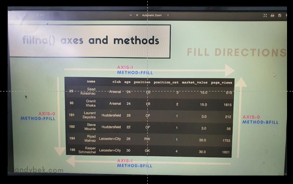

Similar to 'ffill' we have a 'bfill' method which stands for "backward fill"

#### fill directions

- Method ffill => axis =1 -👉👉👉👉👉 Left to Right
- Method ffill => axis =0 👇 Top to Bottom
- Method bfill => axis =0 👆 Bottom to Top
- Method bfill => axis =1 👈👈👈👈👈Right to Left

This is mostly useful in TimeSeries datasets

```python
#ffill => 'pad'
#bfill => 'backfill'
```

### Skill Challenge

#### From our players dataframe , remove the rows labeled 2, 10, 21 and the market_value columns. Do not modify the underlying Dataframe. Assign the result to df2.

```python
players.drop(index = [2,10,21] , columns = 'market_value')
```

|  | name | club | age | position | position_cat | page_views | fpl_value | fpl_sel | fpl_points | region | nationality | new_foreign | age_cat | club_id | big_club | new_signing |
| --- | --- | --- | --- | --- | --- | --- | --- | --- | --- | --- | --- | --- | --- | --- | --- | --- |
| 0 | Alexis Sanchez | Arsenal | 28 | LW | 1 | 4329 | 12.0 | 17.10% | 264 | 3 | Chile | 0 | 4 | 1 | 1 | 0 |
| 1 | Mesut Ozil | Arsenal | 28 | AM | 1 | 4395 | 9.5 | 5.60% | 167 | 2 | Germany | 0 | 4 | 1 | 1 | 0 |
| 3 | Theo Walcott | Arsenal | 28 | RW | 1 | 2393 | 7.5 | 1.50% | 122 | 1 | England | 0 | 4 | 1 | 1 | 0 |
| 4 | Laurent Koscielny | Arsenal | 31 | CB | 3 | 912 | 6.0 | 0.70% | 121 | 2 | France | 0 | 4 | 1 | 1 | 0 |
| 5 | Hector Bellerin | Arsenal | 22 | RB | 3 | 1675 | 6.0 | 13.70% | 119 | 2 | Spain | 0 | 2 | 1 | 1 | 0 |
| ... | ... | ... | ... | ... | ... | ... | ... | ... | ... | ... | ... | ... | ... | ... | ... | ... |
| 460 | Edimilson Fernandes | West+Ham | 21 | CM | 2 | 288 | 4.5 | 0.40% | 38 | 2 | Switzerland | 0 | 1 | 20 | 0 | 1 |
| 461 | Arthur Masuaku | West+Ham | 23 | LB | 3 | 199 | 4.5 | 0.20% | 34 | 4 | Congo DR | 0 | 2 | 20 | 0 | 1 |
| 462 | Sam Byram | West+Ham | 23 | RB | 3 | 198 | 4.5 | 0.30% | 29 | 1 | England | 0 | 2 | 20 | 0 | 0 |
| 463 | Ashley Fletcher | West+Ham | 21 | CF | 1 | 412 | 4.5 | 5.90% | 16 | 1 | England | 0 | 1 | 20 | 0 | 1 |
| 464 | Diafra Sakho | West+Ham | 27 | CF | 1 | 214 | 5.5 | 0.10% | 12 | 4 | Senegal | 0 | 3 | 20 | 0 | 0 |

462 rows × 16 columns

```python
df2 = players.drop(index = [2,10,21] , columns = 'market_value')
```

#### Does the 'nationality' column in df2 contain any NA values? How many unique nationalities are there?

```python
df2.filter(like = 'nationality' , axis = 1).head(1)
```

|  | nationality |
| --- | --- |
| 0 | Chile |

```python
df2.nationality.isna().values.sum()
```

```
0
```

```python
df2.nationality.isnull().sum()
```

```
0
```

```python
df2.nationality.unique()
```

```
array(['Chile', 'Germany', 'England', 'France', 'Spain', 'Nigeria',
       'Switzerland', 'Wales', 'Brazil', 'Egypt', 'Argentina', 'Colombia',
       'Bosnia', 'Norway', 'Poland', 'Scotland', 'Congo DR', 'Ireland',
       'Netherlands', 'Australia', "Cote d'Ivoire", 'Finland', 'Cameroon',
       'Austria', 'Israel', 'Czech Republic', 'Northern Ireland',
       'Canada', 'Belgium', 'Iceland', 'Serbia', 'Portugal', 'Ghana',
       'South Korea', 'Mali', 'Senegal', 'Curacao', 'Denmark', 'Slovenia',
       'Trinidad and Tobago', 'Bermuda', 'Benin', 'Algeria', 'Jamaica',
       'Japan', 'Tunisia', 'Croatia', 'Estonia', 'Ecuador', 'Armenia',
       'Italy', 'Sweden', 'United States', 'Morocco', 'The Gambia',
       'Kenya', 'Greece', 'Uruguay', 'Romania', 'Venezuela',
       'New Zealand'], dtype=object)
```

```python
len(df2.nationality.unique())
```

```
61
```

#### starting from df2 , isolate a dataframe slice of players that contain only the unique age-position combinations for each club. Do not include the 'club' column itself.

```python
df2[['age' , 'club' , 'position']]
```

|  | age | club | position |
| --- | --- | --- | --- |
| 0 | 28 | Arsenal | LW |
| 1 | 28 | Arsenal | AM |
| 3 | 28 | Arsenal | RW |
| 4 | 31 | Arsenal | CB |
| 5 | 22 | Arsenal | RB |
| ... | ... | ... | ... |
| 460 | 21 | West+Ham | CM |
| 461 | 23 | West+Ham | LB |
| 462 | 23 | West+Ham | RB |
| 463 | 21 | West+Ham | CF |
| 464 | 27 | West+Ham | CF |

462 rows × 3 columns

```python
df2[['age' , 'club' , 'position']].shape
```

```
(462, 3)
```

```python
df2.drop_duplicates(subset = ['age' , 'club' , 'position'] , keep = 'first').shape
```

```
(433, 16)
```

```python
#Since we are expected to get the unique 'age-position' combinations , we will start by dropping 'duplicates'
```

```python
df2.drop_duplicates(subset = ['age' , 'club' , 'position'] , keep = 'first').loc[ :, ['age' , 'position', 'club']]
```

|  | age | position | club |
| --- | --- | --- | --- |
| 0 | 28 | LW | Arsenal |
| 1 | 28 | AM | Arsenal |
| 3 | 28 | RW | Arsenal |
| 4 | 31 | CB | Arsenal |
| 5 | 22 | RB | Arsenal |
| ... | ... | ... | ... |
| 460 | 21 | CM | West+Ham |
| 461 | 23 | LB | West+Ham |
| 462 | 23 | RB | West+Ham |
| 463 | 21 | CF | West+Ham |
| 464 | 27 | CF | West+Ham |

433 rows × 3 columns

```python
#We will apply the 'duplicate' logic to a subset of columns : 'age' , 'club' , 'position'
#We will keep the first occurance of each unique record and drop duplicate values
#we are supposed to keep 'age' and 'position' columns , so we use ".loc['age' , 'position']"

df2.drop_duplicates(subset = ['age' , 'club' , 'position'] , keep = 'first').loc[ :, ['age' , 'position']]
```

|  | age | position |
| --- | --- | --- |
| 0 | 28 | LW |
| 1 | 28 | AM |
| 3 | 28 | RW |
| 4 | 31 | CB |
| 5 | 22 | RB |
| ... | ... | ... |
| 460 | 21 | CM |
| 461 | 23 | LB |
| 462 | 23 | RB |
| 463 | 21 | CF |
| 464 | 27 | CF |

433 rows × 2 columns

### Calculating Aggregates with agg()

It aggregates the output of a function that we specify and then collapses the entire axis into a single value.

Examples:

- mean()
- min()
- max()

```python
#lets run agg() on entire dataframe
#Lets apply the mean() function on each of our columns
players.mean()
```

```
age              26.776344
position_cat      2.178495
market_value     11.125649
page_views      771.546237
fpl_value         5.450538
fpl_points       57.544086
region            1.989247
new_foreign       0.034409
age_cat           3.195699
club_id          10.253763
big_club          0.309677
new_signing       0.144086
dtype: float64
```

```python
#Notice we are even getting String columns here
players.min()
```

```
name            Aaron Cresswell
club                    Arsenal
age                          17
position_cat                  1
market_value               0.05
page_views                    3
fpl_value                     4
fpl_sel                   0.00%
fpl_points                    0
region                        1
nationality             Algeria
new_foreign                   0
age_cat                       1
club_id                       1
big_club                      0
new_signing                   0
dtype: object
```

#### We want to select only the numeric columns and apply the aggregate function

```python
players.select_dtypes(np.number)
```

|  | age | position_cat | market_value | page_views | fpl_value | fpl_points | region | new_foreign | age_cat | club_id | big_club | new_signing |
| --- | --- | --- | --- | --- | --- | --- | --- | --- | --- | --- | --- | --- |
| 0 | 28 | 1 | 65.0 | 4329 | 12.0 | 264 | 3 | 0 | 4 | 1 | 1 | 0 |
| 1 | 28 | 1 | 50.0 | 4395 | 9.5 | 167 | 2 | 0 | 4 | 1 | 1 | 0 |
| 2 | 35 | 4 | 7.0 | 1529 | 5.5 | 134 | 2 | 0 | 6 | 1 | 1 | 0 |
| 3 | 28 | 1 | 20.0 | 2393 | 7.5 | 122 | 1 | 0 | 4 | 1 | 1 | 0 |
| 4 | 31 | 3 | 22.0 | 912 | 6.0 | 121 | 2 | 0 | 4 | 1 | 1 | 0 |
| ... | ... | ... | ... | ... | ... | ... | ... | ... | ... | ... | ... | ... |
| 460 | 21 | 2 | 5.0 | 288 | 4.5 | 38 | 2 | 0 | 1 | 20 | 0 | 1 |
| 461 | 23 | 3 | 7.0 | 199 | 4.5 | 34 | 4 | 0 | 2 | 20 | 0 | 1 |
| 462 | 23 | 3 | 4.5 | 198 | 4.5 | 29 | 1 | 0 | 2 | 20 | 0 | 0 |
| 463 | 21 | 1 | 1.0 | 412 | 4.5 | 16 | 1 | 0 | 1 | 20 | 0 | 1 |
| 464 | 27 | 1 | 10.0 | 214 | 5.5 | 12 | 4 | 0 | 3 | 20 | 0 | 0 |

465 rows × 12 columns

```python
players.select_dtypes(object)
```

|  | name | club | position | fpl_sel | nationality |
| --- | --- | --- | --- | --- | --- |
| 0 | Alexis Sanchez | Arsenal | LW | 17.10% | Chile |
| 1 | Mesut Ozil | Arsenal | AM | 5.60% | Germany |
| 2 | Petr Cech | Arsenal | GK | 5.90% | Czech Republic |
| 3 | Theo Walcott | Arsenal | RW | 1.50% | England |
| 4 | Laurent Koscielny | Arsenal | CB | 0.70% | France |
| ... | ... | ... | ... | ... | ... |
| 460 | Edimilson Fernandes | West+Ham | CM | 0.40% | Switzerland |
| 461 | Arthur Masuaku | West+Ham | LB | 0.20% | Congo DR |
| 462 | Sam Byram | West+Ham | RB | 0.30% | England |
| 463 | Ashley Fletcher | West+Ham | CF | 5.90% | England |
| 464 | Diafra Sakho | West+Ham | CF | 0.10% | Senegal |

465 rows × 5 columns

```python
players.select_dtypes(np.number).agg('min')
```

```
age             17.00
position_cat     1.00
market_value     0.05
page_views       3.00
fpl_value        4.00
fpl_points       0.00
region           1.00
new_foreign      0.00
age_cat          1.00
club_id          1.00
big_club         0.00
new_signing      0.00
dtype: float64
```

```python
#we can even pass a list of Aggregate functions
#This will return a DataFrame
players.select_dtypes(np.number).agg(['min', 'max' ,'mean'])
```

|  | age | position_cat | market_value | page_views | fpl_value | fpl_points | region | new_foreign | age_cat | club_id | big_club | new_signing |
| --- | --- | --- | --- | --- | --- | --- | --- | --- | --- | --- | --- | --- |
| min | 17.000000 | 1.000000 | 0.050000 | 3.000000 | 4.000000 | 0.000000 | 1.000000 | 0.000000 | 1.000000 | 1.000000 | 0.000000 | 0.000000 |
| max | 38.000000 | 4.000000 | 75.000000 | 7664.000000 | 12.500000 | 264.000000 | 4.000000 | 1.000000 | 6.000000 | 20.000000 | 1.000000 | 1.000000 |
| mean | 26.776344 | 2.178495 | 11.125649 | 771.546237 | 5.450538 | 57.544086 | 1.989247 | 0.034409 | 3.195699 | 10.253763 | 0.309677 | 0.144086 |

#### One important takeaway is : "agg()" reshapes our data

### Same-Shape Transforms

```python
players.head(1)
```

|  | name | club | age | position | position_cat | market_value | page_views | fpl_value | fpl_sel | fpl_points | region | nationality | new_foreign | age_cat | club_id | big_club | new_signing |
| --- | --- | --- | --- | --- | --- | --- | --- | --- | --- | --- | --- | --- | --- | --- | --- | --- | --- |
| 0 | Alexis Sanchez | Arsenal | 28 | LW | 1 | 65.0 | 4329 | 12.0 | 17.10% | 264 | 3 | Chile | 0 | 4 | 1 | 1 | 0 |

```python
#we want to convert "market_value" and "fpl_value" from one currency to another
#from USD to EURO
#To convert from one currency to another , we need a conversion rate or an fx rate
```

#### 1 USD = 0.91 EURO

```python
players.shape
```

```
(465, 17)
```

```python
players.loc[: , ['market_value' , 'fpl_value']]
```

|  | market_value | fpl_value |
| --- | --- | --- |
| 0 | 65.0 | 12.0 |
| 1 | 50.0 | 9.5 |
| 2 | 7.0 | 5.5 |
| 3 | 20.0 | 7.5 |
| 4 | 22.0 | 6.0 |
| ... | ... | ... |
| 460 | 5.0 | 4.5 |
| 461 | 7.0 | 4.5 |
| 462 | 4.5 | 4.5 |
| 463 | 1.0 | 4.5 |
| 464 | 10.0 | 5.5 |

465 rows × 2 columns

```python
#To this above df we need to apply the currency transformation
#we will use the transform method with inline lambda function
```

```python
players.loc[: , ['market_value' , 'fpl_value']].transform(lambda x: x * 0.91)
```

|  | market_value | fpl_value |
| --- | --- | --- |
| 0 | 59.150 | 10.920 |
| 1 | 45.500 | 8.645 |
| 2 | 6.370 | 5.005 |
| 3 | 18.200 | 6.825 |
| 4 | 20.020 | 5.460 |
| ... | ... | ... |
| 460 | 4.550 | 4.095 |
| 461 | 6.370 | 4.095 |
| 462 | 4.095 | 4.095 |
| 463 | 0.910 | 4.095 |
| 464 | 9.100 | 5.005 |

465 rows × 2 columns

- We see the values have been converted from USD to EUROS , they are slightly lower now.

```python
#We can simply say:
#This approach much be much more performant than the abpve one
players.loc[: , ['market_value' , 'fpl_value']] * 0.91
```

|  | market_value | fpl_value |
| --- | --- | --- |
| 0 | 59.150 | 10.920 |
| 1 | 45.500 | 8.645 |
| 2 | 6.370 | 5.005 |
| 3 | 18.200 | 6.825 |
| 4 | 20.020 | 5.460 |
| ... | ... | ... |
| 460 | 4.550 | 4.095 |
| 461 | 6.370 | 4.095 |
| 462 | 4.095 | 4.095 |
| 463 | 0.910 | 4.095 |
| 464 | 9.100 | 5.005 |

465 rows × 2 columns

- Lets say we want to apply string transformation to all the string columns
- We want the transformation to be randomly selected at run time
- But there are actually no buil in pandas methods to do this
- Lets start by creating our own function

### choice

We use choice to select random item from a sequence of values

```python
#import random module
from random import choice
```

```python
names = ['Bud' , 'Brooke' , 'Paleo']
```

```python
#choice returns one of the items
#If you try again , it returns a diff item
#Choice is used to select a random item from a sequence of values
choice(names)
```

```
'Brooke'
```

### String methods

```python
'Andy'.upper()
```

```
'ANDY'
```

```python
#Lets say we have a pandas series containing these names : ['Bud' , 'Brooke' , 'Paleo']
pd.Series(['Bud' , 'Brooke' , 'Paleo'])
```

```
0       Bud
1    Brooke
2     Paleo
dtype: object
```

```python
#And if you apply upper() to this series , it will give an error
ser = pd.Series(['Bud' , 'Brooke' , 'Paleo'])
```

```python
ser.upper()
```

```
---------------------------------------------------------------------------
AttributeError                            Traceback (most recent call last)
<ipython-input-432-7cbc2ae7004e> in <module>
----> 1 ser.upper()

~\Anaconda3\lib\site-packages\pandas\core\generic.py in __getattr__(self, name)
   5272             if self._info_axis._can_hold_identifiers_and_holds_name(name):
   5273                 return self[name]
-> 5274             return object.__getattribute__(self, name)
   5275
   5276     def __setattr__(self, name: str, value) -> None:

AttributeError: 'Series' object has no attribute 'upper'
```

- To be able to do this in a Pandas Series context
- we simply add the string accessor between the method and the Series object
- so instead of ser.upper() , we say : ser.str.upper()
- That gives us access to the upper method

```python
ser.str.upper()
```

```
0       BUD
1    BROOKE
2     PALEO
dtype: object
```

### title()

- In the same way we will apply the title() method

```python
ser = pd.Series(['Bud CriMSon' , 'Brooke' , 'Paleo'])
```

```python
ser.str.title()
```

```
0    Bud Crimson
1         Brooke
2          Paleo
dtype: object
```

### swapcase()

flips the case

```python
ser.str.swapcase()
```

```
0    bUD cRImsON
1         bROOKE
2          pALEO
dtype: object
```

### Define the random transformation function

- Defining a function:
  - Apply a random string capitalization method
  - Apply to a sequence of values and
  - It should return the transformed sequence
- we define a function called random_case
- In the end , this function will be called from within transform()
- It should only focus on string columns

```python
#here x will always represent a column
#choice will select a string function randomly to be applied to the column
#we add the parenthesis to actually invoke the function
#choice(funcs)()

def random_case(x):
    funcs = [x.str.swapcase, x.str.lower, x.str.title , x.str.upper]

    return choice(funcs)()
```

```python
#Each time we run the below code to apply the random_case function , a different string transformation will be applied
players.select_dtypes(include = object).transform(random_case)
```

|  | name | club | position | fpl_sel | nationality |
| --- | --- | --- | --- | --- | --- |
| 0 | aLEXIS sANCHEZ | arsenal | LW | 17.10% | chile |
| 1 | mESUT oZIL | arsenal | AM | 5.60% | germany |
| 2 | pETR cECH | arsenal | GK | 5.90% | czech republic |
| 3 | tHEO wALCOTT | arsenal | RW | 1.50% | england |
| 4 | lAURENT kOSCIELNY | arsenal | CB | 0.70% | france |
| ... | ... | ... | ... | ... | ... |
| 460 | eDIMILSON fERNANDES | west+ham | CM | 0.40% | switzerland |
| 461 | aRTHUR mASUAKU | west+ham | LB | 0.20% | congo dr |
| 462 | sAM bYRAM | west+ham | RB | 0.30% | england |
| 463 | aSHLEY fLETCHER | west+ham | CF | 5.90% | england |
| 464 | dIAFRA sAKHO | west+ham | CF | 0.10% | senegal |

465 rows × 5 columns

```python
#lets put this in a loop

for i in range(4):
    print(players.select_dtypes(include = object).transform(random_case).head())
```

```
                name     club position fpl_sel     nationality
0     ALEXIS SANCHEZ  aRSENAL       lw  17.10%           chile
1         MESUT OZIL  aRSENAL       am   5.60%         germany
2          PETR CECH  aRSENAL       gk   5.90%  czech republic
3       THEO WALCOTT  aRSENAL       rw   1.50%         england
4  LAURENT KOSCIELNY  aRSENAL       cb   0.70%          france
                name     club position fpl_sel     nationality
0     ALEXIS SANCHEZ  aRSENAL       Lw  17.10%           Chile
1         MESUT OZIL  aRSENAL       Am   5.60%         Germany
2          PETR CECH  aRSENAL       Gk   5.90%  Czech Republic
3       THEO WALCOTT  aRSENAL       Rw   1.50%         England
4  LAURENT KOSCIELNY  aRSENAL       Cb   0.70%          France
                name     club position fpl_sel     nationality
0     aLEXIS sANCHEZ  Arsenal       lw  17.10%           Chile
1         mESUT oZIL  Arsenal       am   5.60%         Germany
2          pETR cECH  Arsenal       gk   5.90%  Czech Republic
3       tHEO wALCOTT  Arsenal       rw   1.50%         England
4  lAURENT kOSCIELNY  Arsenal       cb   0.70%          France
                name     club position fpl_sel     nationality
0     alexis sanchez  Arsenal       lw  17.10%           Chile
1         mesut ozil  Arsenal       am   5.60%         Germany
2          petr cech  Arsenal       gk   5.90%  Czech Republic
3       theo walcott  Arsenal       rw   1.50%         England
4  laurent koscielny  Arsenal       cb   0.70%          France
```

Unlike the agg() method , transform() does not reshape the dataframe , it simply applies the function in place without chagingin the shape of the df

### More flexibility with apply()

https://www.udemy.com/course/the-ultimate-pandas-bootcamp-advanced-python-data-analysis/learn/lecture/19013744#overview

```python
#When we want to apply a given function to entire DataFrame row or column
```

```python
players.head(2)
```

|  | name | club | age | position | position_cat | market_value | page_views | fpl_value | fpl_sel | fpl_points | region | nationality | new_foreign | age_cat | club_id | big_club | new_signing |
| --- | --- | --- | --- | --- | --- | --- | --- | --- | --- | --- | --- | --- | --- | --- | --- | --- | --- |
| 0 | Alexis Sanchez | Arsenal | 28 | LW | 1 | 65.0 | 4329 | 12.0 | 17.10% | 264 | 3 | Chile | 0 | 4 | 1 | 1 | 0 |
| 1 | Mesut Ozil | Arsenal | 28 | AM | 1 | 50.0 | 4395 | 9.5 | 5.60% | 167 | 2 | Germany | 0 | 4 | 1 | 1 | 0 |

The Dataframe apply() method gives us the opportunity to apply a function across the entire DataFrame , one row or one column at a time.

- We want to modify all our floating point columns and round them to the closest integer without actually converting them to integer
- we start by defining a function called round_floats()
- to check if the dtype is float , return the rounded version of that series , if not we return the Series unchanged
- Remember x will be a series when this function runs and series will have the dtype attribute.
- Thats why we are checking the dtype first.

```python
def round_floats(x):
    if x.dtype == np.float64:
        return round(x)

    return x
```

```python
players.head(2)
```

|  | name | club | age | position | position_cat | market_value | page_views | fpl_value | fpl_sel | fpl_points | region | nationality | new_foreign | age_cat | club_id | big_club | new_signing |
| --- | --- | --- | --- | --- | --- | --- | --- | --- | --- | --- | --- | --- | --- | --- | --- | --- | --- |
| 0 | Alexis Sanchez | Arsenal | 28 | LW | 1 | 65.0 | 4329 | 12.0 | 17.10% | 264 | 3 | Chile | 0 | 4 | 1 | 1 | 0 |
| 1 | Mesut Ozil | Arsenal | 28 | AM | 1 | 50.0 | 4395 | 9.5 | 5.60% | 167 | 2 | Germany | 0 | 4 | 1 | 1 | 0 |

```python
#Applying the function to dataframe
players.apply(round_floats)
```

|  | name | club | age | position | position_cat | market_value | page_views | fpl_value | fpl_sel | fpl_points | region | nationality | new_foreign | age_cat | club_id | big_club | new_signing |
| --- | --- | --- | --- | --- | --- | --- | --- | --- | --- | --- | --- | --- | --- | --- | --- | --- | --- |
| 0 | Alexis Sanchez | Arsenal | 28 | LW | 1 | 65.0 | 4329 | 12.0 | 17.10% | 264 | 3 | Chile | 0 | 4 | 1 | 1 | 0 |
| 1 | Mesut Ozil | Arsenal | 28 | AM | 1 | 50.0 | 4395 | 10.0 | 5.60% | 167 | 2 | Germany | 0 | 4 | 1 | 1 | 0 |
| 2 | Petr Cech | Arsenal | 35 | GK | 4 | 7.0 | 1529 | 6.0 | 5.90% | 134 | 2 | Czech Republic | 0 | 6 | 1 | 1 | 0 |
| 3 | Theo Walcott | Arsenal | 28 | RW | 1 | 20.0 | 2393 | 8.0 | 1.50% | 122 | 1 | England | 0 | 4 | 1 | 1 | 0 |
| 4 | Laurent Koscielny | Arsenal | 31 | CB | 3 | 22.0 | 912 | 6.0 | 0.70% | 121 | 2 | France | 0 | 4 | 1 | 1 | 0 |
| ... | ... | ... | ... | ... | ... | ... | ... | ... | ... | ... | ... | ... | ... | ... | ... | ... | ... |
| 460 | Edimilson Fernandes | West+Ham | 21 | CM | 2 | 5.0 | 288 | 4.0 | 0.40% | 38 | 2 | Switzerland | 0 | 1 | 20 | 0 | 1 |
| 461 | Arthur Masuaku | West+Ham | 23 | LB | 3 | 7.0 | 199 | 4.0 | 0.20% | 34 | 4 | Congo DR | 0 | 2 | 20 | 0 | 1 |
| 462 | Sam Byram | West+Ham | 23 | RB | 3 | 4.0 | 198 | 4.0 | 0.30% | 29 | 1 | England | 0 | 2 | 20 | 0 | 0 |
| 463 | Ashley Fletcher | West+Ham | 21 | CF | 1 | 1.0 | 412 | 4.0 | 5.90% | 16 | 1 | England | 0 | 1 | 20 | 0 | 1 |
| 464 | Diafra Sakho | West+Ham | 27 | CF | 1 | 10.0 | 214 | 6.0 | 0.10% | 12 | 4 | Senegal | 0 | 3 | 20 | 0 | 0 |

465 rows × 17 columns

```python
#lets see the transformation more closely
players.select_dtypes(np.float64).head()
```

|  | market_value | fpl_value |
| --- | --- | --- |
| 0 | 65.0 | 12.0 |
| 1 | 50.0 | 9.5 |
| 2 | 7.0 | 5.5 |
| 3 | 20.0 | 7.5 |
| 4 | 22.0 | 6.0 |

```python
players.select_dtypes(np.float64).apply(round_floats).head()
```

|  | market_value | fpl_value |
| --- | --- | --- |
| 0 | 65.0 | 12.0 |
| 1 | 50.0 | 10.0 |
| 2 | 7.0 | 6.0 |
| 3 | 20.0 | 8.0 |
| 4 | 22.0 | 6.0 |

- notice that 7.5 has become 8.0
- transform can be used in place of apply()
- it will give the same result

```python
players.select_dtypes(np.float64).transform(round_floats).head()
```

|  | market_value | fpl_value |
| --- | --- | --- |
| 0 | 65.0 | 12.0 |
| 1 | 50.0 | 10.0 |
| 2 | 7.0 | 6.0 |
| 3 | 20.0 | 8.0 |
| 4 | 22.0 | 6.0 |

apply() is much more flexible. It can combine agg() and transform()

```python
#apply() as aggregate
```

```python
#how we use agg() to get the mean
players.agg('mean')
```

```
age              26.776344
position_cat      2.178495
market_value     11.125649
page_views      771.546237
fpl_value         5.450538
fpl_points       57.544086
region            1.989247
new_foreign       0.034409
age_cat           3.195699
club_id          10.253763
big_club          0.309677
new_signing       0.144086
dtype: float64
```

```python
#We can use the same with apply , it is capable of applying the mean()
players.apply('mean')
```

```
age              26.776344
position_cat      2.178495
market_value     11.125649
page_views      771.546237
fpl_value         5.450538
fpl_points       57.544086
region            1.989247
new_foreign       0.034409
age_cat           3.195699
club_id          10.253763
big_club          0.309677
new_signing       0.144086
dtype: float64
```

```python
#But this is not possible with tansform()
#throws an error
players.transform('mean')
```

```
---------------------------------------------------------------------------
ValueError                                Traceback (most recent call last)
<ipython-input-458-7c522b07dead> in <module>
      1 #But this is not possible with tansform()
      2 #throws an error
----> 3 players.transform('mean')

~\Anaconda3\lib\site-packages\pandas\core\frame.py in transform(self, func, axis, *args, **kwargs)
   6727         if axis == 1:
   6728             return self.T.transform(func, *args, **kwargs).T
-> 6729         return super().transform(func, *args, **kwargs)
   6730
   6731     def apply(self, func, axis=0, raw=False, result_type=None, args=(), **kwds):

~\Anaconda3\lib\site-packages\pandas\core\generic.py in transform(self, func, *args, **kwargs)
  10425         result = self.agg(func, *args, **kwargs)
  10426         if is_scalar(result) or len(result) != len(self):
> 10427             raise ValueError("transforms cannot produce aggregated results")
  10428
  10429         return result

ValueError: transforms cannot produce aggregated results
```

```python
#flipping the axis parameter
#When we aggregate to apply the mean() or aggregation like calculations, change of the axis produces fundamentally different
#results
#by default the axis is set to 0
```

```python
#We want the values to aggregate vertically , we get the mean for each column
players.apply('mean' , axis = 0)
```

```
age              26.776344
position_cat      2.178495
market_value     11.125649
page_views      771.546237
fpl_value         5.450538
fpl_points       57.544086
region            1.989247
new_foreign       0.034409
age_cat           3.195699
club_id          10.253763
big_club          0.309677
new_signing       0.144086
dtype: float64
```

```python
#but when we say axis = 1 , we are switching to aggregating horizontally
#which explains why we get 465 averages (which is same as the dataframe shape)
```

```python
players.apply('mean' , axis = 1)
```

```
0      392.333333
1      388.208333
2      143.708333
3      214.875000
4       91.916667
          ...
460     31.875000
461     24.791667
462     23.750000
463     39.875000
464     24.708333
Length: 465, dtype: float64
```

- We are now calculating horizontal averages by row
- These averages do not make a lot of sense in our players Dataframe
- Because they represent the avrerages of -----> 'age'....--->'market_value'.....>'fpl_value'....etc...which makes no sense
- And remember its automatically taking only numeric columns into consideration

```python
Remember , if we have mixed datatypes and we try to calculate the mean we will get the type error
```

```python
#for reference sake , lets look at the Row : 460 , which gave us a mean() of 31.875000
```

```python
players.loc[460 , [dtype != object for dtype in players.dtypes]].mean()
```

```
31.875
```

### Element-wise Operations with applymap()

```python
#vectorized ops : agg() , transform() , apply()
```

### non-vectorized : applymap()

```python
#lets say we want to adjust our player's market_value and fpl_value for Inflation
```

Inflation is the rate of increase in prices over a given period of time. Inflation is typically a broad measure, such as the overall increase in prices or the increase in the cost of living in a country.

- the banks in the world try to maintain a small positive Inflation
- In developed economies , its 2% a year
- Lets say we want to adjust ou market_value and fpl_value by 2%
- We start by isolating them

```python
inflation  = 1.02
```

```python
#select all rows and those two columns
players.loc[: , ['market_value' , 'fpl_value']]
```

|  | market_value | fpl_value |
| --- | --- | --- |
| 0 | 65.0 | 12.0 |
| 1 | 50.0 | 9.5 |
| 2 | 7.0 | 5.5 |
| 3 | 20.0 | 7.5 |
| 4 | 22.0 | 6.0 |
| ... | ... | ... |
| 460 | 5.0 | 4.5 |
| 461 | 7.0 | 4.5 |
| 462 | 4.5 | 4.5 |
| 463 | 1.0 | 4.5 |
| 464 | 10.0 | 5.5 |

465 rows × 2 columns

```python
mini_df =  players.loc[: , ['market_value' , 'fpl_value']]
```

```python
#To adjust the values , we could simply multiply by the variable : inflation
mini_df * inflation
```

|  | market_value | fpl_value |
| --- | --- | --- |
| 0 | 66.30 | 12.24 |
| 1 | 51.00 | 9.69 |
| 2 | 7.14 | 5.61 |
| 3 | 20.40 | 7.65 |
| 4 | 22.44 | 6.12 |
| ... | ... | ... |
| 460 | 5.10 | 4.59 |
| 461 | 7.14 | 4.59 |
| 462 | 4.59 | 4.59 |
| 463 | 1.02 | 4.59 |
| 464 | 10.20 | 5.61 |

465 rows × 2 columns

- We don't really need a function here
- And this is a highly efficient vectorized operation
- It operates on the entire column at once
- But , unfortunately not all functions can be vectorized
- Lets assume , in addition to making the adjustment for inflation , we also want to know precisely , when each one hundered'th value was adjusted for Inflation.
- so, for every one-hunderedth value , we want a function to print out the Time stamp , when the transformation took place.
- So, for that we need to define our own custom function

```python
#We first set the counter , so we know when each one -hunderedth value is adjusted
#define the function
#set the counter as global
#incremenet the counter by 1
#if counter is a multiple of 100 in other words, the remainder when divided by 100 is 0
#we want to printout a notification
#We are conditionally printing the notification but for all values we are adjusting the Inflation as well
#One quick note : The Syntax that we are using for string is called : "Literal String Interpolation"
#or f strings

from datetime import datetime
counter = 0

def log_and_transform(x):
    global counter
    counter += 1
    if counter % 100 == 0:
        print(f"It's {datetime.now()} and I adjusted the {counter}th  value.")

    return x * inflation
```

```python
mini_df.applymap(log_and_transform)
```

```
It's 2022-12-03 16:33:27.833148 and I adjusted the 100th  value.
It's 2022-12-03 16:33:27.834144 and I adjusted the 200th  value.
It's 2022-12-03 16:33:27.834144 and I adjusted the 300th  value.
It's 2022-12-03 16:33:27.834144 and I adjusted the 400th  value.
It's 2022-12-03 16:33:27.834144 and I adjusted the 500th  value.
It's 2022-12-03 16:33:27.835475 and I adjusted the 600th  value.
It's 2022-12-03 16:33:27.835475 and I adjusted the 700th  value.
It's 2022-12-03 16:33:27.835475 and I adjusted the 800th  value.
It's 2022-12-03 16:33:27.835475 and I adjusted the 900th  value.
It's 2022-12-03 16:33:27.836138 and I adjusted the 1000th  value.
It's 2022-12-03 16:33:27.836138 and I adjusted the 1100th  value.
It's 2022-12-03 16:33:27.836138 and I adjusted the 1200th  value.
It's 2022-12-03 16:33:27.836138 and I adjusted the 1300th  value.
```

|  | market_value | fpl_value |
| --- | --- | --- |
| 0 | 66.30 | 12.24 |
| 1 | 51.00 | 9.69 |
| 2 | 7.14 | 5.61 |
| 3 | 20.40 | 7.65 |
| 4 | 22.44 | 6.12 |
| ... | ... | ... |
| 460 | 5.10 | 4.59 |
| 461 | 7.14 | 4.59 |
| 462 | 4.59 | 4.59 |
| 463 | 1.02 | 4.59 |
| 464 | 10.20 | 5.61 |

465 rows × 2 columns

- This is only possible because applymap() is applying the function to one value at a time

```python
mini_df.apply(log_and_transform)
```

|  | market_value | fpl_value |
| --- | --- | --- |
| 0 | 66.30 | 12.24 |
| 1 | 51.00 | 9.69 |
| 2 | 7.14 | 5.61 |
| 3 | 20.40 | 7.65 |
| 4 | 22.44 | 6.12 |
| ... | ... | ... |
| 460 | 5.10 | 4.59 |
| 461 | 7.14 | 4.59 |
| 462 | 4.59 | 4.59 |
| 463 | 1.02 | 4.59 |
| 464 | 10.20 | 5.61 |

465 rows × 2 columns

### We should always prefer vectorized operations over element-wise operations

only if we have a specific requirement , we can use applymap()

### Skill Challenege

#### Create a Standalone function that :

```
- accepts a single parameter x
- returns the string 'relatively unknown' if x is less than 220
- 'kind of popular' if x is between 220 and 600(non-inclusive)
- 'popular' if x is between 600 and 2000 (non-inclusive)
- 'super-popular' otherwise
```

```python
def get_popularity(x):
    if x < 220:
        return 'relatively unknown'
    elif x < 600:
        return 'kind of popular'
    elif x < 2000:
        return 'popular'
    else:
        return 'Super Popular'
```

```python
get_popularity(2001)
```

```
'Super Popular'
```

#### Apply the function from the step above to the players page_views column. Use a method that supports vectorized operations.

```python
#we get a Series
players.page_views
```

```
0      4329
1      4395
2      1529
3      2393
4       912
       ...
460     288
461     199
462     198
463     412
464     214
Name: page_views, Length: 465, dtype: int64
```

```python
players.page_views.apply(get_popularity)
```

```
0           Super Popular
1           Super Popular
2                 popular
3           Super Popular
4                 popular
              ...
460       kind of popular
461    relatively unknown
462    relatively unknown
463       kind of popular
464    relatively unknown
Name: page_views, Length: 465, dtype: object
```

```python
players.head(2)
```

|  | name | club | age | position | position_cat | market_value | page_views | fpl_value | fpl_sel | fpl_points | region | nationality | new_foreign | age_cat | club_id | big_club | new_signing |
| --- | --- | --- | --- | --- | --- | --- | --- | --- | --- | --- | --- | --- | --- | --- | --- | --- | --- |
| 0 | Alexis Sanchez | Arsenal | 28 | LW | 1 | 65.0 | 4329 | 12.0 | 17.10% | 264 | 3 | Chile | 0 | 4 | 1 | 1 | 0 |
| 1 | Mesut Ozil | Arsenal | 28 | AM | 1 | 50.0 | 4395 | 9.5 | 5.60% | 167 | 2 | Germany | 0 | 4 | 1 | 1 | 0 |

### Add the output from the step above as a column to the 'players' dataframe. Name the column "popularity"

```python
players['popularity'] = players.page_views.apply(get_popularity)
```

```python
players.head(4)
```

|  | name | club | age | position | position_cat | market_value | page_views | fpl_value | fpl_sel | fpl_points | region | nationality | new_foreign | age_cat | club_id | big_club | new_signing | popularity |
| --- | --- | --- | --- | --- | --- | --- | --- | --- | --- | --- | --- | --- | --- | --- | --- | --- | --- | --- |
| 0 | Alexis Sanchez | Arsenal | 28 | LW | 1 | 65.0 | 4329 | 12.0 | 17.10% | 264 | 3 | Chile | 0 | 4 | 1 | 1 | 0 | Super Popular |
| 1 | Mesut Ozil | Arsenal | 28 | AM | 1 | 50.0 | 4395 | 9.5 | 5.60% | 167 | 2 | Germany | 0 | 4 | 1 | 1 | 0 | Super Popular |
| 2 | Petr Cech | Arsenal | 35 | GK | 4 | 7.0 | 1529 | 5.5 | 5.90% | 134 | 2 | Czech Republic | 0 | 6 | 1 | 1 | 0 | popular |
| 3 | Theo Walcott | Arsenal | 28 | RW | 1 | 20.0 | 2393 | 7.5 | 1.50% | 122 | 1 | England | 0 | 4 | 1 | 1 | 0 | Super Popular |

### How many 'Super Popular' players are there?

```python
players.popularity.value_counts()
```

```
kind of popular       170
popular               143
relatively unknown    115
Super Popular          37
Name: popularity, dtype: int64
```

- There are 37 Super-Popular players

```python
players[players.popularity == 'Super Popular'].head(3)
```

|  | name | club | age | position | position_cat | market_value | page_views | fpl_value | fpl_sel | fpl_points | region | nationality | new_foreign | age_cat | club_id | big_club | new_signing | popularity |
| --- | --- | --- | --- | --- | --- | --- | --- | --- | --- | --- | --- | --- | --- | --- | --- | --- | --- | --- |
| 0 | Alexis Sanchez | Arsenal | 28 | LW | 1 | 65.0 | 4329 | 12.0 | 17.10% | 264 | 3 | Chile | 0 | 4 | 1 | 1 | 0 | Super Popular |
| 1 | Mesut Ozil | Arsenal | 28 | AM | 1 | 50.0 | 4395 | 9.5 | 5.60% | 167 | 2 | Germany | 0 | 4 | 1 | 1 | 0 | Super Popular |
| 3 | Theo Walcott | Arsenal | 28 | RW | 1 | 20.0 | 2393 | 7.5 | 1.50% | 122 | 1 | England | 0 | 4 | 1 | 1 | 0 | Super Popular |

### Setting DataFrame Values

In the previous sections we explored lot of techniques for extracting data from dataframes. Then we took a deeper dive into applying transformations and Aggregations.

Sometimes we dont want to transform the entire row or column at once. Occasionally we want to modify just a single value. We could easily do that using 'EQUALs' assignment operator. Its a two step process.

- First we select the value , then we assign the 'equals' assignment operator

```python
players.head(4)
```

|  | name | club | age | position | position_cat | market_value | page_views | fpl_value | fpl_sel | fpl_points | region | nationality | new_foreign | age_cat | club_id | big_club | new_signing | popularity |
| --- | --- | --- | --- | --- | --- | --- | --- | --- | --- | --- | --- | --- | --- | --- | --- | --- | --- | --- |
| 0 | Alexis Sanchez | Arsenal | 28 | LW | 1 | 65.0 | 4329 | 12.0 | 17.10% | 264 | 3 | Chile | 0 | 4 | 1 | 1 | 0 | Super Popular |
| 1 | Mesut Ozil | Arsenal | 28 | AM | 1 | 50.0 | 4395 | 9.5 | 5.60% | 167 | 2 | Germany | 0 | 4 | 1 | 1 | 0 | Super Popular |
| 2 | Petr Cech | Arsenal | 35 | GK | 4 | 7.0 | 1529 | 5.5 | 5.90% | 134 | 2 | Czech Republic | 0 | 6 | 1 | 1 | 0 | popular |
| 3 | Theo Walcott | Arsenal | 28 | RW | 1 | 20.0 | 2393 | 7.5 | 1.50% | 122 | 1 | England | 0 | 4 | 1 | 1 | 0 | Super Popular |

Lets say , we want to change the "position" of "Theo Walcott" from "RW" to "CN"

#### We can make use of Label based indexing

```python
players.loc[3, 'position'] = 'CN'
```

```python
players.head(4)
```

|  | name | club | age | position | position_cat | market_value | page_views | fpl_value | fpl_sel | fpl_points | region | nationality | new_foreign | age_cat | club_id | big_club | new_signing | popularity |
| --- | --- | --- | --- | --- | --- | --- | --- | --- | --- | --- | --- | --- | --- | --- | --- | --- | --- | --- |
| 0 | Alexis Sanchez | Arsenal | 28 | LW | 1 | 65.0 | 4329 | 12.0 | 17.10% | 264 | 3 | Chile | 0 | 4 | 1 | 1 | 0 | Super Popular |
| 1 | Mesut Ozil | Arsenal | 28 | AM | 1 | 50.0 | 4395 | 9.5 | 5.60% | 167 | 2 | Germany | 0 | 4 | 1 | 1 | 0 | Super Popular |
| 2 | Petr Cech | Arsenal | 35 | GK | 4 | 7.0 | 1529 | 5.5 | 5.90% | 134 | 2 | Czech Republic | 0 | 6 | 1 | 1 | 0 | popular |
| 3 | Theo Walcott | Arsenal | 28 | CN | 1 | 20.0 | 2393 | 7.5 | 1.50% | 122 | 1 | England | 0 | 4 | 1 | 1 | 0 | Super Popular |

#### We can make use of position based indexing as well

```python
#row 3 and column 3
players.iloc[3, 3]
```

```
'CN'
```

```python
players.iloc[3, 3] = 'RW'
```

#### at[ ] and iat[ ] should be preferred for Single value assignment

at[ ] is a label based indexer which is most similar to .loc

```python
players.at[3 , 'position']
```

```
'RW'
```

```python
players.at[3 , 'position'] = 'CN'
```

```python
players.head(4)
```

|  | name | club | age | position | position_cat | market_value | page_views | fpl_value | fpl_sel | fpl_points | region | nationality | new_foreign | age_cat | club_id | big_club | new_signing | popularity |
| --- | --- | --- | --- | --- | --- | --- | --- | --- | --- | --- | --- | --- | --- | --- | --- | --- | --- | --- |
| 0 | Alexis Sanchez | Arsenal | 28 | LW | 1 | 65.0 | 4329 | 12.0 | 17.10% | 264 | 3 | Chile | 0 | 4 | 1 | 1 | 0 | Super Popular |
| 1 | Mesut Ozil | Arsenal | 28 | AM | 1 | 50.0 | 4395 | 9.5 | 5.60% | 167 | 2 | Germany | 0 | 4 | 1 | 1 | 0 | Super Popular |
| 2 | Petr Cech | Arsenal | 35 | GK | 4 | 7.0 | 1529 | 5.5 | 5.90% | 134 | 2 | Czech Republic | 0 | 6 | 1 | 1 | 0 | popular |
| 3 | Theo Walcott | Arsenal | 28 | CN | 1 | 20.0 | 2393 | 7.5 | 1.50% | 122 | 1 | England | 0 | 4 | 1 | 1 | 0 | Super Popular |

#### iat[ ] is similar to iloc[ ]

```python
players.iat[3, 3] = 'RW'
```

```python
players.head(4)
```

|  | name | club | age | position | position_cat | market_value | page_views | fpl_value | fpl_sel | fpl_points | region | nationality | new_foreign | age_cat | club_id | big_club | new_signing | popularity |
| --- | --- | --- | --- | --- | --- | --- | --- | --- | --- | --- | --- | --- | --- | --- | --- | --- | --- | --- |
| 0 | Alexis Sanchez | Arsenal | 28 | LW | 1 | 65.0 | 4329 | 12.0 | 17.10% | 264 | 3 | Chile | 0 | 4 | 1 | 1 | 0 | Super Popular |
| 1 | Mesut Ozil | Arsenal | 28 | AM | 1 | 50.0 | 4395 | 9.5 | 5.60% | 167 | 2 | Germany | 0 | 4 | 1 | 1 | 0 | Super Popular |
| 2 | Petr Cech | Arsenal | 35 | GK | 4 | 7.0 | 1529 | 5.5 | 5.90% | 134 | 2 | Czech Republic | 0 | 6 | 1 | 1 | 0 | popular |
| 3 | Theo Walcott | Arsenal | 28 | RW | 1 | 20.0 | 2393 | 7.5 | 1.50% | 122 | 1 | England | 0 | 4 | 1 | 1 | 0 | Super Popular |

### The Setting with Copy warning

```python
players.head(3)
```

|  | name | club | age | position | position_cat | market_value | page_views | fpl_value | fpl_sel | fpl_points | region | nationality | new_foreign | age_cat | club_id | big_club | new_signing | popularity |
| --- | --- | --- | --- | --- | --- | --- | --- | --- | --- | --- | --- | --- | --- | --- | --- | --- | --- | --- |
| 0 | Alexis Sanchez | Arsenal | 28 | LW | 1 | 65.0 | 4329 | 12.0 | 17.10% | 264 | 3 | Chile | 0 | 4 | 1 | 1 | 0 | Super Popular |
| 1 | Mesut Ozil | Arsenal | 28 | AM | 1 | 50.0 | 4395 | 9.5 | 5.60% | 167 | 2 | Germany | 0 | 4 | 1 | 1 | 0 | Super Popular |
| 2 | Petr Cech | Arsenal | 35 | GK | 4 | 7.0 | 1529 | 5.5 | 5.90% | 134 | 2 | Czech Republic | 0 | 6 | 1 | 1 | 0 | popular |

```python
#We want to extract "Petr Cech" ---> 'page_views'
```

```python
#First isolate the Series
players['page_views']
```

```
0      4329
1      4395
2      1529
3      2393
4       912
       ...
460     288
461     199
462     198
463     412
464     214
Name: page_views, Length: 465, dtype: int64
```

```python
#The use the Row label
players['page_views'][2]
```

```
1529
```

```python
#But when we try setting the value to something else
#we get the error
players['page_views'][2] = 2001
```

```
<ipython-input-538-ed0c557f33c5>:3: SettingWithCopyWarning:
A value is trying to be set on a copy of a slice from a DataFrame

See the caveats in the documentation: https://pandas.pydata.org/pandas-docs/stable/user_guide/indexing.html#returning-a-view-versus-a-copy
  players['page_views'][2] = 2001
```

#### Warning : A value is trying to be set on a copy of a slice from a DataFrame

Reason : Because Pandas cannot guarantee that we are working with the actual underlying DataFrame , when we do indexing like this , which is called "chain indexing" , and specifically we are doing assignment using chain indexing.

If we are working with the copy of the DataFrame , any change that we do to that copy does not change the underlying data. So pandas cannot guarantee that the assignment that we are trying to do will be reflected in the underlying DataFrame.

### View VS Copy

A VIEW is like a window into the undelying Data. Its like an opening that gives us direct access to the data. If we modify what we see , we are modifying the df.

A COPY on the other hand is a replica of whats in the dataframe. So if we change the copy we dont affect the underlying df.

But how do we know if we are working with a copy or a window.

#### 2 Point Rule:

Pandas loves to give us copies.

BUT

if we use loc / iloc or at / iat , we are guaranteed to get a view

When the inplace parameter is set to False then we are guaranteed to get copies of the dataframe. So , in those instances we are just changing the copy and it will not impact the underlying data.

- Lets say , we need to change a couple of values and we need to be guaranteed that we are working with a view. We want to make sure that the values in the underlying Dataframe change and we also want to avoid the setting with copy warning.
- its advisable to use 'loc' / 'iloc' or 'at' / 'iat' indexers

```python
#Lets say we want to set multiple values ar once
#we are trying to change 'position' for first 4 records

players.loc[0 : 3 , 'position'] = ['CM' , 'RW' , 'CB' , 'BK']
```

```python
players.head(4)
```

[output not shown]

```python
#Aaron ==> Nickname
```

```python
players.loc[players.name.str.startswith('Aaron')]
```

|  | name | club | age | position | position_cat | market_value | page_views | fpl_value | fpl_sel | fpl_points | region | nationality | new_foreign | age_cat | club_id | big_club | new_signing |
| --- | --- | --- | --- | --- | --- | --- | --- | --- | --- | --- | --- | --- | --- | --- | --- | --- | --- |
| 15 | Aaron Ramsey | Arsenal | 26 | CM | 2 | 35.0 | 1040 | 7.0 | 5.10% | 56 | 1 | Wales | 0 | 3 | 1 | 1 | 0 |
| 157 | Aaron Lennon | Everton | 30 | RW | 1 | 5.0 | 504 | 5.5 | 0.20% | 22 | 1 | England | 0 | 4 | 7 | 0 | 0 |
| 176 | Aaron Mooy | Huddersfield | 26 | CM | 2 | 5.0 | 588 | 5.5 | 2.50% | 0 | 4 | Australia | 0 | 3 | 8 | 0 | 0 |
| 455 | Aaron Cresswell | West+Ham | 27 | LB | 3 | 12.0 | 380 | 5.0 | 1.30% | 60 | 1 | England | 0 | 3 | 20 | 0 | 0 |

```python
players.loc[players.name.str.startswith('Aaron') , 'name']
```

```
15        Aaron Ramsey
157       Aaron Lennon
176         Aaron Mooy
455    Aaron Cresswell
Name: name, dtype: object
```

```python
players.loc[players.name.str.startswith('Aaron') ]['name']
```

```
15        Aaron Ramsey
157       Aaron Lennon
176         Aaron Mooy
455    Aaron Cresswell
Name: name, dtype: object
```

```python
#players.loc[players.name.str.startswith('Aaron') ]['name'] = 'Ronny'
#This is not proper
```

```python
#This is proper
players.loc[players.name.str.startswith('Aaron') , 'name'] = 'Ronny'
```

```python
players.loc[[15, 157 , 176 , 455]]
```

|  | name | club | age | position | position_cat | market_value | page_views | fpl_value | fpl_sel | fpl_points | region | nationality | new_foreign | age_cat | club_id | big_club | new_signing |
| --- | --- | --- | --- | --- | --- | --- | --- | --- | --- | --- | --- | --- | --- | --- | --- | --- | --- |
| 15 | Ronny | Arsenal | 26 | CM | 2 | 35.0 | 1040 | 7.0 | 5.10% | 56 | 1 | Wales | 0 | 3 | 1 | 1 | 0 |
| 157 | Ronny | Everton | 30 | RW | 1 | 5.0 | 504 | 5.5 | 0.20% | 22 | 1 | England | 0 | 4 | 7 | 0 | 0 |
| 176 | Ronny | Huddersfield | 26 | CM | 2 | 5.0 | 588 | 5.5 | 2.50% | 0 | 4 | Australia | 0 | 3 | 8 | 0 | 0 |
| 455 | Ronny | West+Ham | 27 | LB | 3 | 12.0 | 380 | 5.0 | 1.30% | 60 | 1 | England | 0 | 3 | 20 | 0 | 0 |

You can see that the underlying data got changed. Because pandas guarantees that we are working with a VIEW and not a COPY

#### LOOK at the ERROR below , if we do not use the code properly

```python
players.loc[players.name.str.startswith('Ronny')] = 'Vicky'
```

```python
players.loc[[15, 157 , 176 , 455]]
```

|  | name | club | age | position | position_cat | market_value | page_views | fpl_value | fpl_sel | fpl_points | region | nationality | new_foreign | age_cat | club_id | big_club | new_signing |
| --- | --- | --- | --- | --- | --- | --- | --- | --- | --- | --- | --- | --- | --- | --- | --- | --- | --- |
| 15 | Vicky | Vicky | Vicky | Vicky | Vicky | Vicky | Vicky | Vicky | Vicky | Vicky | Vicky | Vicky | Vicky | Vicky | Vicky | Vicky | Vicky |
| 157 | Vicky | Vicky | Vicky | Vicky | Vicky | Vicky | Vicky | Vicky | Vicky | Vicky | Vicky | Vicky | Vicky | Vicky | Vicky | Vicky | Vicky |
| 176 | Vicky | Vicky | Vicky | Vicky | Vicky | Vicky | Vicky | Vicky | Vicky | Vicky | Vicky | Vicky | Vicky | Vicky | Vicky | Vicky | Vicky |
| 455 | Vicky | Vicky | Vicky | Vicky | Vicky | Vicky | Vicky | Vicky | Vicky | Vicky | Vicky | Vicky | Vicky | Vicky | Vicky | Vicky | Vicky |

```python
players = pd.read_csv('soccer.csv')
```

### Adding DataFrame Columns

Sometimes we need to extend our database by adding new Attributes

Before adding a new column , check whether the column name already exists in the dataframe

```python
'MVtoFPL' in players
```

```
False
```

```python
'position' in players
```

```
True
```

Now that we know that "MVtoFPL" does not exist , we will not be overwriting anything

```python
#Lets create a new column and set it to 1.0 initially
players['MVtoFPL'] = 1.0
```

```python
players.head(2)
```

|  | name | club | age | position | position_cat | market_value | page_views | fpl_value | fpl_sel | fpl_points | region | nationality | new_foreign | age_cat | club_id | big_club | new_signing | MVtoFPL |
| --- | --- | --- | --- | --- | --- | --- | --- | --- | --- | --- | --- | --- | --- | --- | --- | --- | --- | --- |
| 0 | Alexis Sanchez | Arsenal | 28 | LW | 1 | 65.0 | 4329 | 12.0 | 17.10% | 264 | 3 | Chile | 0 | 4 | 1 | 1 | 0 | 1.0 |
| 1 | Mesut Ozil | Arsenal | 28 | AM | 1 | 50.0 | 4395 | 9.5 | 5.60% | 167 | 2 | Germany | 0 | 4 | 1 | 1 | 0 | 1.0 |

```python
players.shape
```

```
(465, 18)
```

```python
#Lets set the values in the column to the RATIO of market_value and fpl_value
players['MVtoFPL'] = players['market_value'] / players['fpl_value']
```

```python
players.head(3)
```

|  | name | club | age | position | position_cat | market_value | page_views | fpl_value | fpl_sel | fpl_points | region | nationality | new_foreign | age_cat | club_id | big_club | new_signing | MVtoFPL |
| --- | --- | --- | --- | --- | --- | --- | --- | --- | --- | --- | --- | --- | --- | --- | --- | --- | --- | --- |
| 0 | Alexis Sanchez | Arsenal | 28 | LW | 1 | 65.0 | 4329 | 12.0 | 17.10% | 264 | 3 | Chile | 0 | 4 | 1 | 1 | 0 | 5.416667 |
| 1 | Mesut Ozil | Arsenal | 28 | AM | 1 | 50.0 | 4395 | 9.5 | 5.60% | 167 | 2 | Germany | 0 | 4 | 1 | 1 | 0 | 5.263158 |
| 2 | Petr Cech | Arsenal | 35 | GK | 4 | 7.0 | 1529 | 5.5 | 5.90% | 134 | 2 | Czech Republic | 0 | 6 | 1 | 1 | 0 | 1.272727 |

```python
players['MVtoFPL'] = players['MVtoFPL'].round(2)
```

```python
players.head(3)
```

|  | name | club | age | position | position_cat | market_value | page_views | fpl_value | fpl_sel | fpl_points | region | nationality | new_foreign | age_cat | club_id | big_club | new_signing | MVtoFPL |
| --- | --- | --- | --- | --- | --- | --- | --- | --- | --- | --- | --- | --- | --- | --- | --- | --- | --- | --- |
| 0 | Alexis Sanchez | Arsenal | 28 | LW | 1 | 65.0 | 4329 | 12.0 | 17.10% | 264 | 3 | Chile | 0 | 4 | 1 | 1 | 0 | 5.42 |
| 1 | Mesut Ozil | Arsenal | 28 | AM | 1 | 50.0 | 4395 | 9.5 | 5.60% | 167 | 2 | Germany | 0 | 4 | 1 | 1 | 0 | 5.26 |
| 2 | Petr Cech | Arsenal | 35 | GK | 4 | 7.0 | 1529 | 5.5 | 5.90% | 134 | 2 | Czech Republic | 0 | 6 | 1 | 1 | 0 | 1.27 |

#### Lets look at another approach to adding a Column

```python
#Lets take a small slice of the df
df_mini = players.iloc[:4 , 1:5]
```

```python
df_mini.head(3)
```

|  | club | age | position | position_cat |
| --- | --- | --- | --- | --- |
| 0 | Arsenal | 28 | LW | 1 |
| 1 | Arsenal | 28 | AM | 1 |
| 2 | Arsenal | 35 | GK | 4 |

- Now i want to add a new column with player names
- start by creating a Series containing the player names

```python
player_names = pd.Series(['Bronson' , 'Bradley' , 'Ronald' , 'Ronny'])
```

```python
player_names
```

```
0    Bronson
1    Bradley
2     Ronald
3      Ronny
dtype: object
```

```python
#insert this Series as a new column in the mini_df
```

```python
df_mini.insert(0 , 'nicknames' , player_names)
```

```python
df_mini.head(4)
```

|  | nicknames | club | age | position | position_cat |
| --- | --- | --- | --- | --- | --- |
| 0 | Bronson | Arsenal | 28 | LW | 1 |
| 1 | Bradley | Arsenal | 28 | AM | 1 |
| 2 | Ronald | Arsenal | 35 | GK | 4 |
| 3 | Ronny | Arsenal | 28 | RW | 1 |

```python
#This insert() method helps us to decide where the new column should be inserted in the df.
```

### Another method to add new columns to the DataFrame

the assign( ) approach

```python
df_mini.assign(career_goals = [12, 16, 179 , 49])
```

|  | nicknames | club | age | position | position_cat | career_goals |
| --- | --- | --- | --- | --- | --- | --- |
| 0 | Bronson | Arsenal | 28 | LW | 1 | 12 |
| 1 | Bradley | Arsenal | 28 | AM | 1 | 16 |
| 2 | Ronald | Arsenal | 35 | GK | 4 | 179 |
| 3 | Ronny | Arsenal | 28 | RW | 1 | 49 |

```python
df_mini.head(3)
```

|  | nicknames | club | age | position | position_cat |
| --- | --- | --- | --- | --- | --- |
| 0 | Bronson | Arsenal | 28 | LW | 1 |
| 1 | Bradley | Arsenal | 28 | AM | 1 |
| 2 | Ronald | Arsenal | 35 | GK | 4 |

#### Using this method , we can add multiple columns at once

```python
df_mini.assign(career_goals = [12, 16, 179 , 49] , nationality = ['American' , 'British' , 'Turkish' , 'Indian'])
```

|  | nicknames | club | age | position | position_cat | career_goals | nationality |
| --- | --- | --- | --- | --- | --- | --- | --- |
| 0 | Bronson | Arsenal | 28 | LW | 1 | 12 | American |
| 1 | Bradley | Arsenal | 28 | AM | 1 | 16 | British |
| 2 | Ronald | Arsenal | 35 | GK | 4 | 179 | Turkish |
| 3 | Ronny | Arsenal | 28 | RW | 1 | 49 | Indian |

https://www.udemy.com/course/the-ultimate-pandas-bootcamp-advanced-python-data-analysis/learn/lecture/19023846#overview

### Adding Rows to DataFrames

```python
df_mini
```

|  | nicknames | club | age | position | position_cat |
| --- | --- | --- | --- | --- | --- |
| 0 | Bronson | Arsenal | 28 | LW | 1 |
| 1 | Bradley | Arsenal | 28 | AM | 1 |
| 2 | Ronald | Arsenal | 35 | GK | 4 |
| 3 | Ronny | Arsenal | 28 | RW | 1 |

```python
#We want to add a 5th row containing information on a new player
```

#### 1st Approach : append() method

```python
#append() method --> takes a Series , a DataFrame or a collection of them
#Lets start by exploring the append() method with a single Series
#we will name the series name=4
```

### Single Series

```python
cristiano = pd.Series({
    'nicknames' : 'Cristiano',
    'age' : 32,
    'position' : 'RW',
    'club' : 'Juventus',
    'position_cat' : 1

} , name = 4)
```

```python
cristiano
```

```
nicknames       Cristiano
age                    32
position               RW
club             Juventus
position_cat            1
Name: 4, dtype: object
```

```python
#to add this player , we just need to call append() on df_mini
df_mini.append(cristiano)
```

|  | nicknames | club | age | position | position_cat |
| --- | --- | --- | --- | --- | --- |
| 0 | Bronson | Arsenal | 28 | LW | 1 |
| 1 | Bradley | Arsenal | 28 | AM | 1 |
| 2 | Ronald | Arsenal | 35 | GK | 4 |
| 3 | Ronny | Arsenal | 28 | RW | 1 |
| 4 | Cristiano | Juventus | 32 | RW | 1 |

```python
#What if we want to add a bunch of players at once
#We create individual series : 'player 1' ,,,'player 2' ,,,'player 3'....
#Then pass the series as list to the append method
#df_mini.append(['player1' , 'player2' , 'player3'...])
```

### Multiple Series passed as a List

```python
#Lets look at a different approach
#This time we will use the DataFrame constructor (specifying the index : index = [5,6]")
other_players = pd.DataFrame({
    'nicknames' : ['Gianluigi' , 'Lionel'],
    'age' : [37 , 32],
    'club' : ['Juventus' , 'Barcelona'],
    'position' : ['GK' , 'CF'],
    'position_cat' : [4,2]
}, index = [5,6])
```

```python
#Lets look at a different approach
#This time we will use the DataFrame constructor (not specifying the index )
other_players = pd.DataFrame({
    'nicknames' : ['Gianluigi' , 'Lionel'],
    'age' : [37 , 32],
    'club' : ['Juventus' , 'Barcelona'],
    'position' : ['GK' , 'CF'],
    'position_cat' : [4,2]
})
```

```python
#If we don't specify the index in the above code , pandas will assign its own index
df_mini.append(other_players)
```

|  | nicknames | club | age | position | position_cat |
| --- | --- | --- | --- | --- | --- |
| 0 | Bronson | Arsenal | 28 | LW | 1 |
| 1 | Bradley | Arsenal | 28 | AM | 1 |
| 2 | Ronald | Arsenal | 35 | GK | 4 |
| 3 | Ronny | Arsenal | 28 | RW | 1 |
| 0 | Gianluigi | Juventus | 37 | GK | 4 |
| 1 | Lionel | Barcelona | 32 | CF | 2 |

```python
df_mini.append(other_players).reset_index(drop=True)
```

|  | nicknames | club | age | position | position_cat |
| --- | --- | --- | --- | --- | --- |
| 0 | Bronson | Arsenal | 28 | LW | 1 |
| 1 | Bradley | Arsenal | 28 | AM | 1 |
| 2 | Ronald | Arsenal | 35 | GK | 4 |
| 3 | Ronny | Arsenal | 28 | RW | 1 |
| 4 | Gianluigi | Juventus | 37 | GK | 4 |
| 5 | Lionel | Barcelona | 32 | CF | 2 |

```python
#Lets look at a different approach
#This time we will use the DataFrame constructor (specifying the index : index = [0, 1]")
#this will not insert the new players at Rows 0 and 1
#But will append the players and assign the labels  0 and 1
other_players = pd.DataFrame({
    'nicknames' : ['Gianluigi' , 'Lionel'],
    'age' : [37 , 32],
    'club' : ['Juventus' , 'Barcelona'],
    'position' : ['GK' , 'CF'],
    'position_cat' : [4,2]
}, index = [0, 1])
```

```python
df_mini.append(other_players)
```

|  | nicknames | club | age | position | position_cat |
| --- | --- | --- | --- | --- | --- |
| 0 | Bronson | Arsenal | 28 | LW | 1 |
| 1 | Bradley | Arsenal | 28 | AM | 1 |
| 2 | Ronald | Arsenal | 35 | GK | 4 |
| 3 | Ronny | Arsenal | 28 | RW | 1 |
| 0 | Gianluigi | Juventus | 37 | GK | 4 |
| 1 | Lionel | Barcelona | 32 | CF | 2 |

```python
#reset_index(drop = True) will again set the index as normal
df_mini = df_mini.append(other_players).reset_index(drop = True)
```

```python
df_mini
```

|  | nicknames | club | age | position | position_cat |
| --- | --- | --- | --- | --- | --- |
| 0 | Bronson | Arsenal | 28 | LW | 1 |
| 1 | Bradley | Arsenal | 28 | AM | 1 |
| 2 | Ronald | Arsenal | 35 | GK | 4 |
| 3 | Ronny | Arsenal | 28 | RW | 1 |
| 4 | Gianluigi | Juventus | 37 | GK | 4 |
| 5 | Lionel | Barcelona | 32 | CF | 2 |

### Setting with enlargement

```python
#df['inexistent label'] = 'some value'
```

By simply assigning a value to a loc[] or iloc[] view , which doesn't exist , we end up adding a new row to our df

```python
#We know that our index exists till 5 , but if we try to do loc[6] or loc[9] , it will give an error
#But if we say
df_mini.loc[9] = 'some row value'   #this does not throw an error
```

```python
df_mini
```

|  | nicknames | club | age | position | position_cat |
| --- | --- | --- | --- | --- | --- |
| 0 | Bronson | Arsenal | 28 | LW | 1 |
| 1 | Bradley | Arsenal | 28 | AM | 1 |
| 2 | Ronald | Arsenal | 35 | GK | 4 |
| 3 | Ronny | Arsenal | 28 | RW | 1 |
| 4 | Gianluigi | Juventus | 37 | GK | 4 |
| 5 | Lionel | Barcelona | 32 | CF | 2 |
| 9 | some row value | some row value | some row value | some row value | some row value |

- we have dont it for columns : df['inexistent label'] = 'some value'
- but doing it for rows is inefficient
- It is slower than adding rows using the append() method

```python
df_mini.drop(index = 9 , inplace = True)
```

```python
df_mini
```

|  | nicknames | club | age | position | position_cat |
| --- | --- | --- | --- | --- | --- |
| 0 | Bronson | Arsenal | 28 | LW | 1 |
| 1 | Bradley | Arsenal | 28 | AM | 1 |
| 2 | Ronald | Arsenal | 35 | GK | 4 |
| 3 | Ronny | Arsenal | 28 | RW | 1 |
| 4 | Gianluigi | Juventus | 37 | GK | 4 |
| 5 | Lionel | Barcelona | 32 | CF | 2 |

In general , adding rows to Dataframes is inefficient. Its a very expensive operation. Because each time we add a Row , the entire dataframe is coopied into the memory.

Pandas under the hood relies on Numpy's ND Array

### Skill challenge

#### From the players dataframe select 4 columns and 4 rows of no particular order. Assign the resulting 4 X 4 df to df_random.

```python
players.iloc[:4 , :4]
```

|  | name | club | age | position |
| --- | --- | --- | --- | --- |
| 0 | Alexis Sanchez | Arsenal | 28 | LW |
| 1 | Mesut Ozil | Arsenal | 28 | AM |
| 2 | Petr Cech | Arsenal | 35 | GK |
| 3 | Theo Walcott | Arsenal | 28 | RW |

```python
df_random = players.iloc[:4 , :4]
```

```python
df_random
```

|  | name | club | age | position |
| --- | --- | --- | --- | --- |
| 0 | Alexis Sanchez | Arsenal | 28 | LW |
| 1 | Mesut Ozil | Arsenal | 28 | AM |
| 2 | Petr Cech | Arsenal | 35 | GK |
| 3 | Theo Walcott | Arsenal | 28 | RW |

```python
#If we want to have random sample of Rows and columns
#We can take a sample of rows firs "players.sample(4)"
#Then chain on this and take a sample of Columns  "players.sample(4).sample(4 , axis =1)"
```

```python
players.sample(4)
```

|  | name | club | age | position | position_cat | market_value | page_views | fpl_value | fpl_sel | fpl_points | region | nationality | new_foreign | age_cat | club_id | big_club | new_signing | MVtoFPL |
| --- | --- | --- | --- | --- | --- | --- | --- | --- | --- | --- | --- | --- | --- | --- | --- | --- | --- | --- |
| 297 | Florian Lejeune | Newcastle+United | 26 | CB | 3 | 5.0 | 65 | 4.5 | 1.00% | 0 | 2 | France | 0 | 3 | 13 | 0 | 0 | 1.11 |
| 436 | Claudio Yacob | West+Brom | 30 | DM | 2 | 4.0 | 165 | 4.5 | 0.40% | 54 | 3 | Argentina | 0 | 4 | 19 | 0 | 0 | 0.89 |
| 206 | Demarai Gray | Leicester+City | 21 | LW | 1 | 9.0 | 593 | 5.5 | 1.10% | 58 | 1 | England | 0 | 1 | 9 | 0 | 0 | 1.64 |
| 428 | Nacer Chadli | West+Brom | 27 | LW | 1 | 15.0 | 570 | 6.0 | 2.40% | 110 | 2 | Belgium | 0 | 3 | 19 | 0 | 1 | 2.50 |

```python
players.sample(4).sample(4,axis=1)
```

|  | fpl_value | new_foreign | page_views | region |
| --- | --- | --- | --- | --- |
| 108 | 5.0 | 0 | 4042 | 2 |
| 456 | 4.5 | 0 | 286 | 2 |
| 7 | 5.5 | 0 | 555 | 2 |
| 442 | 4.5 | 1 | 82 | 4 |

```python
df_random = players.sample(4).sample(4,axis=1)
```

#### Extent df_random 1} Vertically by adding a new row and 2) horizontally by adding a new column Do this as two separate operations

```python
df_random
```

|  | club_id | MVtoFPL | new_signing | club |
| --- | --- | --- | --- | --- |
| 426 | 19 | 1.50 | 1 | West+Brom |
| 14 | 1 | 3.27 | 0 | Arsenal |
| 166 | 8 | 0.33 | 0 | Huddersfield |
| 226 | 10 | 3.00 | 0 | Liverpool |

```python
new_row = pd.Series({
    'name' : 'Ronny',
    'club' : 'Arsenal',
    'age'  : 38,
    'position' : 'VC'

})
```

```python
df_random.append(new_row , ignore_index = True)
```

[output not shown]

```python
df_random = df_random.append(new_row , ignore_index = True)
```

```python
df_random
```

[output not shown]

```python
#Adding a new column
df_random['Height'] = 'Tall'
```

```python
df_random
```

|  | name | club | age | position | Height |
| --- | --- | --- | --- | --- | --- |
| 0 | Alexis Sanchez | Arsenal | 28 | LW | Tall |
| 1 | Mesut Ozil | Arsenal | 28 | AM | Tall |
| 2 | Petr Cech | Arsenal | 35 | GK | Tall |
| 3 | Theo Walcott | Arsenal | 28 | RW | Tall |
| 4 | Ronny | Arsenal | 38 | VC | Tall |

```python
#Lets try to modify the values in "Height" based on the 'age' column , this is just for practice , ofcourse its not
#meaningful

df_random.loc[df_random['age'] < 30 , 'Height'] = 'Short'
```

```python
df_random
```

|  | name | club | age | position | Height |
| --- | --- | --- | --- | --- | --- |
| 0 | Alexis Sanchez | Arsenal | 28 | LW | Short |
| 1 | Mesut Ozil | Arsenal | 28 | AM | Short |
| 2 | Petr Cech | Arsenal | 35 | GK | Tall |
| 3 | Theo Walcott | Arsenal | 28 | RW | Short |
| 4 | Ronny | Arsenal | 38 | VC | Tall |

### Lets try assigning a new Row and column this way

```python
df_random
```

|  | club_id | MVtoFPL | new_signing | club |
| --- | --- | --- | --- | --- |
| 426 | 19 | 1.50 | 1 | West+Brom |
| 14 | 1 | 3.27 | 0 | Arsenal |
| 166 | 8 | 0.33 | 0 | Huddersfield |
| 226 | 10 | 3.00 | 0 | Liverpool |

```python
# new_row = pd.Series({
#     'name' : 'Ronny',
#     'club' : 'Arsenal',
#     'age'  : 38,
#     'position' : 'VC'

# })
```

```python
#Adding a Row
df_random.append(pd.Series({'club_id' : 20 , 'MVtoFPL': 4.00 , 'new_signing' : 1 , 'club' : 'Indian'} , name =227))
```

|  | club_id | MVtoFPL | new_signing | club |
| --- | --- | --- | --- | --- |
| 426 | 19 | 1.50 | 1 | West+Brom |
| 14 | 1 | 3.27 | 0 | Arsenal |
| 166 | 8 | 0.33 | 0 | Huddersfield |
| 226 | 10 | 3.00 | 0 | Liverpool |
| 227 | 20 | 4.00 | 1 | Indian |

```python
#Add a column
```

```python
df_random.assign(years_in_League = [3, 6 , 1, 10])
```

|  | club_id | MVtoFPL | new_signing | club | years_in_League |
| --- | --- | --- | --- | --- | --- |
| 426 | 19 | 1.50 | 1 | West+Brom | 3 |
| 14 | 1 | 3.27 | 0 | Arsenal | 6 |
| 166 | 8 | 0.33 | 0 | Huddersfield | 1 |
| 226 | 10 | 3.00 | 0 | Liverpool | 10 |

```python
len(df_random)
```

```
4
```

```python
for i in range(len(df_random)):
    print(3)
```

```
3
3
3
3
```

```python
df_random.assign(years_in_League = [3 for i in range(len(df_random))])
```

|  | club_id | MVtoFPL | new_signing | club | years_in_League |
| --- | --- | --- | --- | --- | --- |
| 426 | 19 | 1.50 | 1 | West+Brom | 3 |
| 14 | 1 | 3.27 | 0 | Arsenal | 3 |
| 166 | 8 | 0.33 | 0 | Huddersfield | 3 |
| 226 | 10 | 3.00 | 0 | Liverpool | 3 |

Adding a column is way faster than adding a Row

💛💛💚💚💙💙💙💜🤎💙💛💛💚💚💙💙💙💜🤎💙💛💛💚💚💙💙💙💜🤎💙💛💛💚💚💙💙💙💜🤎💙